[figure not shown]

# Artificial Intelligence Course 2024

by Dr. Fadaei and Dr. Yaghoobzaadeh

Computer Assignment 5 Convolutional Neural Networks (CNN) - Nural Networks (NN) - optimization

# Mohammad Taha Majlesi

810101504

### Concepts Covered in This Project

This project aims to provide hands-on experience in the implementation and analysis of artificial neural networks, specifically focusing on various types of neural networks and natural language processing (NLP) tasks. The key concepts covered in this project include:

#### 1. Artificial Neural Networks (ANNs)

- **Sigmoid Activation Function**: Understanding its role in transforming the input signal.
- **Cost Function**: Learning to compute the cost or loss in neural networks.
- **Backpropagation**: Using chain rule for gradient calculation to update weights.

#### 2. Feature Selection and Data Preprocessing

- **Feature Selection**: Choosing relevant features for the model to improve performance.
- **Normalization**: Scaling the data for better performance of machine learning algorithms.

#### 3. Convolutional Neural Networks (CNNs)

- **Convolutional Layers**: Extracting spatial features from input images.
- **Pooling Layers**: Reducing the spatial dimensions of the feature maps.
- **Flattening**: Converting the 2D matrix data to a vector for fully connected layers.
- **Fully Connected Layers**: Performing the final classification.

#### 4. Optimization Techniques

- **Learning Rate**: Understanding its impact on model training.
- **SGD (Stochastic Gradient Descent)**: Basic optimization technique.
- **Adam Optimizer**: Advanced optimization method combining the advantages of two other extensions of SGD.

#### 5. Natural Language Processing (NLP)

- **Word Embeddings**: Techniques like Word2Vec and GloVe to convert text to numerical vectors.
- **Text Preprocessing**: Lowercasing, punctuation removal, stop word removal, and tokenization.
- **Handling Missing Words**: Strategies to deal with words not present in the pre-trained embedding dictionary.

#### 6. Regularization Techniques

- **Dropout**: Preventing overfitting by randomly disabling neurons during training.
- **Batch Normalization**: Normalizing the inputs of each layer to stabilize and speed up training.

#### 7. Evaluation Metrics

- **Precision, Recall, F1 Score**: Evaluating the performance of classification models.
- **Accuracy**: Measuring the overall correctness of the model.

#### 8. Data Handling in Python

- **PyTorch**: Using this deep learning framework for building and training neural networks.
- **Google Colab**: Utilizing cloud-based GPU resources for faster model training.

### Practical Implementations

- **Data Preprocessing**: Cleaning and preparing text data for model training.
- **Model Building**: Constructing and training neural networks using PyTorch.
- **Model Evaluation**: Analyzing model performance using various metrics and visualizations.
- **Hyperparameter Tuning**: Adjusting parameters like learning rate, batch size, and kernel size to optimize model performance.

```python
!pip install gensim emoji nltk tqdm seaborn torch torchsummary -q
```

```python
import pandas as pd
import torch
from torch import nn
from torch.utils.data import DataLoader, Dataset

import gensim

from sklearn.model_selection import train_test_split
import sklearn.metrics as metrics

import matplotlib.pyplot as plt
import seaborn as sns
import numpy as np
from tqdm import tqdm
import gc
import os

import ssl
ssl._create_default_https_context = ssl._create_unverified_context
```

[output not shown]

# Word Embedding

Word embedding is a technique in natural language processing (NLP) that transforms words into numerical vectors. These vectors capture the meaning and context of words in a numerical space, preserving semantic similarities between them. Early methods like One-Hot Encoding, while simple, had high dimensionality and failed to capture semantic relationships. Advanced techniques such as Word2Vec and GloVe use dense representations, effectively capturing complex semantic relationships between words. These embeddings improve the performance of machine learning models in various NLP tasks, such as text classification and sentiment analysis. Overall, word embeddings are powerful tools for converting text into data that can be used by machine learning algorithms.

### One-Hot Encoding

One-Hot Encoding is one of the earliest methods used to represent words as vectors in natural language processing (NLP). This technique converts each word into a binary vector where only one element is "1" (indicating the presence of the word), and all other elements are "0". Here is a more detailed explanation:

#### How One-Hot Encoding Works

- **Binary Vector Representation**: Each word in the vocabulary is represented as a binary vector. For example, if the vocabulary consists of the words ["apple", "orange", "car"], the one-hot encoded vectors would be:
  - "apple" -> [1, 0, 0]
  - "orange" -> [0, 1, 0]
  - "car" -> [0, 0, 1]

#### Advantages of One-Hot Encoding

- **Simplicity**: One-Hot Encoding is straightforward to implement and understand.
- **Independence**: Each word is represented independently, ensuring that words are orthogonal (i.e., linearly independent) to each other. This means there is no inherent relationship between any two words in the encoding.

#### Limitations of One-Hot Encoding

- **High Dimensionality**: As the vocabulary size increases, the length of each vector also increases. For example, if the vocabulary contains 5000 words, each one-hot vector will be of length 5000. This leads to high memory usage and computational costs.
- **No Semantic Relationships**: One-Hot Encoding does not capture any semantic relationships between words. For instance, "apple" and "orange" are both fruits and should ideally be closer in a vector space than unrelated words like "car". However, in one-hot encoding, all vectors are equidistant and orthogonal to each other. This means that semantic similarities between words are not represented.
- **Sparse Representation**: The vectors are sparse, meaning they contain mostly zeros. This inefficiency can make mathematical operations and model training slower.

#### Example and Illustration

Consider a vocabulary with the following words: ["apple", "orange", "car", "bike", "fruit"]. Using One-Hot Encoding, we get:

- "apple" -> [1, 0, 0, 0, 0]
- "orange" -> [0, 1, 0, 0, 0]
- "car" -> [0, 0, 1, 0, 0]
- "bike" -> [0, 0, 0, 1, 0]
- "fruit" -> [0, 0, 0, 0, 1]

Each vector has a length equal to the size of the vocabulary, with a single '1' at the position corresponding to the word and '0's elsewhere.

#### Challenges in Practical Use

- **Scalability**: As the number of unique words in a dataset grows, the one-hot vectors become prohibitively large. For instance, with a vocabulary size of 10,000 words, each word is represented by a vector of 10,000 elements, which is inefficient in terms of storage and computation.
- **Lack of Context**: One-Hot Encoding does not consider the context in which a word appears. For example, the word "bank" can mean a financial institution or the side of a river. One-Hot Encoding treats both occurrences as the same without any contextual differentiation.

Due to these limitations, One-Hot Encoding is often replaced by more sophisticated embedding techniques like Word2Vec, GloVe, or contextual embeddings from models like BERT, which capture semantic meanings and relationships between words in a dense vector space.

hear is example of using it

```python
! pip install numpy scikit-learn
```

```python
import numpy as np
from sklearn.preprocessing import OneHotEncoder

vocabulary = ["apple", "orange", "car", "bike", "fruit"]
vocabulary_reshaped = np.array(vocabulary).reshape(-1, 1)
encoder = OneHotEncoder(sparse=False)
one_hot_encoded = encoder.fit_transform(vocabulary_reshaped)
for word, vector in zip(vocabulary, one_hot_encoded):
    print(f"{word}: {vector}")

new_words = ["apple", "car"]
new_words_reshaped = np.array(new_words).reshape(-1, 1)
new_one_hot_encoded = encoder.transform(new_words_reshaped)

print("\nNew words encoded:")
for word, vector in zip(new_words, new_one_hot_encoded):
    print(f"{word}: {vector}")
```

```
apple: [1. 0. 0. 0. 0.]
orange: [0. 0. 0. 0. 1.]
car: [0. 0. 1. 0. 0.]
bike: [0. 1. 0. 0. 0.]
fruit: [0. 0. 0. 1. 0.]

New words encoded:
apple: [1. 0. 0. 0. 0.]
car: [0. 0. 1. 0. 0.]
```

### Sparse Representations

To address the limitations of one-hot encoding, sparse representations were introduced. These representations use vectors with a few non-zero elements, indicating certain features of the word, rather than having a single '1' and all other elements as '0'.

#### How Sparse Representations Work

- **Sparse Vectors**: Instead of a dense vector with mostly zeros, a sparse representation might include only a few non-zero elements that highlight specific features or attributes of the word.
- **Feature Indication**: Each non-zero element in the vector represents a specific feature of the word.

#### Advantages of Sparse Representations

- **Reduced Dimensionality**: Compared to one-hot encoding, sparse representations typically have fewer non-zero elements, leading to lower dimensionality.
- **Efficient Storage**: These representations are more storage-efficient as they focus on significant features, reducing the amount of space needed compared to one-hot encoding.

#### Limitations of Sparse Representations

- **Limited Semantic Relationships**: While sparse representations improve on the high dimensionality issue, they still do not effectively capture the semantic relationships between words. For instance, words with similar meanings might not be represented as similar vectors.
- **Feature Engineering**: Creating sparse representations often requires careful feature engineering, which can be labor-intensive and may not generalize well across different datasets or applications.

#### Example and Illustration

Consider a vocabulary with words and their respective sparse features:

- "apple" might be represented by features such as [fruit, red, sweet]
- "car" might be represented by features such as [vehicle, fast, four-wheels]

In a sparse representation, these might look like:

- "apple" -> [1, 0, 1, 1, 0, 0]
- "car" -> [0, 1, 0, 0, 1, 1]

Here, each position in the vector represents a specific feature, and a '1' indicates the presence of that feature in the word.

```python
import numpy as np
from scipy.sparse import csr_matrix

words = ["apple", "car"]
features = {
    "apple": [1, 0, 1, 1, 0, 0],
    "car": [0, 1, 0, 0, 1, 1]
}


data = []
rows = []
cols = []
for row, word in enumerate(words):
    for col, value in enumerate(features[word]):
        if value == 1:
            data.append(value)
            rows.append(row)
            cols.append(col)

sparse_matrix = csr_matrix((data, (rows, cols)), shape=(len(words), len(features["apple"])))

print("Sparse Matrix Representation:")
print(sparse_matrix.toarray())
print("\nNon-zero elements in sparse matrix:")
print(sparse_matrix)
```

```
Sparse Matrix Representation:
[[1 0 1 1 0 0]
 [0 1 0 0 1 1]]

Non-zero elements in sparse matrix:
  (0, 0)	1
  (0, 2)	1
  (0, 3)	1
  (1, 1)	1
  (1, 4)	1
  (1, 5)	1
```

# Dense Representations and Word2Vec

Dense representations marked a significant advancement in the field of word embedding. These representations use vectors with many non-zero elements to represent each word, enabling the capture of richer semantic relationships between words.

#### How Dense Representations Work

- **Dense Vectors**: Unlike sparse vectors, dense representations contain many non-zero values. Each word is mapped to a dense vector in a continuous vector space.
- **Semantic Relationships**: These vectors are designed such that words with similar meanings are located close to each other in the vector space. This means that the distance or angle between vectors reflects the semantic similarity between the words.

#### Advantages of Dense Representations

- **Capturing Rich Semantics**: Dense representations can capture complex semantic relationships between words, such as synonyms, antonyms, and analogies.
- **Reduced Dimensionality**: Dense vectors typically have lower dimensionality compared to one-hot or sparse representations, making them more efficient for computation and storage.
- **Contextual Information**: Advanced models like Word2Vec, GloVe, and FastText can incorporate contextual information, meaning the same word can have different vectors depending on its context.

#### Popular Techniques for Dense Representations

```
Dense vector for 'apple':
[-0.01631583  0.0089916  -0.00827415  0.00164907  0.01699724 -0.00892435
  0.009035   -0.01357392 -0.00709698  0.01879702 -0.00315531  0.00064274
 -0.00828126 -0.01536538 -0.00301602  0.00493959 -0.00177605  0.01106732
 -0.00548595  0.00452013  0.01091159  0.01669191 -0.00290748 -0.01841629
  0.0087411   0.00114357  0.01488382 -0.00162657 -0.00527683 -0.01750602
 -0.00171311  0.00565313  0.01080286  0.01410531 -0.01140624  0.00371764
  0.01217773 -0.0095961  -0.00621452  0.01359526  0.00326295  0.00037983
  0.00694727  0.00043555  0.01923765  0.01012121 -0.01783478 -0.01408312
  0.00180291  0.01278507]
(14, 2)
```

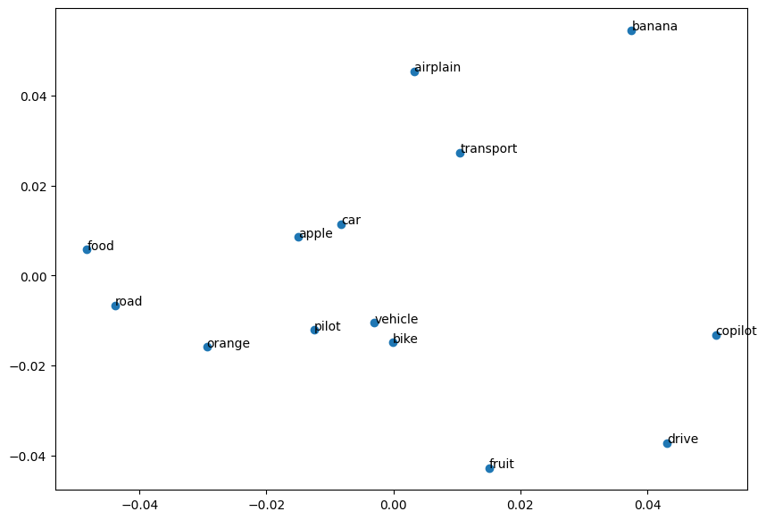

```python
from gensim.models import Word2Vec
from sklearn.decomposition import PCA
import matplotlib.pyplot as plt

sentences = [
    ["apple", "orange", "banana", "fruit" , "airplain " , "pilot"],
    ["car", "bike", "vehicle", "transport" , "copilot"],
    ["apple", "banana", "fruit", "food"],
    ["bike", "car", "drive", "road"],
]

model = Word2Vec(sentences, vector_size=50, window=5, min_count=1, workers=2)

word = "apple"
vector = model.wv[word]

print(f"Dense vector for '{word}':\n{vector}")

words = list(model.wv.key_to_index)
vectors = [model.wv[word] for word in words]



pca = PCA(n_components=2)
result = pca.fit_transform(vectors)

print(result.shape)

plt.figure(figsize=(10, 7))
plt.scatter(result[:, 0], result[:, 1])

for i, word in enumerate(words):
    plt.annotate(word, xy=(result[i, 0], result[i, 1]))

plt.show()
```

### Latent Dirichlet Allocation (LDA)

Latent Dirichlet Allocation (LDA) is a generative probabilistic model used for discovering the underlying topics in a collection of documents. It is widely used in natural language processing (NLP) and text mining to uncover hidden thematic structures in a large corpus. Here’s a detailed explanation:

### How LDA Works

1. **Assumptions**:
   - Each document is a mixture of topics.
   - Each topic is a mixture of words.
   - The distribution of topics in a document and the distribution of words in a topic follow a Dirichlet distribution.
2. **Model Components**:
   - **Topics**: Probability distributions over a fixed vocabulary. Each topic is characterized by a distribution over words.
   - **Documents**: Probability distributions over topics. Each document is a mixture of multiple topics.
3. **Generative Process**:
   - For each document in the corpus:
     1. Choose a distribution over topics (using a Dirichlet distribution).
     2. For each word in the document:
        - Choose a topic from the topic distribution.
        - Choose a word from the selected topic's word distribution.

### Mathematical Representation

- **α (alpha)**: Parameter of the Dirichlet prior on the per-document topic distributions.
- **β (beta)**: Parameter of the Dirichlet prior on the per-topic word distributions.
- **θ (theta)**: Per-document topic distribution.
- **φ (phi)**: Per-topic word distribution.
- **z**: Topic assignment for each word.
- **w**: Observed words.

The generative process can be summarized as:

1. For each document ( d ):
   - Draw topic proportions ( \theta_d \sim \text{Dir}(\alpha) ).
   - For each word ( w_{dn} ) in document ( d ):
     - Draw a topic ( z_{dn} \sim \text{Multinomial}(\theta_d) ).
     - Draw a word ( w*{dn} ) from the topic ( z*{dn} ), i.e., ( w*{dn} \sim \text{Multinomial}(\phi*{z_{dn}}) ).

### Advantages of LDA

- **Topic Discovery**: LDA can uncover hidden topics in a large corpus, which can be useful for organizing, summarizing, and understanding large collections of text.
- **Scalability**: LDA is scalable and can handle large datasets efficiently.
- **Interpretable Results**: The topics discovered by LDA are easily interpretable, which is valuable for many applications in NLP and text mining.

### Limitations of LDA

- **Assumption of Dirichlet Distributions**: The assumption that document-topic and topic-word distributions follow a Dirichlet distribution might not hold in all cases.
- **Fixed Number of Topics**: The number of topics ( K ) must be specified a priori, which may not always be known.
- **Bag-of-Words Model**: LDA operates on the bag-of-words model, ignoring the order of words within documents, which can lead to loss of contextual information.

```python
import gensim
from gensim import corpora
from gensim.models.ldamodel import LdaModel

documents = [
    "apple orange banana fruit",
    "car bike vehicle transport",
    "apple banana fruit food",
    "bike car drive road",
    "pilot airplane copilot",
]

texts = [doc.split() for doc in documents]

dictionary = corpora.Dictionary(texts)

corpus = [dictionary.doc2bow(text) for text in texts]

lda_model = LdaModel(corpus, num_topics=3, id2word=dictionary, passes=10)

topics = lda_model.print_topics(num_words=4)
for topic in topics:
    print(topic)
```

```
(0, '0.141*"banana" + 0.141*"fruit" + 0.141*"apple" + 0.081*"orange"')
(1, '0.173*"airplane" + 0.173*"pilot" + 0.173*"copilot" + 0.044*"car"')
(2, '0.159*"bike" + 0.158*"car" + 0.151*"drive" + 0.151*"road"')
```

### Non-Negative Matrix Factorization (NMF)

Non-Negative Matrix Factorization (NMF) is a matrix factorization technique used to reduce the dimensions of data, uncover latent structures, and extract meaningful features from non-negative data. It is particularly useful in applications such as text mining, image processing, and recommendation systems.

### How NMF Works

1. **Objective**:
   - Given a non-negative matrix ( V ) (e.g., a term-document matrix in text mining), NMF aims to factorize it into two non-negative matrices: ( W ) and ( H ), such that ( V \approx WH ).
   - Here, ( V ) is of size ( m \times n ), ( W ) is of size ( m \times k ), and ( H ) is of size ( k \times n ), where ( k ) is the number of latent features (topics).
2. **Mathematical Formulation**:
   - ( V \approx WH )
   - ( W ) (basis matrix) contains the latent features, with each row representing a basis vector.
   - ( H ) (coefficient matrix) contains the coefficients, with each column representing how much each basis vector contributes to reconstructing the original data.
3. **Optimization**:
   - NMF minimizes the reconstruction error, typically measured by the Frobenius norm: [ \min_{W, H} | V - WH |_F^2 ]
   - This is done subject to the constraints that ( W \geq 0 ) and ( H \geq 0 ), meaning all elements in ( W ) and ( H ) must be non-negative.
4. **Algorithm**:
   - NMF algorithms iteratively update ( W ) and ( H ) to minimize the reconstruction error. Popular algorithms include multiplicative update rules and coordinate descent methods.

### Advantages of NMF

- **Interpretability**: The non-negativity constraint leads to more interpretable factors compared to other factorization techniques, such as PCA. For example, in text mining, topics are represented by additive combinations of words.
- **Sparse Representations**: NMF often results in sparse factors, meaning that most elements in ( W ) and ( H ) are zero, which can lead to more efficient storage and computation.
- **Applications**: NMF is widely used in various fields, including topic modeling, image processing, and collaborative filtering.

### Limitations of NMF

- **Local Minima**: The optimization process can converge to local minima, which might not be the global optimum.
- **Scalability**: NMF can be computationally intensive, especially for large datasets.
- **Parameter Tuning**: The number of latent features ( k ) must be chosen carefully, often requiring domain knowledge or cross-validation.

### Applications of NMF

1. **Text Mining**:
   - NMF can be used for topic modeling, where documents are represented as combinations of topics, and topics are combinations of words.
2. **Image Processing**:
   - NMF can decompose images into a set of basis images and coefficients, useful for tasks such as image compression and feature extraction.
3. **Recommendation Systems**:
   - NMF can be used to predict user preferences by decomposing user-item interaction matrices.

```python
import numpy as np
from sklearn.decomposition import NMF
from sklearn.feature_extraction.text import TfidfVectorizer

documents = [
    "apple orange banana fruit",
    "car bike vehicle transport",
    "apple banana fruit food",
    "bike car drive road",
    "pilot airplane copilot",
]

vectorizer = TfidfVectorizer()
X = vectorizer.fit_transform(documents)

n_components = 3
nmf = NMF(n_components=n_components, random_state=42)
W = nmf.fit_transform(X)
H = nmf.components_

feature_names = vectorizer.get_feature_names_out()
for topic_idx, topic in enumerate(H):
    print(f"Topic #{topic_idx + 1}:")
    print(" ".join([feature_names[i] for i in topic.argsort()[:-5 - 1:-1]]))

print("\\nDocument-Topic Matrix:")
print(W)
```

```
Topic #1:
fruit banana apple food orange
Topic #2:
bike car vehicle transport road
Topic #3:
pilot copilot airplane road transport
\nDocument-Topic Matrix:
[[0.57002042 0.         0.        ]
 [0.         0.60807329 0.        ]
 [0.57002042 0.         0.        ]
 [0.         0.60807329 0.        ]
 [0.         0.         0.82589808]]
```

# Deep Learning-Based Methods in Natural Language Processing (NLP)

Deep learning-based methods have revolutionized natural language processing (NLP) by enabling the development of models that can automatically learn complex patterns and representations from large datasets. These methods leverage deep neural networks to perform a wide range of NLP tasks, such as text classification, sentiment analysis, machine translation, and more. Below are some key deep learning-based methods and their applications:

### 1. Recurrent Neural Networks (RNNs)

- **Overview**: RNNs are designed to handle sequential data by maintaining a hidden state that captures information about previous elements in the sequence. They are particularly useful for tasks involving time series or language data.
- **Applications**: Language modeling, text generation, machine translation, and speech recognition.
- **Limitations**: RNNs struggle with long-term dependencies due to issues like vanishing and exploding gradients.

### 2. Long Short-Term Memory Networks (LSTMs) and Gated Recurrent Units (GRUs)

- **Overview**: LSTMs and GRUs are advanced types of RNNs that address the limitations of traditional RNNs by using gating mechanisms to control the flow of information.
- **Applications**: Similar to RNNs but with better performance on tasks requiring the modeling of long-range dependencies.
- **Advantages**: LSTMs and GRUs can capture long-term dependencies more effectively than standard RNNs.

### 3. Convolutional Neural Networks (CNNs)

- **Overview**: While CNNs are typically used for image processing, they can also be applied to text data by treating text as a sequence of "pixels" or by using embeddings.
- **Applications**: Text classification, sentiment analysis, and text summarization.
- **Advantages**: CNNs are efficient at capturing local patterns and hierarchical features in text.

### 4. Word Embeddings

- **Overview**: Word embeddings are dense vector representations of words that capture semantic relationships. Popular methods include Word2Vec, GloVe, and FastText.
- **Applications**: Text classification, named entity recognition, and machine translation.
- **Advantages**: Word embeddings provide a meaningful representation of words that can be used as input to deep learning models.

### 5. Sequence-to-Sequence (Seq2Seq) Models

- **Overview**: Seq2Seq models consist of an encoder-decoder architecture, often with attention mechanisms, designed for tasks where the input and output are sequences of different lengths.
- **Applications**: Machine translation, text summarization, and question answering.
- **Advantages**: Seq2Seq models can handle variable-length input and output sequences, making them versatile for many NLP tasks.

### 6. Attention Mechanisms and Transformers

- **Overview**: Attention mechanisms allow models to focus on different parts of the input sequence when making predictions. Transformers, introduced by Vaswani et al. in 2017, rely solely on attention mechanisms, eliminating the need for recurrence.
- **Applications**: Machine translation, text summarization, and language modeling.
- **Advantages**: Transformers are highly parallelizable and can capture long-range dependencies more effectively than RNNs and LSTMs.

### 7. Pretrained Language Models

- **Overview**: Pretrained language models, such as BERT, GPT, and T5, are trained on large corpora and fine-tuned for specific tasks. They have set new benchmarks in many NLP tasks.
- **Applications**: Text classification, named entity recognition, question answering, and more.
- **Advantages**: These models leverage transfer learning, providing state-of-the-art performance across a wide range of NLP tasks with relatively little task-specific data.

# 1. Recurrent Neural Networks (RNNs)

Recurrent Neural Networks (RNNs) are a class of artificial neural networks designed for processing sequential data. Unlike traditional feedforward neural networks, RNNs have connections that form directed cycles, allowing information to persist. This characteristic makes RNNs particularly suitable for tasks where the order of the input data is important, such as time series prediction, natural language processing, and speech recognition.

#### How RNNs Work

1. **Sequential Processing**:
   - RNNs process input sequences one element at a time, maintaining a hidden state that captures information about previous elements in the sequence.
2. **Hidden State**:
   - At each time step ( t ), the hidden state ( h_t ) is updated based on the current input ( x*t ) and the previous hidden state ( h*{t-1} ).
   - The hidden state acts as a memory that captures the history of the sequence up to the current time step.
3. **Mathematical Formulation**:
   - The hidden state ( h_t ) at time step ( t ) is computed using specific weight matrices for the hidden state and the input, and a bias term, processed through an activation function such as tanh or ReLU.
   - The output ( y_t ) at time step ( t ) is generated by applying another activation function, often softmax for classification, to the product of the hidden state and another set of weights and biases.

#### Applications of RNNs

1. **Language Modeling**:
   - Predicting the next word in a sentence based on the previous words.
   - Applications include text generation and autocomplete features.
2. **Machine Translation**:
   - Translating sentences from one language to another by processing input sentences sequentially.
   - Commonly used in tools like Google Translate.
3. **Speech Recognition**:
   - Converting spoken language into text by processing audio signals as sequences.
   - Used in voice assistants and transcription services.
4. **Time Series Prediction**:
   - Predicting future values in a sequence based on past observations.
   - Useful in fields like stock market prediction and weather forecasting.

#### Limitations of RNNs

1. **Vanishing and Exploding Gradients**:
   - During training, gradients can become very small (vanishing) or very large (exploding), which complicates learning long-term dependencies.
2. **Short-Term Memory**:
   - Standard RNNs struggle with long-term dependencies due to their tendency to forget information as sequences grow longer.
3. **Computationally Intensive**:
   - Training RNNs can be slow and computationally expensive, especially for long sequences.

#### Improvements and Variants

To address the limitations of standard RNNs, several variants have been developed:

1. **Long Short-Term Memory Networks (LSTMs)**:
   - Incorporate gating mechanisms to control the flow of information, enhancing their ability to capture long-term dependencies.
2. **Gated Recurrent Units (GRUs)**:
   - Offer a similar capability to LSTMs but with a simplified architecture, making them computationally more efficient.
3. **Bidirectional RNNs**:
   - Process the input sequence in both forward and backward directions, providing additional context and improving the accuracy of the predictions.

Recurrent Neural Networks (RNNs) are powerful tools for modeling sequential data, making them suitable for a wide range of applications in natural language processing, time series prediction, and more. Despite their limitations, improvements like LSTMs, GRUs, and bidirectional RNNs have enhanced their ability to capture long-term dependencies and process complex sequences.

```python
import torch
import torch.nn as nn
import torch.optim as optim

class RNNModel(nn.Module):
    def __init__(self, input_size, hidden_size, output_size, num_layers=1):
        super(RNNModel, self).__init__()
        self.hidden_size = hidden_size
        self.num_layers = num_layers
        self.rnn = nn.RNN(input_size, hidden_size, num_layers, batch_first=True)
        self.fc = nn.Linear(hidden_size, output_size)

    def forward(self, x):
        h0 = torch.zeros(self.num_layers, x.size(0), self.hidden_size).to(x.device)

        out, _ = self.rnn(x, h0)

        out = self.fc(out[:, -1, :])
        return out

input_size = 10
hidden_size = 20
output_size = 2
num_layers = 1
learning_rate = 0.001
num_epochs = 5

model = RNNModel(input_size, hidden_size, output_size, num_layers)

criterion = nn.CrossEntropyLoss()
optimizer = optim.Adam(model.parameters(), lr=learning_rate)

inputs = torch.randn(32, 5, input_size)
targets = torch.randint(0, 2, (32,))

for epoch in range(num_epochs):
    outputs = model(inputs)
    loss = criterion(outputs, targets)
    optimizer.zero_grad()
    loss.backward()
    optimizer.step()

    if (epoch + 1) % 1 == 0:
        print(f'Epoch [{epoch+1}/{num_epochs}], Loss: {loss.item():.4f}')
```

```
Epoch [1/5], Loss: 0.7068
Epoch [2/5], Loss: 0.7017
Epoch [3/5], Loss: 0.6966
Epoch [4/5], Loss: 0.6917
Epoch [5/5], Loss: 0.6868
```

### Long Short-Term Memory Networks (LSTMs) and Gated Recurrent Units (GRUs)

Long Short-Term Memory (LSTM) networks and Gated Recurrent Units (GRUs) are advanced types of Recurrent Neural Networks (RNNs) designed to address the limitations of standard RNNs, particularly the issues of vanishing and exploding gradients, and difficulty in capturing long-term dependencies in sequential data.

#### Long Short-Term Memory Networks (LSTMs)

**Overview**:

- LSTMs are a type of RNN that introduces gating mechanisms to control the flow of information, allowing them to maintain long-term dependencies more effectively.
- They were introduced by Hochreiter and Schmidhuber in 1997.

**Architecture**:

- LSTMs have a more complex structure than standard RNNs, with each LSTM cell containing three gates: the input gate, the forget gate, and the output gate.
- These gates regulate the information that is added to, removed from, and read from the cell state.

**Gates**:

1. **Input Gate**: Decides how much of the new information from the current input should be added to the cell state.
2. **Forget Gate**: Decides how much of the existing information in the cell state should be retained.
3. **Output Gate**: Decides how much of the cell state should be output to the next hidden state.

**Mathematical Formulation**:

- The equations governing an LSTM cell at time step ( t ) are: $$ f_t = \sigma(W_f \cdot [h_{t-1}, x_t] + b_f) $$ $$ i_t = \sigma(W_i \cdot [h_{t-1}, x_t] + b_i) $$ $$ o_t = \sigma(W_o \cdot [h_{t-1}, x_t] + b_o) $$ $$ \tilde{C}_t = \tanh(W_C \cdot [h_{t-1}, x_t] + b_C) $$ $$ C_t = f_t * C_{t-1} + i_t * \tilde{C}_t $$ $$ h_t = o_t * \tanh(C_t) $$ where sigma is the sigmoid function, tanh is the hyperbolic tangent function, W are the weight matrices, b are the biases, h is the hidden state, and C is the cell state.

**Advantages**:

- **Captures Long-Term Dependencies**: Effectively retains information over long sequences.
- **Solves Vanishing/Exploding Gradient Problem**: Through gating mechanisms, LSTMs can learn and remember over long sequences without the gradient issues faced by standard RNNs.

**Applications**:

- Time series forecasting, machine translation, speech recognition, text generation, and more.

#### Gated Recurrent Units (GRUs)

**Overview**:

- GRUs are a simplified version of LSTMs, introduced by Cho et al. in 2014.
- They combine the forget and input gates into a single update gate, simplifying the architecture while retaining similar performance.

**Architecture**:

- GRUs have two gates: the update gate and the reset gate.

**Gates**:

1. **Update Gate**: Decides how much of the past information needs to be passed along to the future.
2. **Reset Gate**: Decides how much of the past information to forget.

**Mathematical Formulation**:

- The equations governing a GRU cell at time step ( t ) are: $$ z_t = \sigma(W_z \cdot [h_{t-1}, x_t] + b_z) $$ $$ r_t = \sigma(W_r \cdot [h_{t-1}, x_t] + b_r) $$ $$ \tilde{h}_t = \tanh(W \cdot [r_t * h_{t-1}, x_t] + b) $$ $$ h_t = z_t * h_{t-1} + (1 - z_t) * \tilde{h}_t $$ where ( \sigma ) is the sigmoid function, ( \tanh ) is the hyperbolic tangent function, ( W ) are the weight matrices, ( b ) are the biases, ( h ) is the hidden state, and ( z_t ) and ( r_t ) are the update and reset gates, respectively.

**Advantages**:

- **Simpler Architecture**: Fewer parameters and simpler structure compared to LSTMs.
- **Efficient Training**: Often trains faster and can achieve similar performance to LSTMs.

**Applications**:

- Similar to LSTMs: time series forecasting, machine translation, speech recognition, text generation, etc.

LSTMs and GRUs are powerful variants of RNNs that effectively address the limitations of standard RNNs. By incorporating gating mechanisms, they can capture long-term dependencies in sequential data, making them highly suitable for tasks such as time series forecasting, machine translation, speech recognition, and more. Their ability to handle complex patterns in sequential data has made them essential tools in the field of deep learning.

```python
import torch
import torch.nn as nn
import torch.optim as optim

class GRUModel(nn.Module):
    def __init__(self, input_size, hidden_size, output_size, num_layers=1):
        super(GRUModel, self).__init__()
        self.hidden_size = hidden_size
        self.num_layers = num_layers
        self.gru = nn.GRU(input_size, hidden_size, num_layers, batch_first=True)
        self.fc = nn.Linear(hidden_size, output_size)

    def forward(self, x):
        h0 = torch.zeros(self.num_layers, x.size(0), self.hidden_size).to(x.device)
        out, _ = self.gru(x, h0)
        out = self.fc(out[:, -1, :])
        return out

input_size = 10
hidden_size = 20
output_size = 2
num_layers = 1
learning_rate = 0.001
num_epochs = 5

model = GRUModel(input_size, hidden_size, output_size, num_layers)

criterion = nn.CrossEntropyLoss()
optimizer = optim.Adam(model.parameters(), lr=learning_rate)

inputs = torch.randn(32, 5, input_size)
targets = torch.randint(0, 2, (32,))

for epoch in range(num_epochs):
    outputs = model(inputs)
    loss = criterion(outputs, targets)

    optimizer.zero_grad()
    loss.backward()
    optimizer.step()

    if (epoch + 1) % 1 == 0:
        print(f'Epoch [{epoch+1}/{num_epochs}], Loss: {loss.item():.4f}')
```

```
Epoch [1/5], Loss: 0.7225
Epoch [2/5], Loss: 0.7196
Epoch [3/5], Loss: 0.7168
Epoch [4/5], Loss: 0.7139
Epoch [5/5], Loss: 0.7111
```

# Description of the Project

In this project, you will work with text data, starting with preprocessing tasks and then moving on to using the Word2Vec model for embedding sentences. The project is divided into four main parts:

#### Part 1: Text Data Preprocessing

- **Objective**: Clean and preprocess text data to prepare it for embedding and subsequent neural network processing.
- **Tasks**:
  - Convert text to lowercase.
  - Remove punctuation, numbers, and links.
  - Remove references to other users and emojis.
  - Normalize white spaces.
  - Tokenize and lemmatize the text.
  - Remove stop words.
  - Output a list of processed tokens for each text input.

#### Part 2: Using Word2Vec Model

- **Objective**: Learn how to use the Word2Vec model to convert text into numerical vectors (word embeddings).
- **Tasks**:
  - Train a Word2Vec model on the preprocessed text data or use a pretrained Word2Vec model.
  - Convert sentences into vectors by averaging the Word2Vec vectors of their constituent words.
  - Prepare the sentences for input into a convolutional neural network (CNN).

#### Part 3: Text Classification with Convolutional Neural Networks (CNNs)

- **Objective**: Implement a CNN using the PyTorch library for text classification tasks.
- **Tasks**:
  - Define and train a CNN model on the word embeddings of the sentences.
  - Evaluate the performance of the CNN model on a test dataset.
  - Observe the effect of different context window sizes on the learning and performance of the model.

#### Part 4: Effect of Regularization Methods in Training

- **Objective**: Analyze the impact of various regularization techniques on the training process and model performance.
- **Tasks**:
  - Implement regularization methods such as Dropout and Batch Normalization in the CNN.
  - Train the model with these regularization methods and compare the results with the non-regularized model.
  - Assess the improvement in model generalization and performance due to regularization.

### Tools and Environment

- **Google Colab**: Utilize Google Colab for running your code, leveraging its cloud-based GPU resources for faster training of deep learning models.
- **PyTorch**: Use the PyTorch library for implementing the CNN model and training it on the word embeddings.
- **Word2Vec**: Use the Word2Vec model from the Gensim library to generate word embeddings from the text data.

### Hardware Recommendations

- **GPU Usage**: Since training deep learning models, especially CNNs, can be computationally intensive, it is recommended to use GPU acceleration provided by Google Colab. Set the runtime type to GPU in Google Colab for efficient training.
- **Local GPU Setup**: If you have a supported GPU on your local machine, you can use CUDA and cuDNN to accelerate the training process. Be aware of potential setup complexities and limitations.

### Steps Overview

1. **Preprocess the Text Data**: Clean the text data by removing unnecessary elements and normalizing the text.
2. **Generate Word Embeddings**: Use the Word2Vec model to convert text into numerical vectors.
3. **Build and Train CNN**: Implement a CNN using PyTorch for text classification tasks and train it on the word embeddings.
4. **Analyze Regularization Effects**: Apply regularization techniques and compare their effects on the model’s performance.

### Conclusion

By the end of this project, you will have hands-on experience in preprocessing text data, using Word2Vec for word embeddings, building and training a CNN for text classification, and understanding the importance and impact of regularization methods in deep learning. This project will enhance your skills in natural language processing and deep learning using Python and its powerful libraries.

### Dataset Introduction

The dataset used in this project is a text dataset aimed at detecting suicidal thoughts on social media platforms. This dataset, referred to as "twitter-suicidal-data," consists of Twitter posts labeled to indicate whether they contain suicidal thoughts or not. Each tweet in the dataset is presented as a text snippet, and each tweet is labeled with an intention value: 1 for suicidal thoughts and 0 for non-suicidal content.

#### Importance and Relevance

This dataset, and similar datasets in the field of natural language processing (NLP) and deep learning, play a crucial role in addressing an important social issue: suicide prevention. Suicidal thoughts are a growing concern, and early detection can be a crucial step in preventing suicide attempts. Social media platforms like Twitter have become essential channels for people to express their feelings and thoughts. This means that social media can provide valuable insights into individuals' mental health.

#### Challenges with Social Media Data

Text data extracted from social media, such as the dataset in question, is characterized by its noisy and unstructured nature. These posts often contain abbreviations, colloquial language, and informal writing styles, which can make the analysis and extraction of meaningful information challenging. Additionally, social media posts are often short, which can make it difficult to identify clear patterns or indicators of suicidal thoughts.

#### Objectives

In this project, we aim to leverage the power of Convolutional Neural Networks (CNNs) to overcome these challenges. The steps involved include:

1. **Preprocessing Text Data**:
   - Clean the text data to remove noise and normalize the text.
   - Tokenize and prepare the text for embedding.
2. **Using Word2Vec for Embedding**:
   - Convert the preprocessed text into numerical vectors using the Word2Vec model.
3. **Building a CNN for Text Classification**:
   - Implement and train a CNN using PyTorch to classify the tweets based on the presence of suicidal thoughts.
4. **Analyzing the Impact of Context Window Size**:
   - Observe how different context window sizes affect the learning and performance of the model.
5. **Evaluating Regularization Techniques**:
   - Apply regularization methods to improve the generalization and performance of the CNN model.

#### Tools and Environment

- **Google Colab**: Utilize Google Colab for running the code and leveraging its GPU resources for faster training of deep learning models.
- **PyTorch**: Use the PyTorch library to implement and train the CNN model.
- **Word2Vec**: Use the Word2Vec model from the Gensim library for generating word embeddings from the text data.

#### Practical Considerations

- **GPU Usage**: Training deep learning models, particularly CNNs, is computationally intensive. Using GPU acceleration provided by Google Colab is recommended for efficient training. Set the runtime type to GPU in Google Colab.
- **Local GPU Setup**: If you have a supported GPU on your local machine, you can use CUDA and cuDNN to accelerate the training process. Be aware of potential setup complexities and limitations.

### Data Preprocessing Steps for Social Media Text Data

Text data extracted from social media, such as tweets, often contains noise, abbreviations, colloquial language, and other informal writing styles. To ensure that our deep learning models can effectively process this data, it is essential to perform thorough preprocessing. Below are the steps to clean and preprocess the text data:

#### Steps for Text Preprocessing

```python
!pip install emoji
```

```
     ━━━━━━━━━━━━━━━━━━━━━━━━━━━━━━━━━━━━━━━━ 431.4/431.4 kB 5.4 MB/s eta 0:00:00
```

```python
from google.colab import drive
drive.mount('/content/drive')
```

```python
import re
import string
import emoji
from nltk.corpus import stopwords
from nltk.tokenize import word_tokenize
from nltk.stem import WordNetLemmatizer

import nltk
nltk.download('punkt')
nltk.download('stopwords')
nltk.download('wordnet')

lemmatizer = WordNetLemmatizer()
stop_words = set(stopwords.words('english'))

def preprocess_data(text):
    text = text.lower()
    text = text.translate(str.maketrans('', '', string.punctuation))
    text = re.sub(r'\\d+', '', text)
    text = re.sub(r'http\\S+|www\\S+|https\\S+', '', text, flags=re.MULTILINE)
    text = re.sub(r'@\\w+', '', text)
    text = emoji.demojize(text)
    text = re.sub(r'\\s+', ' ', text).strip()
    tokens = word_tokenize(text)

    tokens = [lemmatizer.lemmatize(token) for token in tokens if token.isalpha() and token not in stop_words]

    return tokens

sample_tweet = "@user I love programming! Visit <https://example.com> for more details. 😊 #coding #Python"
processed_tokens = preprocess_data(sample_tweet)
print(processed_tokens)
```

```
['user', 'love', 'programming', 'visit', 'httpsexamplecom', 'detail', 'coding', 'python']
```

## Question :

**Advantages of Converting Text to Lowercase:**

1. **Consistency**: Lowercasing text ensures that the same words in different cases (like "Apple," "apple," or "APPLE") are treated as the same word, which is crucial for most natural language processing (NLP) tasks.
2. **Simplification**: It reduces the complexity of the text data by minimizing the number of unique tokens the model needs to understand and process. This can lead to more straightforward models and faster processing.
3. **Improved Matching**: It helps in achieving better matches in search and indexing operations because variations in capitalization do not affect the search results.

**Disadvantages of Converting Text to Lowercase:**

1. **Loss of Information**: Certain words or entities might lose their significance or meaning when converted to lowercase. For example, "US" (referring to the United States) might be confused with "us" (the pronoun).
2. **Ambiguity**: Lowercasing can introduce ambiguity. Words like "May" (the month) and "may" (the modal verb) become indistinguishable when converted to lowercase.
3. **Contextual Meaning Changes**: In some contexts, the capitalization of words can indicate emphasis or importance, which is lost when text is transformed to all lowercase.

In some Natural Language Processing (NLP) applications, removing numbers from text may be carried out for various reasons. Here, we'll explore the advantages and disadvantages of this processing approach:

### Advantages of Removing Numbers:

1. **Reducing Data Complexity**: Removing numbers can simplify the feature space and reduce the diversity in the data, which might simplify machine learning models.
2. **Focus on Textual Content**: In cases where the overall meaning of a text is more crucial than precise details, removing numbers helps focus on the linguistic elements rather than quantitative data, which may not be relevant.
3. **Noise Reduction**: In some text analyses, numbers might be considered noise—especially if they do not contribute to the objective of the analysis, such as sentiment analysis or certain types of classification tasks.

### Disadvantages of Removing Numbers:

1. **Loss of Information**: Numbers can contain vital information (e.g., dates, quantities, identifiers). Removing them might strip the text of important context or factual content that could be crucial for tasks like event extraction or financial analysis.
2. **Reduced Accuracy in Specific Contexts**: For tasks that rely on quantitative data or specific details (like scientific articles, technical documents, or financial reports), removing numbers could lead to less accurate outcomes.
3. **Ambiguity**: Numbers can help disambiguate text (e.g., "Apple 12" could refer to a product model rather than the fruit). Removing numbers might increase ambiguity.

### Why Perform This Processing?

The primary rationale for removing numbers from text in certain NLP tasks is to standardize inputs and reduce variability, especially when the presence of numeric data could skew or misdirect the analytical focus. This process is often beneficial in improving the performance of models focused on understanding and generating textual content where numbers do not play a crucial role. However, the decision to remove numbers should be carefully considered based on the specific requirements and goals of the NLP task at hand.

### Why Keep Hashtags?

1. **Context and Relevance**: Hashtags often encapsulate key themes or topics of a tweet and can provide context that helps the model understand the relevance or categorization of the content.
2. **Improved Feature Extraction**: Hashtags can serve as strong indicators for sentiment analysis, trend detection, or topic modeling. They are concise and tend to contain condensed information about the post, which can be highly valuable for training more effective models.
3. **Enhanced Data Categorization**: In tasks like supervised learning, hashtags can act as built-in labels or tags that assist in more accurately categorizing and training on text data.
4. **Signal for Important Keywords**: Hashtags often highlight what the user considers important or trending, which could be crucial for models to capture user engagement and interests.

### Impact on Model Performance

- **Increased Accuracy**: By including hashtags as part of the text input, models may achieve higher accuracy in tasks such as sentiment analysis, as hashtags often reflect sentiment (e.g., #happy, #fail).
- **Better Generalization**: Training data that include diverse hashtags can help the model generalize better to new, unseen data, particularly data from social media platforms where hashtags are prevalent.
- **Richer Semantic Understanding**: Models trained with hashtags may develop a richer semantic understanding of text by associating hashtags with their broader context within the tweet or across similar tweets.

In summary, retaining hashtags in training datasets for NLP tasks leverages their encapsulated metadata, enhancing model understanding of social media texts and improving performance on various analytical tasks.

## Methods for Handling Out-of-Vocabulary (OOV) Words:

1. **Zero Vector Representation:**
   - **Method**: Assign a zero vector (all elements are zero) of the same dimension as the existing word vectors (e.g., 300 for Word2Vec).
   - **Advantages**: Simple and ensures consistent handling of OOV words without altering the dimensionality of the feature space.
   - **Disadvantages**: Provides no information about the word, potentially losing important context and negatively affecting the model's performance.
2. **Random Vector Representation:**
   - **Method**: Assign a random vector for each OOV word.
   - **Advantages**: Introduces a unique representation for each OOV word, possibly capturing some level of uniqueness between different OOV words.
   - **Disadvantages**: Randomness does not provide meaningful semantic information, and the inconsistency can disrupt the model's learning patterns.
3. **Embedding Special Tokens for OOV:**
   - **Method**: Use a special pre-trained vector to represent all OOV words, distinct from zero vectors.
   - **Advantages**: Provides a consistent approach that differs from zero vectors, potentially allowing the model to learn a special context for OOV words.
   - **Disadvantages**: Still does not convey the actual semantic meaning of the OOV words but performs better than zero vectors in terms of handling unknown tokens.
4. **Subword Tokenization:**
   - **Method**: Use models like FastText which utilize subword information (n-grams of words) to handle OOV by aggregating subword vectors.
   - **Advantages**: Captures more semantic meaning from OOV words by leveraging the information from known subwords, improving model robustness.
   - **Disadvantages**: More complex and may introduce noise if subwords are not meaningful or too granular.
5. **Character-Level Embeddings:**
   - **Method**: Use neural networks to learn embeddings for each character and combine them to form word embeddings, thus handling any word, known or unknown.
   - **Advantages**: Extremely flexible and capable of generating embeddings for any word, regardless of its presence in the training data.
   - **Disadvantages**: Computationally intensive and may result in less meaningful embeddings for words well-represented by word-level embeddings.

Each method has its trade-offs between simplicity, computational efficiency, and the ability to capture semantic meaning. The choice of method depends on the specific requirements of the NLP task and the characteristics of the data.

```python
import pandas as pd
import matplotlib.pyplot as plt
import seaborn as sns



df = pd.read_csv("/content/drive/MyDrive/twitter-suicidal-data.csv")

sample_texts = df['tweet'].sample(10)
for text in sample_texts:
    processed = preprocess_data(text)
    print(f"Original: {''.join(text)}\nProcessed: {' '.join(processed)}\n")
```

```
Original: i thought it was you
Processed: thought

Original: my sister doesn t know who paul rudd is
Processed: sister know paul rudd

Original: wishing my knee was fixed so i could go snowboarding
Processed: wishing knee fixed could go snowboarding

Original: last day before vacation hip hip hooray hip hip hoorayalarm didn t go off this morning making me unproductive before a very buys day
Processed: last day vacation hip hip hooray hip hip hoorayalarm go morning making unproductive buy day

Original: want to die nearly 29 never had a gf western women have all rejected me stuck studying nursing even though i hate it researching how to end it considering hanging as a option if i can get the technique down right why arent i allowed to kill myself over never having a gf it will never happe…
Processed: want die nearly never gf western woman rejected stuck studying nursing even though hate researching end considering hanging option get technique right arent allowed kill never gf never happen going spend life working support society fucked beta male like tax dollar drone

Original:  clean me
Processed: clean

Original: off to the audubon center and sanctuarywalkin the trails feel better ashton kutcher
Processed: audubon center sanctuarywalkin trail feel better ashton kutcher

Original: amjust tiredi am tired of pretendingi amhappy every dayi am tired of trying to be friends with flakey people who only care about having the most exciting time possible rather than experiencing actual human connectioni am tired of going on endless first dates only to be ghosted immediately …
Processed: amjust tiredi tired pretendingi amhappy every dayi tired trying friend flakey people care exciting time possible rather experiencing actual human connectioni tired going endless first date ghosted immediately afteri tired putting countless hour work thatll amount nothing wheni amgonei tir…

Original:  at riot room waiting for the hot wife of fohp s guitar player
Processed: riot room waiting hot wife fohp guitar player

Original: right now i wish i had a decent desktop
Processed: right wish decent desktop
```

# Creating Feature Vectors for Neural Network Input

To feed input into a neural network, each input text needs to be converted into a numerical vector. In this section, we will load the given Word2Vec model, which contains a dictionary mapping each word to a 300-dimensional numerical vector. We will then construct a feature vector for each input sentence using concatenation. This method is preferred over other methods like aggregation for this project. The steps and considerations for this process are detailed below.

#### Steps to Create Feature Vectors

1. **Load the Word2Vec Model**:
   - Load the pre-trained Word2Vec model that provides a 300-dimensional vector for each word.
2. **Define the Matrix Size**:
   - Each sentence will be represented as a 2D matrix.
   - The matrix dimensions must be consistent for all inputs. It's recommended to use 64 tokens per sentence as a standard size.
3. **Populate the Matrix**:
   - For each token in a sentence, insert the corresponding Word2Vec vector into the matrix.
   - If a token does not exist in the Word2Vec dictionary, insert a zero vector of size (300 \times 1).

#### Detailed Steps

1. **Loading the Word2Vec Model**:
   - The model is loaded to access the pre-trained word embeddings.
   - Each word is mapped to a 300-dimensional vector.
2. **Defining the Matrix Size**:
   - The matrix for each sentence should have a fixed number of rows (e.g., 64 tokens).
   - Each row corresponds to a word vector of size 300.
3. **Constructing the Matrix**:
   - For each token in the sentence, look up the corresponding vector in the Word2Vec model.
   - If a token is not found, use a zero vector.
   - Concatenate these vectors to form a 64 x 300 matrix.

### Methods for Handling Unknown Words

When a word in the input sentence is not found in the Word2Vec dictionary, there are several strategies to handle this:

1. **Using a Zero Vector**:
   - Insert a vector of zeros in place of the missing word vector.
   - **Advantages**: Simple to implement; avoids introducing noise.
   - **Disadvantages**: The zero vector may reduce the expressiveness of the sentence representation.
2. **Using an Average Vector**:
   - Insert the average of all word vectors from the dictionary.
   - **Advantages**: Provides a neutral representation that can be more informative than a zero vector.
   - **Disadvantages**: The average vector might still dilute the specific meaning of the sentence.
3. **Using a Random Vector**:
   - Insert a randomly generated vector.
   - **Advantages**: Introduces variability which can sometimes help in learning.
   - **Disadvantages**: Adds randomness and noise, which might not be beneficial for all models.
4. **Using a Predefined 'Unknown' Token Vector**:
   - Insert a predefined vector that represents an unknown token.
   - **Advantages**: Consistent treatment of unknown tokens; can be trained to represent out-of-vocabulary words.
   - **Disadvantages**: Requires defining and possibly training this vector beforehand.

By converting sentences into fixed-size feature matrices using Word2Vec embeddings, we can effectively prepare text data for input into neural networks. Handling unknown words appropriately ensures that the model remains robust and capable of processing a wide range of inputs. This preprocessing step is crucial for achieving good performance in downstream tasks such as text classification using convolutional neural networks (CNNs).

```python
# print available word2vec models
import gensim.downloader as api
print("\n".join(api.info()['models'].keys()))

print("we have 13 number of models")
print(len(api.info()['models'].keys()))
```

```
fasttext-wiki-news-subwords-300
conceptnet-numberbatch-17-06-300
word2vec-ruscorpora-300
word2vec-google-news-300
glove-wiki-gigaword-50
glove-wiki-gigaword-100
glove-wiki-gigaword-200
glove-wiki-gigaword-300
glove-twitter-25
glove-twitter-50
glove-twitter-100
glove-twitter-200
__testing_word2vec-matrix-synopsis
we have 13 number of models
13
```

## Load Model

```python
import os
import pandas as pd
import gensim.downloader as api
import gensim


Path_data = "/content/drive/MyDrive/twitter-suicidal-data.csv"
data = pd.read_csv(Path_data)
W2V_PATH =  '/content/drive/MyDrive/word2vec-google-news-300.model'
if W2V_PATH is not None and os.path.exists(W2V_PATH):
    print("Loading Word2Vec model...")
    w2v_model = gensim.models.KeyedVectors.load(W2V_PATH, mmap='r')
    print("Word2Vec model is loaded.")
else:
    print("Downloading Word2Vec model...")
    w2v_model = api.load("word2vec-google-news-300")
    print("Word2vec model is downloaded.")
    if W2V_PATH is not None:
      print("\nSaving Word2Vec model...")
      w2v_model.save(W2V_PATH)
      print("Word2Vec model is saved.")
```

```
Loading Word2Vec model...
Word2Vec model is loaded.
```

### Overview

- **Name**: GloVe-Wiki-Gigaword-300
- **Vector Size**: 300 dimensions
- **Training Data**: Wikipedia 2014 and Gigaword 5 corpus
- **Purpose**: Provides dense word vectors that capture semantic relationships between words.

### Key Features

1. **Large Training Corpus**:
   - The model is trained on a vast corpus that includes the entire Wikipedia 2014 dump and the Gigaword 5 corpus, covering a wide range of topics and contexts.
2. **Dimensionality**:
   - Each word is represented as a 300-dimensional vector, which strikes a balance between capturing detailed semantic information and computational efficiency.
3. **Semantic Relationships**:
   - GloVe vectors are known for capturing linear substructures of the word vector space, meaning analogies like "king - man + woman = queen" hold true in this space.

### Usage

- **Text Classification**: Use word embeddings as features for text classification tasks.
- **Named Entity Recognition**: Enhance entity recognition by using embeddings that capture semantic meaning.
- **Semantic Analysis**: Perform tasks that require understanding word semantics and relationships.
- **Machine Translation**: Improve translation models by leveraging high-quality word vectors.

### Padding (Zero Padding)

Padding is a technique used to adjust the size of vectors in neural networks. During the training process, the dimensions of vectors might change, but the input size of each layer must remain fixed. Padding helps in maintaining a consistent input size for the layers throughout the network. One of the most commonly used padding methods is zero padding.

#### Zero Padding

In zero padding, zeros are added to the edges of the vector to reach the required size. This method ensures that the vector has the appropriate dimensions needed for the network.

#### Importance of Padding

- **Consistency in Input Size**: Ensures that all inputs to the layers in a neural network have the same dimensions.
- **Handling Variable Length Inputs**: Useful when dealing with input data of varying lengths, such as sentences of different word counts.

### Implementation of Padding

When constructing the 2D matrix (feature vector) for sentences, if a sentence is shorter than the defined size, zero vectors are added to reach the required length. If a sentence is longer, the excess tokens are truncated to fit the specified size.

### Handling Variable Length Sentences

1. **Padding Short Sentences**:
   - If a sentence has fewer tokens than the specified maximum, zeros are added to the end of the matrix to fill up to the `max_tokens` size.
2. **Truncating Long Sentences**:
   - If a sentence has more tokens than the specified maximum, the sentence is truncated to fit the `max_tokens` size.

### Example of Zero Padding

Suppose `max_tokens` is set to 64 and `vector_size` is 300:

- **Sentence with 10 tokens**: The feature matrix will have the first 10 rows filled with the corresponding word vectors, and the remaining 54 rows will be zero vectors.
- **Sentence with 70 tokens**: Only the first 64 tokens will be used to construct the feature matrix, and the remaining 6 tokens will be discarded.

Zero padding is a simple yet effective technique to ensure that all input vectors to the neural network layers have consistent dimensions. This consistency is crucial for the proper functioning of neural networks, especially when dealing with variable-length sequences such as text data. By implementing zero padding, you can handle sentences of varying lengths and prepare them for input into a neural network model.

```python
from torch.utils.data import Dataset
import gensim , torch
class Twitter(Dataset):
    def __init__(self, dataframe: pd.DataFrame, w2v_model: gensim.models.KeyedVectors, sequence_len: int):
        self.dataframe = dataframe
        self.w2v_model = w2v_model
        self.max_sequence_len = sequence_len
        self.vector_size = w2v_model.vector_size

        self.df_token_col = "tokens"
        self._proc_dataset()
        self.len = len(self.dataframe)

    def __len__(self):
        return self.len

    def __getitem__(self, idx):
        return self.dataframe.iloc[idx]["vector"], self.dataframe.iloc[idx]["intention"]

    def get_vector_size(self):
        return self.vector_size

    def _proc_dataset(self):
        self.dataframe[self.df_token_col] = self.dataframe["tweet"].map(preprocess_data)
        lwz = len(self.dataframe)
        self.dataframe = self.dataframe[self.dataframe[self.df_token_col].map(len) > 0]
        self.dataframe.reset_index(drop=True, inplace=True)
        print(f"Deleted 0-Len Samples: {lwz - len(self.dataframe)}")
        self.dataframe[self.df_token_col] = self.dataframe[self.df_token_col].map(self._pad)
        self.dataframe["vector"] = self.dataframe[self.df_token_col].map(self._get_word_vectors)

    def _get_word_vectors(self, tokens: list) -> torch.tensor:
        vectors = []
        for token in tokens:
            if token in self.w2v_model:
                vectors.append(self.w2v_model[token])
            else:
                vectors.append([0] * self.vector_size)
        return self._to_tensor(vectors)

    def _pad(self, tokens: list):
        if len(tokens) < self.max_sequence_len:
            tokens.extend(['<PAD>'] * (self.max_sequence_len - len(tokens)))
        return tokens[:self.max_sequence_len]

    def seq_report(self):
        length_all = self.dataframe[self.df_token_col].map(len).tolist()
        max_length = np.max(length_all)
        print(f"Sequence Length Report")
        print(f":::::MAX  LENGTH:::[{max_length:^5}]")
        print(f":::::MIN  LENGTH:::[{np.min(length_all):^5}]")
        print(f":::::MEAN LENGTH:::[{np.mean(length_all):^5}]")

        all_tokens = set()
        for token_set in self.dataframe[self.df_token_col].tolist():
            all_tokens = all_tokens.union(set(token_set))
        unique_tokens_count = len(all_tokens)
        valid_tokens = sum(1 if token in self.w2v_model else 0 for token in all_tokens)
        print("Sequence Tokenization Report")
        print(f":::::All Unique Tokens:::[{unique_tokens_count:^6}]")
        print(f":::::All Valid Tokens:::[{valid_tokens:^6}]")
        print(f":::::Valid Tokens:::[{round(100*valid_tokens/unique_tokens_count, 2):^5}%]")

    @staticmethod
    def _to_tensor(tokens: list):
        return torch.tensor(tokens, dtype=torch.float32)
```

### Structure of the `Twitter` Dataset Class

1. **Initialization (`__init__` method)**:
   - **Parameters**:
     - `dataframe`: A Pandas DataFrame containing the dataset.
     - `w2v_model`: A pre-trained Word2Vec model from Gensim for converting words to vectors.
     - `sequence_len`: The maximum length of sequences (number of tokens per tweet).
   - **Attributes**:
     - `self.dataframe`: Stores the input DataFrame.
     - `self.w2v_model`: Stores the Word2Vec model.
     - `self.max_sequence_len`: Stores the maximum sequence length.
     - `self.vector_size`: Stores the size of word vectors.
     - `self.df_token_col`: Column name for tokens in the DataFrame.
   - **Processes**:
     - Calls `_proc_dataset()` to preprocess the dataset.
     - Sets `self.len` to the length of the processed DataFrame.
2. **Dataset Length (`__len__` method)**:
   - Returns the number of samples in the dataset.
3. **Getting an Item (`__getitem__` method)**:
   - **Parameters**:
     - `idx`: Index of the sample to retrieve.
   - **Returns**:
     - A tuple of the vector representation of the tweet and its associated label.
4. **Getting Vector Size (`get_vector_size` method)**:
   - Returns the size of the word vectors.
5. **Processing the Dataset (`_proc_dataset` method)**:
   - **Processes**:
     - Applies `preprocess_data` to tokenize the tweets.
     - Removes samples with empty token lists.
     - Pads the token lists to the maximum sequence length.
     - Converts tokens to their corresponding word vectors using the Word2Vec model.
6. **Getting Word Vectors (`_get_word_vectors` method)**:
   - **Parameters**:
     - `tokens`: List of tokens.
   - **Returns**:
     - A tensor of word vectors corresponding to the tokens.
7. **Padding Sequences (`_pad` method)**:
   - **Parameters**:
     - `tokens`: List of tokens.
   - **Returns**:
     - A padded or truncated list of tokens to match the maximum sequence length.
8. **Sequence Report (`seq_report` method)**:
   - **Processes**:
     - Calculates and prints statistics about the token lengths in the dataset.
     - Calculates and prints statistics about the unique and valid tokens in the dataset.
9. **Converting to Tensor (`_to_tensor` static method)**:
   - **Parameters**:
     - `tokens`: List of word vectors.
   - **Returns**:
     - A tensor of word vectors.

### Purpose and Functionality

- **Data Preprocessing**:
  - Tokenizes tweets.
  - Filters out samples with empty token lists.
  - Pads or truncates token lists to a fixed length.
  - Converts tokens to word vectors using a pre-trained Word2Vec model.
- **Data Retrieval**:
  - Provides the ability to get the vectorized representation of a tweet and its associated label by index.
  - Returns the total number of samples in the dataset.
- **Statistics and Reporting**:
  - Provides methods to generate reports on sequence lengths and token validity.

This class is designed to handle the preprocessing and management of a dataset of tweets, converting raw text data into a format suitable for input into a machine learning model. It leverages a pre-trained Word2Vec model to represent words as vectors and ensures all tweet representations are of uniform length, which is crucial for batch processing in neural networks.

```python
import pandas as pd
import gensim.downloader as api
import pandas as pd


data = pd.read_csv(Path_data)


sequence_len = 64
twitter_dataset = Twitter(dataframe=data, w2v_model=w2v_model, sequence_len=sequence_len)
```

```
Deleted 0-Len Samples: 32
```

```python
import numpy as np
twitter_dataset.seq_report()

print(twitter_dataset)
```

```
Sequence Length Report
:::::MAX  LENGTH:::[ 64  ]
:::::MIN  LENGTH:::[ 64  ]
:::::MEAN LENGTH:::[64.0 ]
Sequence Tokenization Report
:::::All Unique Tokens:::[17092 ]
:::::All Valid Tokens:::[11901 ]
:::::Valid Tokens:::[69.63%]
<__main__.Twitter object at 0x7d716995b880>
```

```python
twitter_dataset.dataframe["vector"][0].shape
```

```
torch.Size([64, 300])
```

```python
twitter_dataset.dataframe["vector"].shape
```

```
(9087,)
```

```python
twitter_dataset.dataframe["vector"][0].shape
```

```
torch.Size([64, 300])
```

```python
twitter_dataset.dataframe["intention"]
```

```
0       1
1       1
2       1
3       1
4       1
       ..
9082    1
9083    1
9084    1
9085    1
9086    1
Name: intention, Length: 9087, dtype: int64
```

```python
twitter_dataset.dataframe["intention"].shape
```

```
(9087,)
```

### Cross-entropy loss

Cross-entropy loss, also known as log loss or logistic loss, is a widely used loss function for classification tasks, particularly in neural networks and logistic regression. It measures the performance of a classification model whose output is a probability value between 0 and 1. The cross-entropy loss increases as the predicted probability diverges from the actual label.

For a binary classification problem, cross-entropy loss can be defined as:

$$ \text{Loss} = -\frac{1}{N} \sum_{i=1}^{N} \left[ y_i \log(p_i) + (1 - y_i) \log(1 - p_i) \right] $$

Where:

- N is the number of samples.
- y_i is the actual label for the (i)-th sample (0 or 1).
- p_i is the predicted probability for the (i)-th sample being in class 1.

For multi-class classification, the cross-entropy loss is extended to:

$$ \text{Loss} = -\frac{1}{N} \sum_{i=1}^{N} \sum_{c=1}^{C} y_{i,c} \log(p_{i,c}) $$

Where:

- ( C ) is the number of classes.
- ( y_{i,c} ) is a binary indicator (0 or 1) if class label ( c ) is the correct classification for observation ( i ).
- ( p_{i,c} ) is the predicted probability for observation ( i ) being class ( c ).

### Intuition

- **Low Loss**: The cross-entropy loss is low when the predicted probability is close to the actual label. For example, if the true label is 1 and the predicted probability is 0.9, the loss is low.
- **High Loss**: The cross-entropy loss is high when the predicted probability is far from the actual label. For example, if the true label is 1 and the predicted probability is 0.1, the loss is high.

### Properties

- **Non-Negative**: Cross-entropy loss is always non-negative.
- **Differentiability**: It is differentiable, which makes it suitable for optimization algorithms like gradient descent.
- **Penalization**: It penalizes incorrect classifications more strongly, encouraging the model to predict probabilities closer to the true class labels.

### Application

Cross-entropy loss is widely used in training deep learning models, especially for tasks like:

- Image classification
- Natural language processing
- Binary and multi-class classification problems

In neural networks, cross-entropy loss is often used in combination with softmax activation in the output layer for multi-class classification or with sigmoid activation for binary classification.

### Stochastic Gradient Descent (SGD)

Stochastic Gradient Descent (SGD) is an optimization algorithm commonly used to train machine learning models, particularly neural networks. It is an iterative method for minimizing a loss function, which measures how well the model predicts the target values.

#### Key Concepts of SGD

1. **Gradient Descent**:
   - **Objective**: Minimize the loss function by adjusting the model parameters.
   - **Gradient**: The vector of partial derivatives of the loss function with respect to the model parameters, indicating the direction of the steepest increase in the loss.
2. **Stochastic Gradient Descent**:
   - **Stochastic vs. Batch**: Unlike Batch Gradient Descent, which computes the gradient using the entire dataset, SGD approximates the gradient by using a single data point or a small batch of data.
   - **Iteration**: In each iteration, a random subset (batch) of the training data is selected to compute the gradient and update the parameters.
   - **Benefits**: Faster iterations and the ability to escape local minima due to the noisy updates from random subsets.

#### Algorithm Steps

1. **Initialization**: Start with random initial values for the model parameters (weights).
2. **Iterate**:
   - **Random Selection**: Randomly select a subset (mini-batch) of the training data.
   - **Compute Gradient**: Calculate the gradient of the loss function with respect to the model parameters using the selected subset.
   - **Update Parameters**: Adjust the model parameters in the direction opposite to the gradient to reduce the loss.
   - **Learning Rate**: A hyperparameter that controls the step size of each update. It needs to be carefully chosen to ensure convergence.

#### Mathematical Formulation

For a given dataset with inputs (X) and corresponding outputs (Y), the loss function (L(\theta)) depends on the model parameters (\theta). The parameter update rule in SGD is given by:

$$ \theta_{t+1} = \theta_t - \eta \nabla L_i(\theta_t) $$

Where:

- theta_t: Parameters at iteration (t).
- eta: Learning rate.
- nabla L_i theta_t: Gradient of the loss function computed using a single data point or a mini-batch i.

#### Advantages

- **Efficiency**: Faster updates and lower memory requirements compared to Batch Gradient Descent.
- **Scalability**: Can handle large datasets effectively.
- **Generalization**: The noise introduced by using random subsets can help in escaping local minima and improve the model's ability to generalize.

#### Challenges

- **Choosing Learning Rate**: A too-large learning rate can cause the algorithm to diverge, while a too-small learning rate can make the convergence slow.
- **Convergence**: Due to the noisy updates, it may take longer to converge to the optimal solution.

#### Enhancements

Several variants of SGD have been developed to address its challenges, such as:

- **Momentum**: Helps accelerate SGD in the relevant direction and dampens oscillations.
- **Nesterov Accelerated Gradient (NAG)**: An improvement over momentum that anticipates the future position of the parameters.
- **Adaptive Learning Rates**: Methods like AdaGrad, RMSProp, and Adam adjust the learning rate based on the past gradients.

#### Summary

Stochastic Gradient Descent (SGD) is a powerful and widely-used optimization technique for training machine learning models. It iteratively updates the model parameters using random subsets of the data, which makes it efficient and scalable. Despite some challenges, enhancements like momentum and adaptive learning rates have made SGD even more effective for various machine learning tasks.

```python
from sklearn.model_selection import train_test_split



train_df, valid_df = train_test_split(data, test_size=0.2, random_state=42)

train_dataset = Twitter(
    dataframe=train_df,
    w2v_model=w2v_model,
    sequence_len=sequence_len
)

valid_dataset = Twitter(
    dataframe=valid_df,
    w2v_model=w2v_model,
    sequence_len=sequence_len
)
```

```
Deleted 0-Len Samples: 24
```

```
Deleted 0-Len Samples: 8
```

Splitting data into training and test sets is a common practice in machine learning to evaluate the performance of models. You've chosen an 80-20 split for your dataset, which is a popular choice. Here's why this ratio is frequently used and what it means:

### Why Use an 80-20 Split?

1. **Balanced Trade-off**: The 80-20 split is considered a balanced trade-off between having enough data for training and enough data to test the model's performance on unseen data. Having 80% for training allows the model to learn from a sufficiently large dataset, which is crucial for training robust models.
2. **Preventing Overfitting and Underfitting**:
   - **Overfitting**: If too much data is used for training (e.g., 90% or more), there's a risk that the model will learn the training data too well, including the noise and outliers, which might not generalize well to new, unseen data.
   - **Underfitting**: Conversely, if too much data is reserved for testing and not enough for training, the model might not learn effectively, leading to poor performance even on the training set.
3. **Statistical Significance**: With 20% of data reserved for testing, you ensure that the test set is large enough to statistically represent the overall dataset. This means the performance metrics calculated on the test set (like accuracy, recall, precision) are statistically significant and reliable.
4. **Practicality and Convention**: The 80-20 split is also a conventional choice in many data science projects, making it a practically tested ratio that often yields good results across different types of data and models.

# Devices in PyTorch

In PyTorch, a **device** refers to the hardware on which tensors and models are stored and where computations are performed. PyTorch supports both CPUs and GPUs as devices.

#### Common Devices:

1. **CPU (Central Processing Unit)**:
   - The default device for PyTorch.
   - Suitable for small-scale models and general-purpose computations.
   - Useful when a GPU is not available or for tasks where GPU acceleration is not necessary.
2. **GPU (Graphics Processing Unit)**:
   - Provides significant speedup for large-scale computations, particularly for deep learning models.
   - Requires CUDA-enabled GPUs and the appropriate CUDA toolkit.
   - Can perform many calculations in parallel, making them ideal for training neural networks.

#### Key Concepts:

1. **Device Management**:
   - PyTorch allows dynamic switching between CPU and GPU.
   - You can write code that runs on either device without modification by checking for the availability of a GPU and setting the device accordingly.
2. **Moving Data and Models to Devices**:
   - Tensors and models must be explicitly moved to the desired device.
   - This is crucial for ensuring that all operations are performed on the same device to avoid runtime errors.
3. **Checking for Device Availability**:
   - PyTorch provides a method to check if CUDA (GPU support) is available, allowing you to write device-agnostic code that works on both CPUs and GPUs.
4. **Performing Computations**:
   - When using a GPU, computations can be performed much faster due to parallel processing capabilities.
   - This is especially beneficial for training large neural networks, where each training epoch can be significantly accelerated.

### Summary:

- **Device Types**: PyTorch supports CPUs and GPUs (with CUDA).
- **Device Flexibility**: Code can be written to run on either CPUs or GPUs by checking for device availability.
- **Explicit Movement**: Tensors and models need to be explicitly moved to the chosen device to ensure computations are performed correctly.
- **Performance Benefits**: Using a GPU can greatly speed up computations, particularly for deep learning tasks.

Understanding device management in PyTorch is essential for leveraging the computational power of GPUs and ensuring that your code runs efficiently on the available hardware.

```python
import torch
from torch.utils.data import DataLoader
from tqdm import tqdm

def model_eval(model, loader, loss_function, device):
    model.eval()
    total_loss = 0.0
    correct_predictions = 0
    total_predictions = 0

    with torch.no_grad():
        for inputs, targets in loader:
            inputs, targets = inputs.to(device), targets.to(device).float()
            targets = targets.view(-1, 1)
            outputs = model(inputs)
            loss = loss_function(outputs, targets)
            total_loss += loss.item()

            predicted = (outputs > 0.5).float()
            correct_predictions += (predicted == targets).sum().item()
            total_predictions += targets.size(0)

    avg_loss = total_loss / len(loader)
    accuracy = correct_predictions / total_predictions

    return avg_loss, accuracy

def train_model(
        model,
        batch_size,
        loss_function,
        optimizer,
        epochs,
        train_set,
        valid_set,
        device: str = 'auto'
):
    if device == "auto":
        device = torch.device("cuda" if torch.cuda.is_available() else "cpu")
    else:
        device = torch.device(device)

    model.to(device)

    train_losses = []
    train_accs = []
    valid_losses = []
    valid_accs = []

    train_loader = DataLoader(train_set, batch_size=batch_size, shuffle=True)
    valid_loader = DataLoader(valid_set, batch_size=batch_size, shuffle=False)

    best_valid_acc = 0.0

    for epoch in range(epochs):
        model.train()
        epoch_loss = 0.0
        correct_predictions = 0
        total_predictions = 0

        itr = tqdm(train_loader, total=len(train_loader), leave=False)

        for idx, (inputs, targets) in enumerate(itr, start=1):
            inputs, targets = inputs.to(device), targets.to(device).float()
            targets = targets.view(-1, 1)

            optimizer.zero_grad()
            outputs = model(inputs)

            loss = loss_function(outputs, targets)
            epoch_loss += loss.item()

            loss.backward()
            optimizer.step()

            predicted = (outputs > 0.5).float()
            correct_predictions += (predicted == targets).sum().item()
            total_predictions += targets.size(0)
            epoch_acc = correct_predictions / total_predictions

            itr.set_description(f"(Training) Epoch [{epoch + 1}/{epochs}]")
            itr.set_postfix(
                loss=round(loss.item(), 5),
                accuracy=round(epoch_acc, 5),
            )

        train_losses.append(epoch_loss / len(train_loader))
        train_accs.append(epoch_acc)

        valid_loss, valid_acc = model_eval(
            model=model,
            loader=valid_loader,
            loss_function=loss_function,
            device=device
        )

        valid_losses.append(valid_loss)
        valid_accs.append(valid_acc)

        if valid_acc > best_valid_acc:
            best_valid_acc = valid_acc
            torch.save(model.state_dict(), 'best_model.pth')

        print(f"Epoch [{epoch + 1}/{epochs}] "
              f"Train Loss: {train_losses[-1]:.4f}, Train Acc: {train_accs[-1]:.4f}, "
              f"Valid Loss: {valid_loss:.4f}, Valid Acc: {valid_acc:.4f}")

    history = {
        "train_loss": train_losses,
        "train_acc": train_accs,
        "valid_loss": valid_losses,
        "valid_acc": valid_accs,
    }
    return history
```

This function trains a neural network model in PyTorch. It determines whether to use a CPU or GPU for computation and moves the model to the selected device. It initializes lists to track training and validation losses and accuracies. DataLoaders are created for batching the training and validation datasets.

The function enters a loop over the specified number of epochs. For each epoch, the model is set to training mode. It iterates through the training data in batches, moving the data to the device, resetting gradients, computing outputs, calculating loss, performing backpropagation, updating weights, and tracking accuracy. Training metrics are recorded.

After each epoch, the model is evaluated on the validation set, and validation metrics are recorded. If validation accuracy improves, the model is saved. Finally, the function returns a dictionary containing the history of training and validation losses and accuracies.

```python
@torch.no_grad()
def model_eval(model, loader, loss_function, device):
    model.eval()
    model.to(device)

    total_loss = 0.0
    correct_predictions = 0
    total_predictions = 0

    itr = tqdm(loader, total=len(loader), leave=False)

    for inputs, targets in itr:
        inputs, targets = inputs.to(device), targets.to(device).float()
        targets = targets.view(-1, 1)
        outputs = model(inputs)


        loss = loss_function(outputs, targets)
        total_loss += loss.item()

        predicted = (outputs > 0.5)
        correct_predictions += (predicted == targets).sum().item()
        total_predictions += targets.size(0)

        itr.set_description("(Evaluating)")
        itr.set_postfix(
            loss=round(loss.item(), 5),
            accuracy=round(correct_predictions / total_predictions, 5),
        )

    avg_loss = total_loss / len(loader)
    accuracy = correct_predictions / total_predictions

    return avg_loss, accuracy
```

### Why Use Cross-Entropy Loss?

1. **Suitability for Classification**: Cross-entropy loss is particularly effective for classification problems where output can be interpreted as a probability value, ranging between 0 and 1. It quantifies the difference between two probability distributions, making it ideal for scenarios where the objective is to predict the probability of an instance belonging to a particular class.
2. **Penalizing Incorrect Predictions**: Cross-entropy heavily penalizes predictions that are confident but wrong. This characteristic is crucial because it drives the model to avoid making confident incorrect predictions, leading to more reliable and robust performance.
3. **Handling of Probabilities**: Cross-entropy loss directly works with the probabilities output by models (such as those using a softmax function in the final layer), providing a natural way to measure error in a probabilistic framework. This is more intuitive and effective than using other loss functions like mean squared error (MSE) which do not inherently deal with probabilistic predictions and may not be as effective or meaningful for classification tasks.
4. **Encourages Convergence**: The nature of the cross-entropy loss function can help in faster and more reliable convergence during training, especially when combined with softmax in multi-class classification settings. The gradient of the cross-entropy loss function with respect to the raw output of a model (before the softmax function) directly relates to the error of the prediction, which often leads to efficient learning steps.

### Function Signature and Decorators:

- `@torch.no_grad()`: This decorator disables gradient calculation, which reduces memory usage and speeds up computations during model evaluation. It is useful because gradients are not needed when evaluating the model.
- `def model_eval(model, loader, loss_function, device)`: Defines the function `model_eval` with four parameters:
  - `model`: The neural network model to be evaluated.
  - `loader`: A DataLoader that provides batches of data for evaluation.
  - `loss_function`: The loss function used to compute the evaluation loss.
  - `device`: The device (CPU or GPU) on which to perform the evaluation.

### Function Body:

1. **Model Preparation**:
   - `model.eval()`: Sets the model to evaluation mode, affecting layers like dropout and batch normalization that behave differently during training and evaluation.
   - `model.to(device)`: Moves the model to the specified device (e.g., CPU or GPU).
2. **Initialization**:
   - `total_loss = 0.0`: Initializes a variable to accumulate the total loss.
   - `correct_predictions = 0`: Initializes a counter for correct predictions.
   - `total_predictions = 0`: Initializes a counter for total predictions made.
3. **Progress Bar Setup**:
   - `itr = tqdm(loader, total=len(loader), leave=False)`: Initializes a `tqdm` progress bar that wraps around the data loader, indicating the progress of evaluation.
4. **Evaluation Loop**:
   - `for inputs, targets in itr`: Iterates over batches of inputs and targets provided by the data loader.
     - `inputs, targets = inputs.to(device), targets.to(device).float()`: Moves inputs and targets to the specified device and converts targets to float.
     - `targets = targets.view(-1, 1)`: Reshapes targets to match the output shape of the model.
     - `outputs = model(inputs)`: Performs a forward pass to get the model's outputs.
     - `loss = loss_function(outputs, targets)`: Calculates the loss for the current batch.
     - `total_loss += loss.item()`: Accumulates the loss.
     - `predicted = (outputs > 0.5).float()`: Converts model outputs to binary predictions (0 or 1) based on a threshold of 0.5.
     - `correct_predictions += (predicted == targets).sum().item()`: Counts correct predictions and adds to the total.
     - `total_predictions += targets.size(0)`: Adds the number of predictions made in the current batch to the total count.
     - `itr.set_description("(Evaluating)")`: Sets the description of the progress bar to "Evaluating".
     - `itr.set_postfix(...)`: Updates the progress bar with the current loss and accuracy.
5. **Calculate Averages**:
   - `avg_loss = total_loss / len(loader)`: Computes the average loss over all batches.
   - `accuracy = correct_predictions / total_predictions`: Computes the accuracy as the ratio of correct predictions to total predictions.
6. **Return Results**:
   - `return avg_loss, accuracy`: Returns the average loss and accuracy of the model on the evaluation dataset.

### Summary:

The `model_eval` function evaluates a given model on a dataset provided by a data loader. It uses the `tqdm` library to display a progress bar, calculates the average loss, and measures the accuracy. By wrapping the function with `@torch.no_grad()`, it ensures no gradients are computed, making the evaluation process more efficient.

### What is Batch Size?

**Batch size** is a hyperparameter in machine learning and deep learning that determines the number of samples processed before the model's internal parameters are updated. It plays a crucial role in the training process of neural networks.

#### Key Concepts:

1. **Batch Training**:
   - **Epoch**: An epoch refers to one complete pass through the entire training dataset.
   - **Batch Size**: The number of training examples utilized in one forward/backward pass. The batch size must be more than or equal to one and less than or equal to the number of samples in the training dataset.
2. **Types of Gradient Descent Based on Batch Size**:
   - **Batch Gradient Descent**: Uses the entire dataset to compute the gradient and perform just one update per epoch.
     - **Pros**: Converges to the minimum of the loss function more accurately.
     - **Cons**: Computationally expensive and can be slow.
   - **Stochastic Gradient Descent (SGD)**: Uses one sample at a time to update the model parameters. One update per sample.
     - **Pros**: More frequent updates can lead to faster convergence.
     - **Cons**: High variance can cause the loss function to fluctuate.
   - **Mini-batch Gradient Descent**: A compromise between Batch Gradient Descent and SGD. It splits the training dataset into small batches and updates the model parameters for each batch.
     - **Pros**: More efficient than SGD and reduces the variance of parameter updates.
     - **Cons**: Choosing the optimal batch size can be tricky.

#### Choosing the Batch Size:

- **Memory Constraints**: Larger batch sizes require more memory. If you are working with limited GPU memory, you might need to use a smaller batch size.
- **Training Speed**: Smaller batch sizes can lead to faster updates but may be less stable. Larger batch sizes tend to be more stable but require more computation per update.
- **Generalization**: Smaller batch sizes often result in better generalization and prevent overfitting compared to very large batch sizes.

#### Example of Batch Size in Context:

Imagine you have a dataset of 10,000 samples:

- **Batch Size = 1 (SGD)**: 10,000 updates per epoch.
- **Batch Size = 10**: 1,000 updates per epoch.
- **Batch Size = 100**: 100 updates per epoch.
- **Batch Size = 1,000**: 10 updates per epoch.
- **Batch Size = 10,000 (Batch GD)**: 1 update per epoch.

### Summary

- **Batch Size**: The number of training samples processed in one iteration.
- **Importance**: Affects training speed, memory usage, and generalization performance.
- **Types**: Varies from Stochastic Gradient Descent (batch size = 1) to Batch Gradient Descent (batch size = size of dataset).
- **Selection**: Balances memory constraints, computational efficiency, and convergence stability.

Choosing the right batch size is a critical step in training neural networks effectively.

# DataLoader in PyTorch

The `DataLoader` class in PyTorch provides an efficient way to iterate over a dataset. It combines a dataset and a sampler, providing an iterable over the given dataset. It also handles batching, shuffling, and loading data in parallel using multiprocessing workers.

#### Parameters of DataLoader

1. **`train_set` and `valid_set`**: These are instances of your dataset, typically subclasses of `torch.utils.data.Dataset`. In your case, `train_set` and `valid_set` are instances of the `Twitter` dataset class. They contain the data that you want to train and validate your model on, respectively.
2. **`batch_size`**: This parameter determines the number of samples that will be propagated through the network in one forward/backward pass. For example, if `batch_size` is 32, the DataLoader will provide batches of 32 samples at a time.
3. **`shuffle`**:
   - When `shuffle=True`, the data is shuffled at the beginning of each epoch. This is especially important for training data to prevent the model from learning the order of the data and to ensure that the model generalizes better.
   - When `shuffle=False`, the data is not shuffled. This is typically used for validation and test data to ensure consistent and reproducible evaluation.

#### Usage of DataLoader

- **Training DataLoader (`train_loader`)**:
  - `DataLoader(train_set, batch_size=batch_size, shuffle=True)`: This creates a DataLoader for the training dataset. The `shuffle=True` parameter ensures that the training data is shuffled at the beginning of each epoch, which helps improve the generalization of the model.
- **Validation DataLoader (`valid_loader`)**:
  - `DataLoader(valid_set, batch_size=batch_size, shuffle=False)`: This creates a DataLoader for the validation dataset. The `shuffle=False` parameter means that the validation data will be loaded in the same order every time, ensuring consistent evaluation results.

### Why Use DataLoaders?

1. **Batching**: DataLoaders automatically handle batching of the data. Instead of manually writing loops to iterate over batches, the DataLoader provides an easy way to get batches of data.
2. **Shuffling**: For training datasets, shuffling helps in making sure that the model does not learn the order of the data, which can improve generalization.
3. **Parallel Data Loading**: DataLoaders can load data in parallel using multiple workers (processes), which can significantly speed up the data loading process, especially when dealing with large datasets.
4. **Ease of Use**: DataLoaders abstract away the complexities involved in data handling, making the code cleaner and more readable.

```python
def trend_plot_helper(pobj):
    plt.figure(figsize=(5*len(pobj), 5))
    for idx, (titler, plots) in enumerate(pobj.items(), start=1):
        plt.subplot(1, len(pobj), idx)
        for label, trend in plots:
            plt.plot(range(1, len(trend)+1), trend, label=label)
        yt, xt = titler.split(' - ')
        plt.xlabel(xt)
        plt.ylabel(yt)
        plt.legend()
```

```python
import torch
from torch.utils.data import DataLoader
from sklearn import metrics
import seaborn as sns
import matplotlib.pyplot as plt
import numpy as np
from tqdm import tqdm

@torch.no_grad()
def generate_confusion_matrix(model, dataset, device='auto'):
    if device == 'auto':
        device = torch.device("cuda" if torch.cuda.is_available() else "cpu")
    model = model.to(device)

    loader = DataLoader(dataset, batch_size=32, shuffle=False)
    itr = tqdm(loader, leave=False, desc="Generate data")

    all_labels = []
    all_predictions = []

    model.eval()

    for inputs, labels in itr:
        inputs, labels = inputs.to(device), labels.to(device)
        outputs = model(inputs)
        predicted = outputs>0.5

        all_labels.extend(labels.cpu().numpy())
        all_predictions.extend(predicted.cpu().numpy())

    labels = np.array(all_labels)
    predicted = np.array(all_predictions)

    cm = metrics.confusion_matrix(y_true=labels, y_pred=predicted)
    plt.figure(figsize=(10, 10))
    sns.heatmap(cm, cmap='Blues', annot=True, cbar=False, fmt=".0f")
    plt.xlabel('Predicted Label', labelpad=20)
    plt.ylabel('True Label', labelpad=20)
    plt.title('Confusion Matrix', fontsize=30)
    plt.show()

    recall = metrics.recall_score(y_true=labels, y_pred=predicted, average='macro')
    f1 = metrics.f1_score(y_true=labels, y_pred=predicted, average='macro')
    precision = metrics.precision_score(y_true=labels, y_pred=predicted, average='macro')
    report = metrics.classification_report(y_true=labels, y_pred=predicted)

    return {'recall': recall, 'f1': f1, 'precision': precision, 'report': report}
```

## Model's Network

```python
import torch
import torch.nn as nn
import torch.nn.functional as F


class CNN(nn.Module):
    def __init__(self):
        super(CNN, self).__init__()
        self.conv1_1 = nn.Conv1d(in_channels=300, out_channels=64, kernel_size=3, padding=1)
        self.conv1_2 = nn.Conv1d(in_channels=64, out_channels=128, kernel_size=3, padding=1)
        self.conv1_3 = nn.Conv1d(in_channels=128, out_channels=256, kernel_size=3, padding=1)
        self.pool = nn.MaxPool1d(kernel_size=2, stride=2)
        self.fc1 = nn.Linear(256 * 8, 64)
        self.fc2 = nn.Linear(64, 1)

    def forward(self, x):
        x = x.transpose(1, 2)
        x = F.relu(self.conv1_1(x))
        x = self.pool(x)
        x = F.relu(self.conv1_2(x))
        x = self.pool(x)
        x = F.relu(self.conv1_3(x))
        x = self.pool(x)
        x = x.view(x.size(0), -1)
        x = F.relu(self.fc1(x))
        x = self.fc2(x)
        x = torch.sigmoid(x)
        return x
```

1. **Initialization**: The `CNN` class initializes a convolutional neural network with three 1D convolutional layers, each followed by ReLU activation, and max pooling layers to reduce the spatial size of the representation.
2. **Convolutional Layers**: The network processes the input through a series of convolutional layers (with 64, 128, and 256 filters respectively), which help to extract features from the input data by applying filters of size 3 with padding.
3. **Pooling Layers**: Each convolutional layer output is then passed through a max pooling layer with a stride of 2, which reduces the dimensionality of the data, helping to make the feature extraction process computationally efficient and less susceptible to variations in the input data.
4. **Fully Connected Layers**: After the final pooling step, the data is flattened and passed through a fully connected layer of 64 units, followed by a final single unit layer, which are responsible for making predictions based on the features extracted by the convolutional and pooling layers.
5. **Activation and Output**: The network uses a sigmoid activation function at the end to output a probability (ranging from 0 to 1), typically used for binary classification tasks.

### Impact of Kernel Size in Convolutional Layers

1. **Feature Extraction Granularity**:
   - **Smaller Kernels**: Smaller kernels (e.g., 1x1, 3x3) are adept at capturing fine-grained details in the input data. They tend to focus on small, local features of the input, such as edges and textures. Smaller kernels require more layers to cover a large receptive field, leading to deeper networks.
   - **Larger Kernels**: Larger kernels (e.g., 5x5, 7x7 or larger) capture broader features by taking into account a larger area of the input data. This can be beneficial for recognizing larger and more complex patterns but might miss out on finer details.
2. **Receptive Field**:
   - The size of the kernel affects the receptive field of the convolution operation. The receptive field is the region in the input space that each neuron in the output space is affected by. Larger kernels provide a larger receptive field in a single layer, which means they integrate more global information from the input space in one computational step.
3. **Computational Efficiency**:
   - **Smaller Kernels**: Generally, using small kernels such as 3x3 followed by pooling layers is more computationally efficient than using very large kernels. This is because they require fewer parameters and computations.
   - **Larger Kernels**: Larger kernels increase the computational burden as they involve more parameters and multiply-accumulate operations per layer. However, they might reduce the depth of the network needed to achieve a certain receptive field, potentially offsetting some of the increased computational costs.

### What Does Varying Kernel Size Mean?

- **Using Larger Kernels** means that each convolution operation captures information from a larger area of the input. This approach can be beneficial for tasks where the input features are more spread out or when the spatial relationships between features over larger areas are more relevant.
- **Using Smaller Kernels** is beneficial for extracting finer, localized features and allows the network to gradually build up a more complex understanding of the input through multiple layers. It's a more common approach in modern CNN architectures due to its efficiency and effectiveness in deep networks.

### Choosing Kernel Size

The choice of kernel size often depends on several factors:

- **Input Size**: Larger images might benefit from larger kernels in the initial layers to reduce dimensionality and capture more general features.
- **Problem Specificity**: Tasks requiring detailed texture recognition might favor smaller kernels, while tasks like scene recognition where context from larger areas is needed might benefit from larger kernels.
- **Computational Resources**: Smaller kernels are generally more computationally efficient, making them preferable when resources are limited or when deploying models to devices with restricted computational power.

**Why do we not reduce the output dimensions immediately after the convolution layers and instead use feed-forward layers to perform this reduction later in a convolutional neural network (CNN) architecture? What advantages might these layers have over alternative methods? Please research this topic and explain the reasons**

### Purpose of Convolution Layers

- **Feature Extraction**: Convolution layers are primarily used for feature extraction. They apply filters to the input to create feature maps that highlight certain properties or patterns in the data, such as edges, textures, or specific shapes. The purpose of maintaining the original size (or a similar size) through convolution layers is to preserve spatial hierarchies of features, which are critical for recognizing objects in images or patterns in data.

### Role of Feed-Forward Layers

- **Dimensionality Reduction**: Feed-forward layers, which often come after several convolution and pooling layers, are typically used to compress these extracted features into a more compact form before making a final prediction (e.g., classification). This transition allows the network to distill the information gathered through convolutions into essential features that are most useful for the task at hand.

### Advantages of Using Feed-Forward Layers for Dimension Reduction:

1. **Non-linearity**: Feed-forward layers introduce non-linearities (through activation functions like ReLU, sigmoid, etc.) to the network, which are crucial for learning complex patterns in data. This is something linear operations like convolution cannot achieve on their own.
2. **Abstraction**: By the time data reaches the feed-forward layers, the essential features have already been extracted by previous layers. Feed-forward layers help in abstracting these features into higher-level representations, which is better for tasks that require understanding of complex and abstract concepts from the input data.
3. **Flexibility in Architecture Design**: Using feed-forward layers for reducing dimensionality gives more control over how quickly or slowly the data is abstracted. This flexibility allows designers to fine-tune the network architecture to better suit specific tasks by adjusting the number of neurons and layers.
4. **Efficiency in Training**: Directly reducing dimensionality through convolutions could lead to loss of important spatial information early in the network, making it harder for the network to perform well on tasks that require spatial understanding. By deferring this reduction to the deeper, fully connected layers, the network can maintain more useful information during the initial stages.
5. **Global Information Processing**: Convolution layers process data locally (focusing on local receptive fields), whereas feed-forward layers, especially when positioned after flattening the output of convolutions, process information globally. This helps in making decisions based on the overall understanding of the data rather than just local parts.

```python
import torch

dummy_input = torch.randn(32, 64, 300)

model = CNN()

output = model(dummy_input)
print(output)
```

```
tensor([[0.5324],
        [0.5350],
        [0.5350],
        [0.5293],
        [0.5320],
        [0.5306],
        [0.5306],
        [0.5311],
        [0.5326],
        [0.5362],
        [0.5298],
        [0.5343],
        [0.5353],
        [0.5298],
        [0.5322],
        [0.5278],
        [0.5313],
        [0.5317],
        [0.5280],
        [0.5316],
        [0.5335],
        [0.5366],
        [0.5336],
        [0.5336],
        [0.5334],
        [0.5299],
        [0.5317],
        [0.5342],
        [0.5342],
        [0.5292],
        [0.5335],
        [0.5371]], grad_fn=<SigmoidBackward0>)
```

For testing :

```python
import torch
import torch.nn as nn
import torch.nn.functional as F


dummy_input = torch.randn(32, 64, 300)
model = CNN()
output = model(dummy_input).float()
print(output)
```

```
tensor([[0.4773],
        [0.4803],
        [0.4754],
        [0.4722],
        [0.4772],
        [0.4723],
        [0.4787],
        [0.4757],
        [0.4777],
        [0.4800],
        [0.4751],
        [0.4776],
        [0.4737],
        [0.4739],
        [0.4736],
        [0.4799],
        [0.4782],
        [0.4793],
        [0.4726],
        [0.4748],
        [0.4770],
        [0.4716],
        [0.4771],
        [0.4741],
        [0.4769],
        [0.4717],
        [0.4794],
        [0.4755],
        [0.4786],
        [0.4764],
        [0.4765],
        [0.4741]], grad_fn=<SigmoidBackward0>)
```

# Testing Some Configs :

we can use diffrent types of Optimizers like this :

1. **Loss Function Configuration**: The code uses `nn.BCEWithLogitsLoss()`, which combines a sigmoid layer and the binary cross-entropy loss in one single class. This is particularly efficient for binary classification tasks, as it handles numerical stability and applies the sigmoid transformation internally.
2. **Optimizer Setup**: It initializes an SGD (Stochastic Gradient Descent) optimizer applied to the model’s parameters, with a learning rate of 0.01. This optimizer enhances convergence by using momentum (0.9) and Nesterov accelerated gradient, which refines the update steps by calculating the gradient of the cost function not only at the current position but also at the lookahead position based on current momentum.

These components are critical for controlling the training dynamics, helping in faster convergence and potentially leading to better generalization on unseen data.

```
Epoch [1/10] Train Loss: 0.7160, Train Acc: 0.5610, Valid Loss: 0.6916, Valid Acc: 0.5567
```

```
Epoch [2/10] Train Loss: 0.6177, Train Acc: 0.7610, Valid Loss: 0.5832, Valid Acc: 0.8552
```

```
Epoch [3/10] Train Loss: 0.5863, Train Acc: 0.8479, Valid Loss: 0.5816, Valid Acc: 0.8585
```

```
Epoch [4/10] Train Loss: 0.5846, Train Acc: 0.8534, Valid Loss: 0.5806, Valid Acc: 0.8552
```

```
Epoch [5/10] Train Loss: 0.5825, Train Acc: 0.8581, Valid Loss: 0.5773, Valid Acc: 0.8689
```

```
Epoch [6/10] Train Loss: 0.5792, Train Acc: 0.8652, Valid Loss: 0.5742, Valid Acc: 0.8756
```

```
Epoch [7/10] Train Loss: 0.5762, Train Acc: 0.8764, Valid Loss: 0.5714, Valid Acc: 0.8849
```

```
Epoch [8/10] Train Loss: 0.5738, Train Acc: 0.8821, Valid Loss: 0.5696, Valid Acc: 0.8844
```

```
Epoch [9/10] Train Loss: 0.5713, Train Acc: 0.8874, Valid Loss: 0.5672, Valid Acc: 0.8937
```

```
Epoch [10/10] Train Loss: 0.5689, Train Acc: 0.8926, Valid Loss: 0.5658, Valid Acc: 0.8981
```

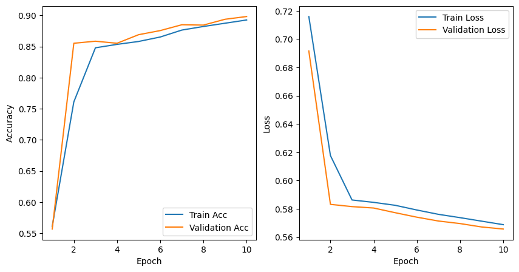

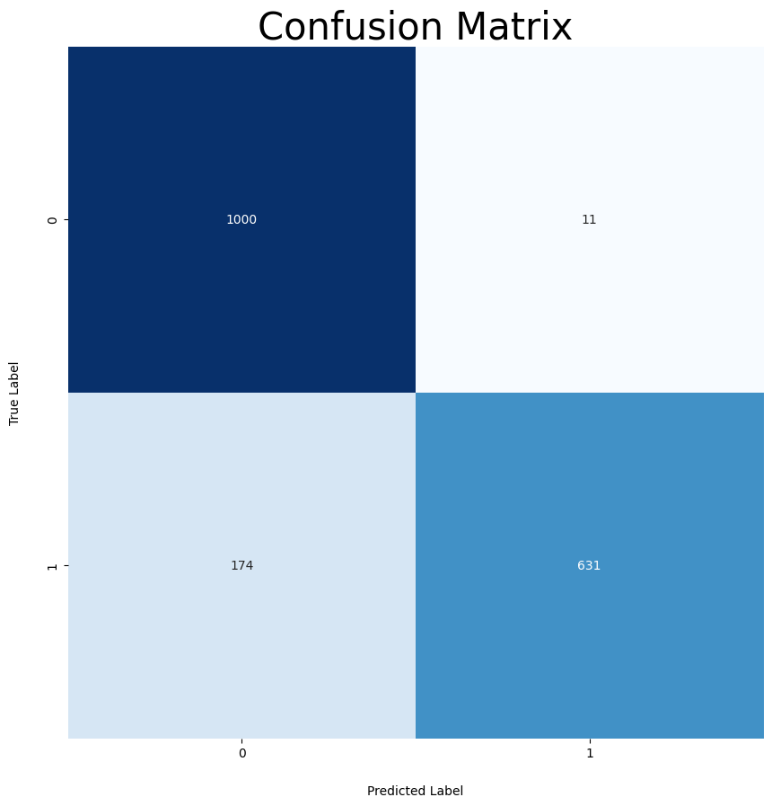

```
Recall:    0.886
F1:        0.894
Precision: 0.917
              precision    recall  f1-score   support

           0       0.85      0.99      0.92      1011
           1       0.98      0.78      0.87       805

    accuracy                           0.90      1816
   macro avg       0.92      0.89      0.89      1816
weighted avg       0.91      0.90      0.90      1816
```

```python
import torch
import torch.nn as nn
import torch.optim as optim
import torch.nn.functional as F

model = CNN()
batch_size = 16

loss_function = nn.BCEWithLogitsLoss()
optimizer = torch.optim.SGD(model.parameters(), lr=0.01, momentum=0.9, nesterov=True)

epochs = 10
device = 'auto'

cnn_model_train_history = train_model(
    model=model,
    batch_size=batch_size,
    loss_function=loss_function,
    optimizer=optimizer,
    epochs=epochs,
    train_set=train_dataset,
    valid_set=valid_dataset,
    device=device
)

trend_plot_helper(
    {
        "Accuracy - Epoch": [
            ("Train Acc", cnn_model_train_history["train_acc"]),
            ("Validation Acc", cnn_model_train_history["valid_acc"]),
        ],
        "Loss - Epoch": [
            ("Train Loss", cnn_model_train_history["train_loss"]),
            ("Validation Loss", cnn_model_train_history["valid_loss"])
        ]
    }
)

cnn_model_report = generate_confusion_matrix(
    model=model,
    dataset=valid_dataset,
)

print(f"Recall:    {cnn_model_report['recall']:.3f}")
print(f"F1:        {cnn_model_report['f1']:.3f}")
print(f"Precision: {cnn_model_report['precision']:.3f}")
print(cnn_model_report['report'])
```

This Python script trains and evaluates a convolutional neural network (CNN) for binary classification using PyTorch:

1. **Model Training Setup**: Initializes parameters for the CNN training process, including the batch size, binary cross-entropy loss function with logits, and an SGD optimizer with learning rate and momentum adjustments. The model is trained for a specified number of epochs with data provided by `train_dataset` and `valid_dataset`.
2. **Training Execution and Visualization**: Executes the training process and captures the training history, which includes training and validation accuracies and losses. This data is visualized using `trend_plot_helper` to track the model's performance over epochs.
3. **Model Evaluation**: After training, evaluates the model's performance on the validation dataset using `generate_confusion_matrix`, and calculates metrics like recall, precision, and F1 score to assess its accuracy, providing a detailed classification report for deeper analysis.

This script efficiently combines model training, performance visualization, and evaluation to ensure effective learning and validation of the neural network.

```
Epoch [1/20] Train Loss: 0.7304, Train Acc: 0.5610, Valid Loss: 0.7086, Valid Acc: 0.5567
```

```
Epoch [2/20] Train Loss: 0.6981, Train Acc: 0.5610, Valid Loss: 0.6879, Valid Acc: 0.5567
```

```
Epoch [3/20] Train Loss: 0.6521, Train Acc: 0.6353, Valid Loss: 0.5906, Valid Acc: 0.8530
```

```
Epoch [4/20] Train Loss: 0.5900, Train Acc: 0.8443, Valid Loss: 0.5837, Valid Acc: 0.8497
```

```
Epoch [5/20] Train Loss: 0.5865, Train Acc: 0.8473, Valid Loss: 0.5817, Valid Acc: 0.8563
```

```
Epoch [6/20] Train Loss: 0.5851, Train Acc: 0.8516, Valid Loss: 0.5809, Valid Acc: 0.8590
```

```
Epoch [7/20] Train Loss: 0.5840, Train Acc: 0.8548, Valid Loss: 0.5796, Valid Acc: 0.8618
```

```
Epoch [8/20] Train Loss: 0.5826, Train Acc: 0.8578, Valid Loss: 0.5788, Valid Acc: 0.8574
```

```
Epoch [9/20] Train Loss: 0.5814, Train Acc: 0.8608, Valid Loss: 0.5773, Valid Acc: 0.8645
```

```
Epoch [10/20] Train Loss: 0.5793, Train Acc: 0.8659, Valid Loss: 0.5754, Valid Acc: 0.8717
```

```
Epoch [11/20] Train Loss: 0.5773, Train Acc: 0.8722, Valid Loss: 0.5743, Valid Acc: 0.8816
```

```
Epoch [12/20] Train Loss: 0.5751, Train Acc: 0.8770, Valid Loss: 0.5724, Valid Acc: 0.8860
```

```
Epoch [13/20] Train Loss: 0.5737, Train Acc: 0.8814, Valid Loss: 0.5708, Valid Acc: 0.8866
```

```
Epoch [14/20] Train Loss: 0.5719, Train Acc: 0.8854, Valid Loss: 0.5687, Valid Acc: 0.8910
```

```
Epoch [15/20] Train Loss: 0.5704, Train Acc: 0.8907, Valid Loss: 0.5673, Valid Acc: 0.8926
```

```
Epoch [16/20] Train Loss: 0.5688, Train Acc: 0.8959, Valid Loss: 0.5699, Valid Acc: 0.8970
```

```
Epoch [17/20] Train Loss: 0.5675, Train Acc: 0.8980, Valid Loss: 0.5663, Valid Acc: 0.9003
```

```
Epoch [18/20] Train Loss: 0.5649, Train Acc: 0.9054, Valid Loss: 0.5677, Valid Acc: 0.9009
```

```
Epoch [19/20] Train Loss: 0.5636, Train Acc: 0.9077, Valid Loss: 0.5643, Valid Acc: 0.9047
```

```
Epoch [20/20] Train Loss: 0.5625, Train Acc: 0.9102, Valid Loss: 0.5642, Valid Acc: 0.9058
```

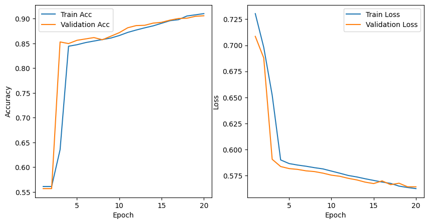

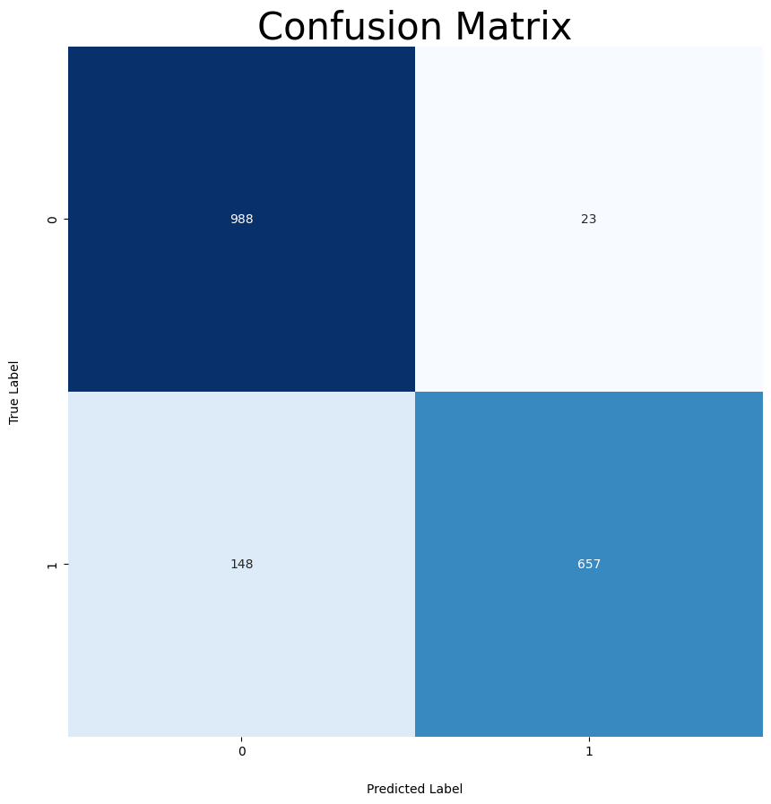

```
Recall:    0.897
F1:        0.903
Precision: 0.918
              precision    recall  f1-score   support

           0       0.87      0.98      0.92      1011
           1       0.97      0.82      0.88       805

    accuracy                           0.91      1816
   macro avg       0.92      0.90      0.90      1816
weighted avg       0.91      0.91      0.90      1816
```

```python
import torch
import torch.nn as nn
import torch.optim as optim
import torch.nn.functional as F

model = CNN()

batch_size = 30
loss_function = nn.BCEWithLogitsLoss()
optimizer = torch.optim.SGD(model.parameters(), lr=0.01, momentum=0.9, nesterov=True)

epochs = 20
device = 'auto'

cnn_model_train_history = train_model(
    model=model,
    batch_size=batch_size,
    loss_function=loss_function,
    optimizer=optimizer,
    epochs=epochs,
    train_set=train_dataset,
    valid_set=valid_dataset,
    device=device
)

trend_plot_helper(
    {
        "Accuracy - Epoch": [
            ("Train Acc", cnn_model_train_history["train_acc"]),
            ("Validation Acc", cnn_model_train_history["valid_acc"]),
        ],
        "Loss - Epoch": [
            ("Train Loss", cnn_model_train_history["train_loss"]),
            ("Validation Loss", cnn_model_train_history["valid_loss"])
        ]
    }
)

cnn_model_report = generate_confusion_matrix(
    model=model,
    dataset=valid_dataset,
)


print(f"Recall:    {cnn_model_report['recall']:.3f}")
print(f"F1:        {cnn_model_report['f1']:.3f}")
print(f"Precision: {cnn_model_report['precision']:.3f}")
print(cnn_model_report['report'])
```

1. **Model Training**: The script configures and trains a CNN with specific parameters such as batch size, learning rate, and momentum using training and validation datasets over 30 epochs.
2. **Visualization**: It employs a helper function to plot training and validation accuracy and loss, providing insights into the model's learning progression and stability.
3. **Evaluation and Metrics**: Generates a confusion matrix for validation data, calculates and displays key performance metrics like recall, precision, and F1 score, providing a comprehensive evaluation of the model's effectiveness.

```
Epoch [1/30] Train Loss: 0.7471, Train Acc: 0.5508, Valid Loss: 0.7375, Valid Acc: 0.5567
```

```
Epoch [2/30] Train Loss: 0.7324, Train Acc: 0.5610, Valid Loss: 0.7239, Valid Acc: 0.5567
```

```
Epoch [3/30] Train Loss: 0.7188, Train Acc: 0.5610, Valid Loss: 0.7117, Valid Acc: 0.5567
```

```
Epoch [4/30] Train Loss: 0.7073, Train Acc: 0.5610, Valid Loss: 0.7018, Valid Acc: 0.5567
```

```
Epoch [5/30] Train Loss: 0.6989, Train Acc: 0.5610, Valid Loss: 0.6951, Valid Acc: 0.5567
```

```
Epoch [6/30] Train Loss: 0.6919, Train Acc: 0.5610, Valid Loss: 0.6858, Valid Acc: 0.5567
```

```
Epoch [7/30] Train Loss: 0.6706, Train Acc: 0.5610, Valid Loss: 0.6503, Valid Acc: 0.5567
```

```
Epoch [8/30] Train Loss: 0.6207, Train Acc: 0.7830, Valid Loss: 0.5936, Valid Acc: 0.8502
```

```
Epoch [9/30] Train Loss: 0.5946, Train Acc: 0.8409, Valid Loss: 0.5868, Valid Acc: 0.8513
```

```
Epoch [10/30] Train Loss: 0.5904, Train Acc: 0.8432, Valid Loss: 0.5849, Valid Acc: 0.8508
```

```
Epoch [11/30] Train Loss: 0.5892, Train Acc: 0.8439, Valid Loss: 0.5837, Valid Acc: 0.8524
```

```
Epoch [12/30] Train Loss: 0.5880, Train Acc: 0.8451, Valid Loss: 0.5829, Valid Acc: 0.8535
```

```
Epoch [13/30] Train Loss: 0.5871, Train Acc: 0.8467, Valid Loss: 0.5823, Valid Acc: 0.8574
```

```
Epoch [14/30] Train Loss: 0.5859, Train Acc: 0.8498, Valid Loss: 0.5818, Valid Acc: 0.8585
```

```
Epoch [15/30] Train Loss: 0.5858, Train Acc: 0.8505, Valid Loss: 0.5813, Valid Acc: 0.8552
```

```
Epoch [16/30] Train Loss: 0.5852, Train Acc: 0.8523, Valid Loss: 0.5809, Valid Acc: 0.8590
```

```
Epoch [17/30] Train Loss: 0.5848, Train Acc: 0.8531, Valid Loss: 0.5806, Valid Acc: 0.8607
```

```
Epoch [18/30] Train Loss: 0.5844, Train Acc: 0.8546, Valid Loss: 0.5804, Valid Acc: 0.8590
```

```
Epoch [19/30] Train Loss: 0.5839, Train Acc: 0.8552, Valid Loss: 0.5800, Valid Acc: 0.8596
```

```
Epoch [20/30] Train Loss: 0.5837, Train Acc: 0.8555, Valid Loss: 0.5797, Valid Acc: 0.8612
```

```
Epoch [21/30] Train Loss: 0.5834, Train Acc: 0.8575, Valid Loss: 0.5794, Valid Acc: 0.8618
```

```
Epoch [22/30] Train Loss: 0.5825, Train Acc: 0.8566, Valid Loss: 0.5791, Valid Acc: 0.8640
```

```
Epoch [23/30] Train Loss: 0.5825, Train Acc: 0.8589, Valid Loss: 0.5787, Valid Acc: 0.8651
```

```
Epoch [24/30] Train Loss: 0.5816, Train Acc: 0.8608, Valid Loss: 0.5786, Valid Acc: 0.8662
```

```
Epoch [25/30] Train Loss: 0.5816, Train Acc: 0.8601, Valid Loss: 0.5780, Valid Acc: 0.8684
```

```
Epoch [26/30] Train Loss: 0.5809, Train Acc: 0.8626, Valid Loss: 0.5779, Valid Acc: 0.8612
```

```
Epoch [27/30] Train Loss: 0.5807, Train Acc: 0.8633, Valid Loss: 0.5770, Valid Acc: 0.8678
```

```
Epoch [28/30] Train Loss: 0.5802, Train Acc: 0.8643, Valid Loss: 0.5766, Valid Acc: 0.8695
```

```
Epoch [29/30] Train Loss: 0.5795, Train Acc: 0.8655, Valid Loss: 0.5761, Valid Acc: 0.8706
```

```
Epoch [30/30] Train Loss: 0.5789, Train Acc: 0.8674, Valid Loss: 0.5754, Valid Acc: 0.8722
```

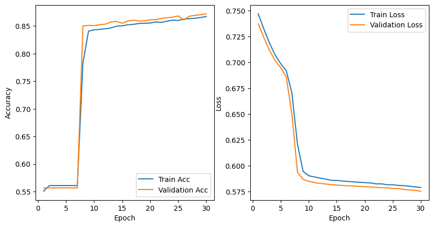

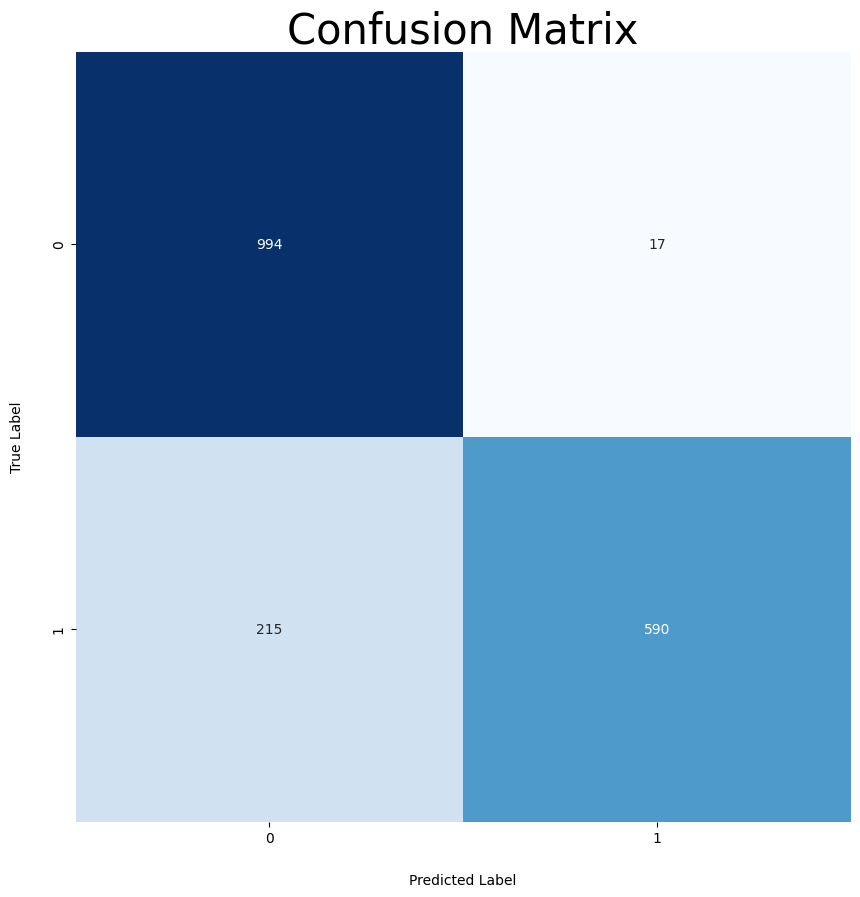

```
Recall:    0.858
F1:        0.866
Precision: 0.897
              precision    recall  f1-score   support

           0       0.82      0.98      0.90      1011
           1       0.97      0.73      0.84       805

    accuracy                           0.87      1816
   macro avg       0.90      0.86      0.87      1816
weighted avg       0.89      0.87      0.87      1816
```

```python
import torch
import torch.nn as nn
import torch.optim as optim
import torch.nn.functional as F

model = CNN()

batch_size = 10
loss_function = nn.BCEWithLogitsLoss()
optimizer = torch.optim.SGD(model.parameters(), lr=0.001, momentum=0.9, nesterov=True)

epochs = 30
device = 'auto'

cnn_model_train_history = train_model(
    model=model,
    batch_size=batch_size,
    loss_function=loss_function,
    optimizer=optimizer,
    epochs=epochs,
    train_set=train_dataset,
    valid_set=valid_dataset,
    device=device
)

trend_plot_helper(
    {
        "Accuracy - Epoch": [
            ("Train Acc", cnn_model_train_history["train_acc"]),
            ("Validation Acc", cnn_model_train_history["valid_acc"]),
        ],
        "Loss - Epoch": [
            ("Train Loss", cnn_model_train_history["train_loss"]),
            ("Validation Loss", cnn_model_train_history["valid_loss"])
        ]
    }
)

cnn_model_report = generate_confusion_matrix(
    model=model,
    dataset=valid_dataset,
)


print(f"Recall:    {cnn_model_report['recall']:.3f}")
print(f"F1:        {cnn_model_report['f1']:.3f}")
print(f"Precision: {cnn_model_report['precision']:.3f}")
print(cnn_model_report['report'])
```

1. **Model Configuration and Training**: Sets up a CNN with BCEWithLogitsLoss and an Adam optimizer for training over 10 epochs using specified batch sizes on either GPU or CPU as selected automatically. The model is trained with designated training and validation datasets.
2. **Tracking and Visualization**: Utilizes `trend_plot_helper` to visually represent the progression of training and validation accuracy and loss across epochs, aiding in performance monitoring and adjustment of training strategies.
3. **Performance Evaluation**: After training, the script generates a confusion matrix for the validation dataset, calculates crucial metrics like recall, F1 score, and precision, and provides a detailed classification report to assess the model’s predictive accuracy and reliability.

```
Epoch [1/10] Train Loss: 0.6145, Train Acc: 0.8046, Valid Loss: 0.5867, Valid Acc: 0.8519
```

```
Epoch [2/10] Train Loss: 0.5875, Train Acc: 0.8467, Valid Loss: 0.5820, Valid Acc: 0.8568
```

```
Epoch [3/10] Train Loss: 0.5872, Train Acc: 0.8478, Valid Loss: 0.5836, Valid Acc: 0.8574
```

```
Epoch [4/10] Train Loss: 0.5864, Train Acc: 0.8482, Valid Loss: 0.5836, Valid Acc: 0.8574
```

```
Epoch [5/10] Train Loss: 0.5862, Train Acc: 0.8446, Valid Loss: 0.5821, Valid Acc: 0.8574
```

```
Epoch [6/10] Train Loss: 0.5853, Train Acc: 0.8513, Valid Loss: 0.5822, Valid Acc: 0.8552
```

```
Epoch [7/10] Train Loss: 0.5845, Train Acc: 0.8515, Valid Loss: 0.5844, Valid Acc: 0.8579
```

```
Epoch [8/10] Train Loss: 0.5832, Train Acc: 0.8537, Valid Loss: 0.5824, Valid Acc: 0.8524
```

```
Epoch [9/10] Train Loss: 0.5840, Train Acc: 0.8552, Valid Loss: 0.5808, Valid Acc: 0.8629
```

```
Epoch [10/10] Train Loss: 0.5778, Train Acc: 0.8684, Valid Loss: 0.5776, Valid Acc: 0.8656
```

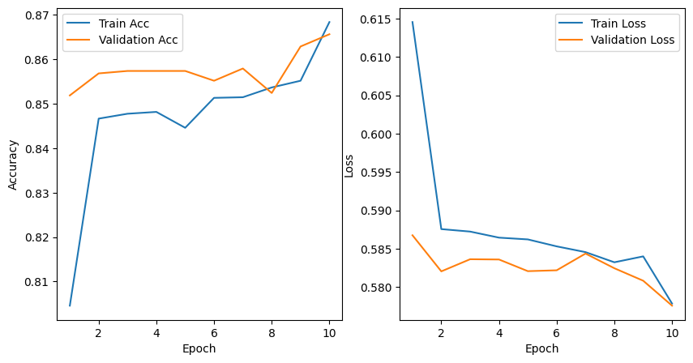

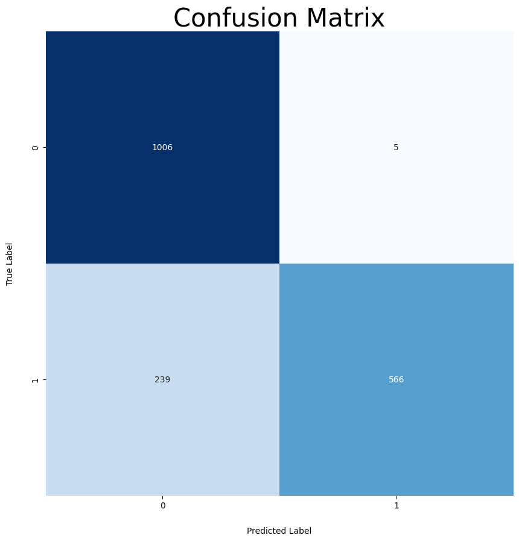

```
Recall:    0.849
F1:        0.857
Precision: 0.900
              precision    recall  f1-score   support

           0       0.81      1.00      0.89      1011
           1       0.99      0.70      0.82       805

    accuracy                           0.87      1816
   macro avg       0.90      0.85      0.86      1816
weighted avg       0.89      0.87      0.86      1816
```

```python
import torch
import torch.nn as nn
import torch.optim as optim
import torch.nn.functional as F

model = CNN()

batch_size = 120
loss_function = nn.BCEWithLogitsLoss()
optimizer = torch.optim.Adam(model.parameters(), lr=0.001)
epochs = 10
device = 'auto'

cnn_model_train_history = train_model(
    model=model,
    batch_size=batch_size,
    loss_function=loss_function,
    optimizer=optimizer,
    epochs=epochs,
    train_set=train_dataset,
    valid_set=valid_dataset,
    device=device
)

trend_plot_helper(
    {
        "Accuracy - Epoch": [
            ("Train Acc", cnn_model_train_history["train_acc"]),
            ("Validation Acc", cnn_model_train_history["valid_acc"]),
        ],
        "Loss - Epoch": [
            ("Train Loss", cnn_model_train_history["train_loss"]),
            ("Validation Loss", cnn_model_train_history["valid_loss"])
        ]
    }
)

cnn_model_report = generate_confusion_matrix(
    model=model,
    dataset=valid_dataset,
)


print(f"Recall:    {cnn_model_report['recall']:.3f}")
print(f"F1:        {cnn_model_report['f1']:.3f}")
print(f"Precision: {cnn_model_report['precision']:.3f}")
print(cnn_model_report['report'])
```

1. **Model Setup and Training**: The script initializes a convolutional neural network (CNN) with a BCEWithLogitsLoss and an Adam optimizer, training it across 10 epochs on training and validation datasets with a batch size of 30, automatically using the best available device (CPU or GPU).
2. **Visualization of Training Metrics**: It employs `trend_plot_helper` to graphically depict the training and validation accuracy and loss over the epochs, allowing for visual assessment of model performance and adjustments.
3. **Model Evaluation**: After the training phase, the script computes a confusion matrix from the validation dataset, calculates key performance metrics like recall, F1 score, and precision, and prints a detailed classification report to evaluate the model's effectiveness comprehensively.

```
Epoch [1/10] Train Loss: 0.5964, Train Acc: 0.8311, Valid Loss: 0.5810, Valid Acc: 0.8574
```

```
Epoch [2/10] Train Loss: 0.5866, Train Acc: 0.8439, Valid Loss: 0.5807, Valid Acc: 0.8563
```

```
Epoch [3/10] Train Loss: 0.5866, Train Acc: 0.8435, Valid Loss: 0.5859, Valid Acc: 0.8403
```

```
Epoch [4/10] Train Loss: 0.5872, Train Acc: 0.8471, Valid Loss: 0.5830, Valid Acc: 0.8590
```

```
Epoch [5/10] Train Loss: 0.5870, Train Acc: 0.8445, Valid Loss: 0.5935, Valid Acc: 0.8199
```

```
Epoch [6/10] Train Loss: 0.5889, Train Acc: 0.8387, Valid Loss: 0.5806, Valid Acc: 0.8590
```

```
Epoch [7/10] Train Loss: 0.5861, Train Acc: 0.8519, Valid Loss: 0.5828, Valid Acc: 0.8502
```

```
Epoch [8/10] Train Loss: 0.5859, Train Acc: 0.8512, Valid Loss: 0.5905, Valid Acc: 0.8574
```

```
Epoch [9/10] Train Loss: 0.5862, Train Acc: 0.8495, Valid Loss: 0.5836, Valid Acc: 0.8491
```

```
Epoch [10/10] Train Loss: 0.5876, Train Acc: 0.8469, Valid Loss: 0.5831, Valid Acc: 0.8491
```

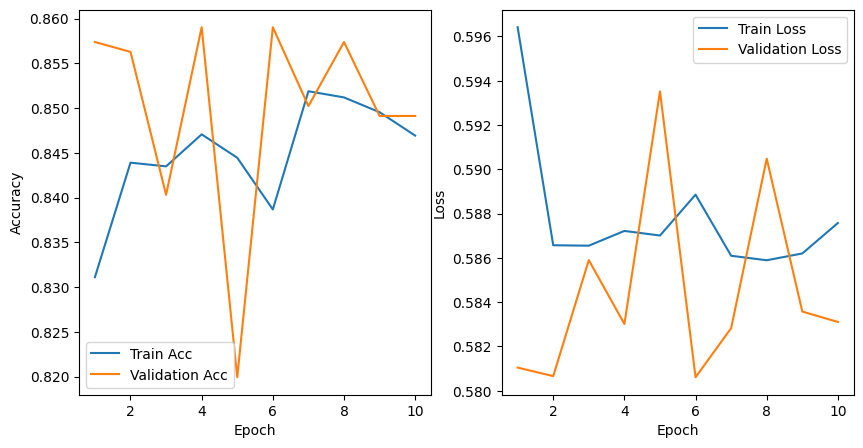

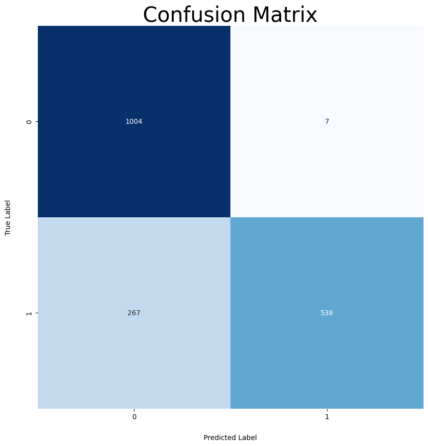

```
Recall:    0.831
F1:        0.838
Precision: 0.889
              precision    recall  f1-score   support

           0       0.79      0.99      0.88      1011
           1       0.99      0.67      0.80       805

    accuracy                           0.85      1816
   macro avg       0.89      0.83      0.84      1816
weighted avg       0.88      0.85      0.84      1816
```

```python
import torch
import torch.nn as nn
import torch.optim as optim
import torch.nn.functional as F

model = CNN()

batch_size = 30
loss_function = nn.BCEWithLogitsLoss()
optimizer = torch.optim.Adam(model.parameters(), lr=0.001)
epochs = 10
device = 'auto'

cnn_model_train_history = train_model(
    model=model,
    batch_size=batch_size,
    loss_function=loss_function,
    optimizer=optimizer,
    epochs=epochs,
    train_set=train_dataset,
    valid_set=valid_dataset,
    device=device
)

trend_plot_helper(
    {
        "Accuracy - Epoch": [
            ("Train Acc", cnn_model_train_history["train_acc"]),
            ("Validation Acc", cnn_model_train_history["valid_acc"]),
        ],
        "Loss - Epoch": [
            ("Train Loss", cnn_model_train_history["train_loss"]),
            ("Validation Loss", cnn_model_train_history["valid_loss"])
        ]
    }
)

cnn_model_report = generate_confusion_matrix(
    model=model,
    dataset=valid_dataset,
)


print(f"Recall:    {cnn_model_report['recall']:.3f}")
print(f"F1:        {cnn_model_report['f1']:.3f}")
print(f"Precision: {cnn_model_report['precision']:.3f}")
print(cnn_model_report['report'])
```

1. **Model Training Configuration**: The script sets up a CNN with BCEWithLogitsLoss for binary classification, using the AdamW optimizer which incorporates weight decay for regularization. The model is trained for 20 epochs on designated training and validation datasets with a batch size of 120, utilizing either CPU or GPU as determined automatically.
2. **Visualization of Progress**: The training and validation performance metrics (accuracy and loss) are tracked over the epochs and visualized using `trend_plot_helper`, providing insights into the model's learning trends and helping to identify areas for improvement.
3. **Performance Evaluation**: Following training, a confusion matrix is generated for the validation dataset, and key metrics such as recall, F1 score, and precision are calculated and displayed alongside a comprehensive classification report. This detailed analysis helps gauge the model's ability to generalize and perform on unseen data effectively.

```
Epoch [1/20] Train Loss: 0.6135, Train Acc: 0.8220, Valid Loss: 0.5837, Valid Acc: 0.8541
```

```
Epoch [2/20] Train Loss: 0.5877, Train Acc: 0.8456, Valid Loss: 0.5841, Valid Acc: 0.8557
```

```
Epoch [3/20] Train Loss: 0.5885, Train Acc: 0.8445, Valid Loss: 0.5826, Valid Acc: 0.8524
```

```
Epoch [4/20] Train Loss: 0.5843, Train Acc: 0.8493, Valid Loss: 0.5837, Valid Acc: 0.8612
```

```
Epoch [5/20] Train Loss: 0.5854, Train Acc: 0.8537, Valid Loss: 0.5842, Valid Acc: 0.8464
```

```
Epoch [6/20] Train Loss: 0.5844, Train Acc: 0.8505, Valid Loss: 0.5809, Valid Acc: 0.8585
```

```
Epoch [7/20] Train Loss: 0.5821, Train Acc: 0.8567, Valid Loss: 0.5809, Valid Acc: 0.8574
```

```
Epoch [8/20] Train Loss: 0.5813, Train Acc: 0.8601, Valid Loss: 0.5819, Valid Acc: 0.8645
```

```
Epoch [9/20] Train Loss: 0.5796, Train Acc: 0.8629, Valid Loss: 0.5795, Valid Acc: 0.8689
```

```
Epoch [10/20] Train Loss: 0.5747, Train Acc: 0.8775, Valid Loss: 0.5754, Valid Acc: 0.8855
```

```
Epoch [11/20] Train Loss: 0.5705, Train Acc: 0.8886, Valid Loss: 0.5709, Valid Acc: 0.8893
```

```
Epoch [12/20] Train Loss: 0.5683, Train Acc: 0.8959, Valid Loss: 0.5759, Valid Acc: 0.8684
```

```
Epoch [13/20] Train Loss: 0.5688, Train Acc: 0.8929, Valid Loss: 0.5706, Valid Acc: 0.8937
```

```
Epoch [14/20] Train Loss: 0.5635, Train Acc: 0.9063, Valid Loss: 0.5662, Valid Acc: 0.9031
```

```
Epoch [15/20] Train Loss: 0.5635, Train Acc: 0.9066, Valid Loss: 0.5666, Valid Acc: 0.9009
```

```
Epoch [16/20] Train Loss: 0.5594, Train Acc: 0.9194, Valid Loss: 0.5659, Valid Acc: 0.9047
```

```
Epoch [17/20] Train Loss: 0.5556, Train Acc: 0.9263, Valid Loss: 0.5676, Valid Acc: 0.9064
```

```
Epoch [18/20] Train Loss: 0.5552, Train Acc: 0.9311, Valid Loss: 0.5631, Valid Acc: 0.9097
```

```
Epoch [19/20] Train Loss: 0.5524, Train Acc: 0.9354, Valid Loss: 0.5645, Valid Acc: 0.9097
```

```
Epoch [20/20] Train Loss: 0.5514, Train Acc: 0.9384, Valid Loss: 0.5662, Valid Acc: 0.9069
```

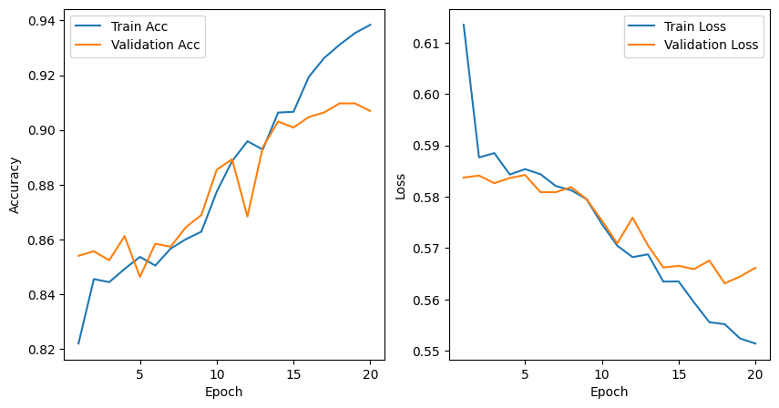

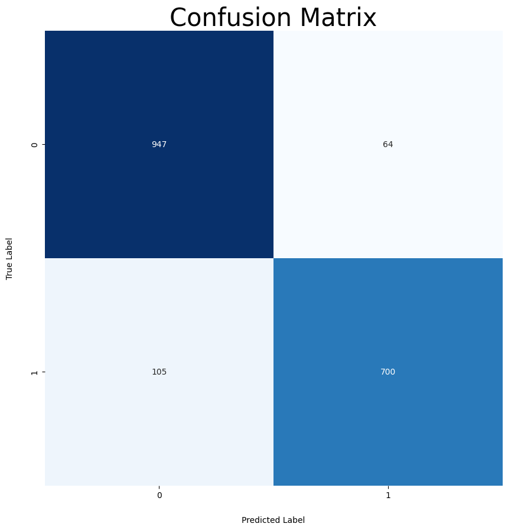

```
Recall:    0.903
F1:        0.905
Precision: 0.908
              precision    recall  f1-score   support

           0       0.90      0.94      0.92      1011
           1       0.92      0.87      0.89       805

    accuracy                           0.91      1816
   macro avg       0.91      0.90      0.91      1816
weighted avg       0.91      0.91      0.91      1816
```

```python
import torch
import torch.nn as nn
import torch.optim as optim
import torch.nn.functional as F

model = CNN()

batch_size = 120
loss_function = nn.BCEWithLogitsLoss()
optimizer = torch.optim.AdamW(model.parameters(), lr=0.001, betas=(0.9, 0.999), weight_decay=0.01)


epochs = 20
device = 'auto'

cnn_model_train_history = train_model(
    model=model,
    batch_size=batch_size,
    loss_function=loss_function,
    optimizer=optimizer,
    epochs=epochs,
    train_set=train_dataset,
    valid_set=valid_dataset,
    device=device
)

trend_plot_helper(
    {
        "Accuracy - Epoch": [
            ("Train Acc", cnn_model_train_history["train_acc"]),
            ("Validation Acc", cnn_model_train_history["valid_acc"]),
        ],
        "Loss - Epoch": [
            ("Train Loss", cnn_model_train_history["train_loss"]),
            ("Validation Loss", cnn_model_train_history["valid_loss"])
        ]
    }
)

cnn_model_report = generate_confusion_matrix(
    model=model,
    dataset=valid_dataset,
)


print(f"Recall:    {cnn_model_report['recall']:.3f}")
print(f"F1:        {cnn_model_report['f1']:.3f}")
print(f"Precision: {cnn_model_report['precision']:.3f}")
print(cnn_model_report['report'])
```

1. **Setup and Training**: The script prepares and trains a convolutional neural network using a stochastic gradient descent optimizer with momentum and Nesterov acceleration, aiming to minimize the binary cross-entropy loss across 10 epochs. Training and validation processes utilize datasets with a batch size of 30 on the best available device (GPU or CPU).
2. **Tracking and Visualization**: Throughout the training period, the script captures and visualizes the model's accuracy and loss for both training and validation sets using `trend_plot_helper`, helping to monitor performance improvements or identify potential overfitting.
3. **Evaluation and Reporting**: After training, it evaluates the model's performance on the validation set using a confusion matrix, calculates key metrics such as recall, F1 score, and precision, and prints a detailed classification report to assess the model’s precision and reliability in classifying new data.

```
Epoch [1/10] Train Loss: 0.7317, Train Acc: 0.5609, Valid Loss: 0.7105, Valid Acc: 0.5567
```

```
Epoch [2/10] Train Loss: 0.6957, Train Acc: 0.5610, Valid Loss: 0.6639, Valid Acc: 0.5567
```

```
Epoch [3/10] Train Loss: 0.6060, Train Acc: 0.8018, Valid Loss: 0.5844, Valid Acc: 0.8519
```

```
Epoch [4/10] Train Loss: 0.5879, Train Acc: 0.8460, Valid Loss: 0.5821, Valid Acc: 0.8552
```

```
Epoch [5/10] Train Loss: 0.5859, Train Acc: 0.8506, Valid Loss: 0.5811, Valid Acc: 0.8552
```

```
Epoch [6/10] Train Loss: 0.5844, Train Acc: 0.8528, Valid Loss: 0.5802, Valid Acc: 0.8596
```

```
Epoch [7/10] Train Loss: 0.5833, Train Acc: 0.8568, Valid Loss: 0.5798, Valid Acc: 0.8579
```

```
Epoch [8/10] Train Loss: 0.5824, Train Acc: 0.8594, Valid Loss: 0.5784, Valid Acc: 0.8601
```

```
Epoch [9/10] Train Loss: 0.5812, Train Acc: 0.8623, Valid Loss: 0.5774, Valid Acc: 0.8706
```

```
Epoch [10/10] Train Loss: 0.5795, Train Acc: 0.8648, Valid Loss: 0.5752, Valid Acc: 0.8695
```

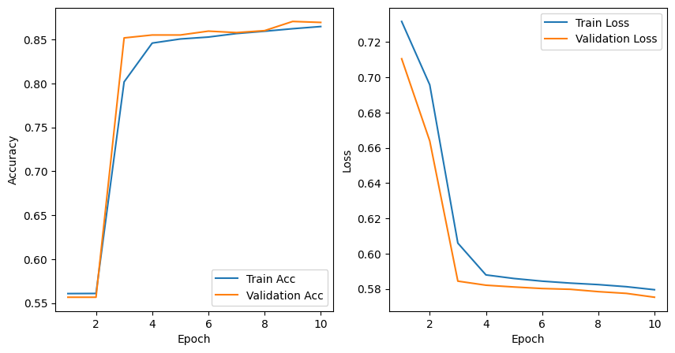

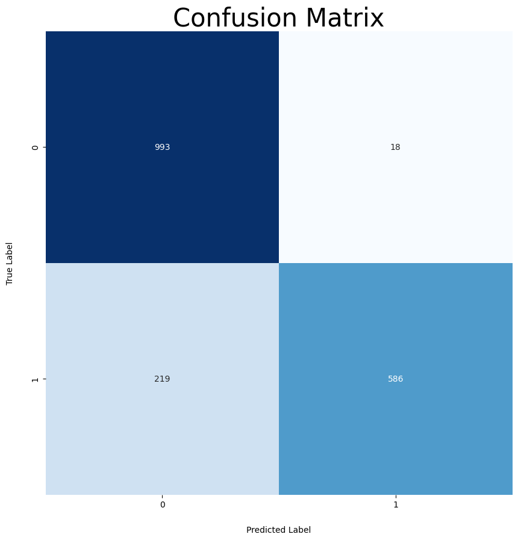

```
Recall:    0.855
F1:        0.863
Precision: 0.895
              precision    recall  f1-score   support

           0       0.82      0.98      0.89      1011
           1       0.97      0.73      0.83       805

    accuracy                           0.87      1816
   macro avg       0.89      0.86      0.86      1816
weighted avg       0.89      0.87      0.87      1816
```

```python
import torch
import torch.nn as nn
import torch.optim as optim
import torch.nn.functional as F

model = CNN()

batch_size = 30
loss_function = nn.BCEWithLogitsLoss()
optimizer = torch.optim.SGD(model.parameters(), lr=0.01, momentum=0.9, nesterov=True)


epochs = 10
device = 'auto'

cnn_model_train_history = train_model(
    model=model,
    batch_size=batch_size,
    loss_function=loss_function,
    optimizer=optimizer,
    epochs=epochs,
    train_set=train_dataset,
    valid_set=valid_dataset,
    device=device
)

trend_plot_helper(
    {
        "Accuracy - Epoch": [
            ("Train Acc", cnn_model_train_history["train_acc"]),
            ("Validation Acc", cnn_model_train_history["valid_acc"]),
        ],
        "Loss - Epoch": [
            ("Train Loss", cnn_model_train_history["train_loss"]),
            ("Validation Loss", cnn_model_train_history["valid_loss"])
        ]
    }
)

cnn_model_report = generate_confusion_matrix(
    model=model,
    dataset=valid_dataset,
)


print(f"Recall:    {cnn_model_report['recall']:.3f}")
print(f"F1:        {cnn_model_report['f1']:.3f}")
print(f"Precision: {cnn_model_report['precision']:.3f}")
print(cnn_model_report['report'])
```

1. **Training Configuration**: The script sets up a convolutional neural network (CNN) with a BCEWithLogitsLoss and RMSprop optimizer, which is particularly designed to handle noisy gradients and adaptively adjust learning rates. The model trains for 10 epochs using batches of 30 samples each, dynamically choosing between CPU and GPU based on availability.
2. **Performance Monitoring**: Utilizes the `trend_plot_helper` function to graph training and validation accuracy and loss, offering visual feedback on the model's performance over time, which helps in understanding training dynamics and effectiveness.
3. **Model Evaluation**: After training, evaluates the model's precision and ability to generalize using a confusion matrix on the validation dataset. It calculates key performance indicators like recall, F1 score, and precision, providing a comprehensive classification report to detail the model's performance across different classes.

```
Epoch [1/10] Train Loss: 0.5916, Train Acc: 0.8378, Valid Loss: 0.5844, Valid Acc: 0.8442
```

```
Epoch [2/10] Train Loss: 0.5883, Train Acc: 0.8429, Valid Loss: 0.5834, Valid Acc: 0.8585
```

```
Epoch [3/10] Train Loss: 0.5872, Train Acc: 0.8425, Valid Loss: 0.5806, Valid Acc: 0.8557
```

```
Epoch [4/10] Train Loss: 0.5886, Train Acc: 0.8509, Valid Loss: 0.5817, Valid Acc: 0.8513
```

```
Epoch [5/10] Train Loss: 0.5850, Train Acc: 0.8522, Valid Loss: 0.5846, Valid Acc: 0.8640
```

```
Epoch [6/10] Train Loss: 0.5867, Train Acc: 0.8544, Valid Loss: 0.5839, Valid Acc: 0.8453
```

```
Epoch [7/10] Train Loss: 0.5884, Train Acc: 0.8383, Valid Loss: 0.5816, Valid Acc: 0.8524
```

```
Epoch [8/10] Train Loss: 0.5852, Train Acc: 0.8513, Valid Loss: 0.5796, Valid Acc: 0.8585
```

```
Epoch [9/10] Train Loss: 0.5875, Train Acc: 0.8479, Valid Loss: 0.5749, Valid Acc: 0.8739
```

```
Epoch [10/10] Train Loss: 0.5868, Train Acc: 0.8528, Valid Loss: 0.5800, Valid Acc: 0.8717
```

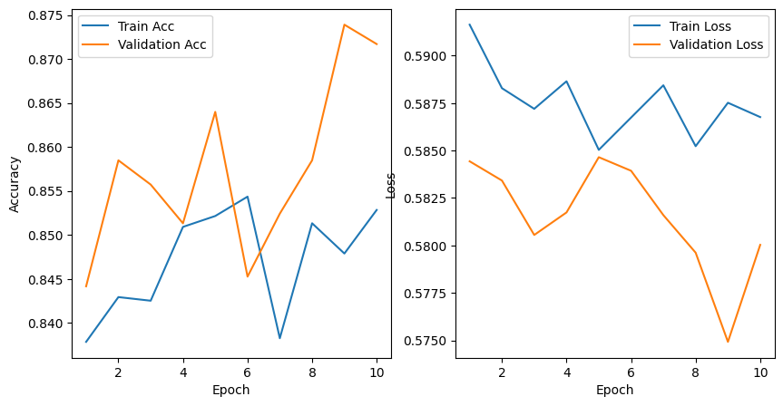

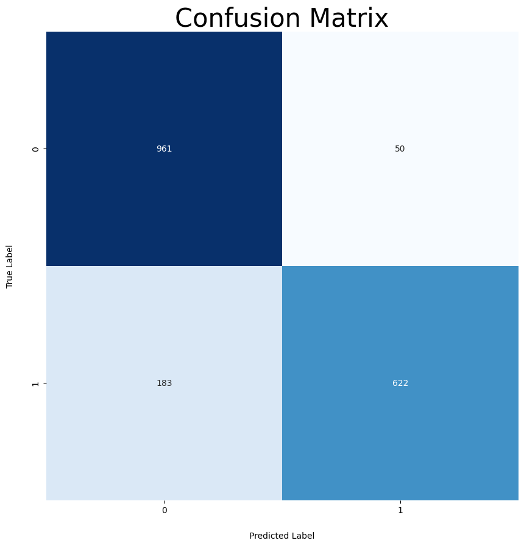

```
Recall:    0.862
F1:        0.867
Precision: 0.883
              precision    recall  f1-score   support

           0       0.84      0.95      0.89      1011
           1       0.93      0.77      0.84       805

    accuracy                           0.87      1816
   macro avg       0.88      0.86      0.87      1816
weighted avg       0.88      0.87      0.87      1816
```

```python
import torch
import torch.nn as nn
import torch.optim as optim
import torch.nn.functional as F

model = CNN()


batch_size = 30
loss_function = nn.BCEWithLogitsLoss()
optimizer = torch.optim.RMSprop(model.parameters(), lr=0.001, alpha=0.99)


epochs = 10
device = 'auto'

cnn_model_train_history = train_model(
    model=model,
    batch_size=batch_size,
    loss_function=loss_function,
    optimizer=optimizer,
    epochs=epochs,
    train_set=train_dataset,
    valid_set=valid_dataset,
    device=device
)

trend_plot_helper(
    {
        "Accuracy - Epoch": [
            ("Train Acc", cnn_model_train_history["train_acc"]),
            ("Validation Acc", cnn_model_train_history["valid_acc"]),
        ],
        "Loss - Epoch": [
            ("Train Loss", cnn_model_train_history["train_loss"]),
            ("Validation Loss", cnn_model_train_history["valid_loss"])
        ]
    }
)

cnn_model_report = generate_confusion_matrix(
    model=model,
    dataset=valid_dataset,
)


print(f"Recall:    {cnn_model_report['recall']:.3f}")
print(f"F1:        {cnn_model_report['f1']:.3f}")
print(f"Precision: {cnn_model_report['precision']:.3f}")
print(cnn_model_report['report'])
```

1. **Training Setup and Execution**: The script configures a CNN with a loss function suitable for binary classification (BCEWithLogitsLoss) and uses the Adadelta optimizer, known for its robustness and simplicity in managing learning rates. The network undergoes training over 20 epochs with a large batch size of 120, utilizing adaptive device selection for optimal performance.
2. **Training Progress Visualization**: It employs the `trend_plot_helper` function to visually track and compare the training and validation accuracy and loss across the epochs, which aids in diagnosing the model's learning behavior and its consistency across both datasets.
3. **Model Evaluation and Metrics Reporting**: Post-training, the script generates a confusion matrix from the validation dataset to quantitatively assess the model’s classification accuracy, calculating essential metrics like recall, precision, and F1 score. Additionally, it prints a detailed classification report, providing deeper insights into the model's performance on different classes.

```
Epoch [1/20] Train Loss: 0.6912, Train Acc: 0.6141, Valid Loss: 0.5928, Valid Acc: 0.8491
```

```
Epoch [2/20] Train Loss: 0.5890, Train Acc: 0.8427, Valid Loss: 0.5833, Valid Acc: 0.8596
```

```
Epoch [3/20] Train Loss: 0.5848, Train Acc: 0.8517, Valid Loss: 0.5803, Valid Acc: 0.8634
```

```
Epoch [4/20] Train Loss: 0.5829, Train Acc: 0.8578, Valid Loss: 0.5776, Valid Acc: 0.8695
```

```
Epoch [5/20] Train Loss: 0.5796, Train Acc: 0.8677, Valid Loss: 0.5762, Valid Acc: 0.8662
```

```
Epoch [6/20] Train Loss: 0.5774, Train Acc: 0.8714, Valid Loss: 0.5728, Valid Acc: 0.8871
```

```
Epoch [7/20] Train Loss: 0.5762, Train Acc: 0.8757, Valid Loss: 0.5708, Valid Acc: 0.8899
```

```
Epoch [8/20] Train Loss: 0.5737, Train Acc: 0.8820, Valid Loss: 0.5707, Valid Acc: 0.8915
```

```
Epoch [9/20] Train Loss: 0.5721, Train Acc: 0.8854, Valid Loss: 0.5668, Valid Acc: 0.8959
```

```
Epoch [10/20] Train Loss: 0.5706, Train Acc: 0.8894, Valid Loss: 0.5653, Valid Acc: 0.8998
```

```
Epoch [11/20] Train Loss: 0.5672, Train Acc: 0.8989, Valid Loss: 0.5639, Valid Acc: 0.8998
```

```
Epoch [12/20] Train Loss: 0.5660, Train Acc: 0.9002, Valid Loss: 0.5640, Valid Acc: 0.9047
```

```
Epoch [13/20] Train Loss: 0.5672, Train Acc: 0.9003, Valid Loss: 0.5675, Valid Acc: 0.9003
```

```
Epoch [14/20] Train Loss: 0.5650, Train Acc: 0.9050, Valid Loss: 0.5663, Valid Acc: 0.8932
```

```
Epoch [15/20] Train Loss: 0.5633, Train Acc: 0.9085, Valid Loss: 0.5641, Valid Acc: 0.9069
```

```
Epoch [16/20] Train Loss: 0.5614, Train Acc: 0.9139, Valid Loss: 0.5735, Valid Acc: 0.8954
```

```
Epoch [17/20] Train Loss: 0.5614, Train Acc: 0.9118, Valid Loss: 0.5683, Valid Acc: 0.8849
```

```
Epoch [18/20] Train Loss: 0.5590, Train Acc: 0.9176, Valid Loss: 0.5601, Valid Acc: 0.9141
```

```
Epoch [19/20] Train Loss: 0.5605, Train Acc: 0.9157, Valid Loss: 0.5639, Valid Acc: 0.8981
```

```
Epoch [20/20] Train Loss: 0.5603, Train Acc: 0.9146, Valid Loss: 0.5605, Valid Acc: 0.9135
```

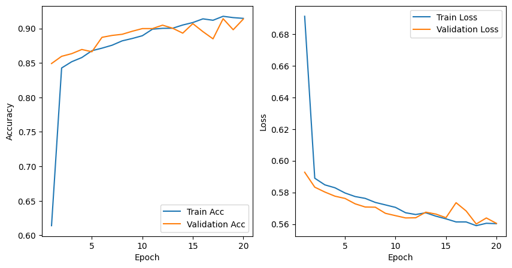

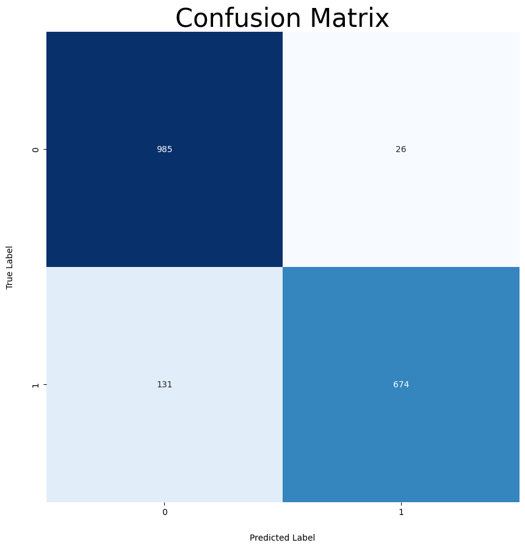

```
Recall:    0.906
F1:        0.911
Precision: 0.923
              precision    recall  f1-score   support

           0       0.88      0.97      0.93      1011
           1       0.96      0.84      0.90       805

    accuracy                           0.91      1816
   macro avg       0.92      0.91      0.91      1816
weighted avg       0.92      0.91      0.91      1816
```

```python
import torch
import torch.nn as nn
import torch.optim as optim
import torch.nn.functional as F


model = CNN()


batch_size = 120
loss_function = nn.BCEWithLogitsLoss()
optimizer = torch.optim.Adadelta(model.parameters(), rho=0.95)


epochs = 20
device = 'auto'

cnn_model_train_history = train_model(
    model=model,
    batch_size=batch_size,
    loss_function=loss_function,
    optimizer=optimizer,
    epochs=epochs,
    train_set=train_dataset,
    valid_set=valid_dataset,
    device=device
)

trend_plot_helper(
    {
        "Accuracy - Epoch": [
            ("Train Acc", cnn_model_train_history["train_acc"]),
            ("Validation Acc", cnn_model_train_history["valid_acc"]),
        ],
        "Loss - Epoch": [
            ("Train Loss", cnn_model_train_history["train_loss"]),
            ("Validation Loss", cnn_model_train_history["valid_loss"])
        ]
    }
)

cnn_model_report = generate_confusion_matrix(
    model=model,
    dataset=valid_dataset,
)


print(f"Recall:    {cnn_model_report['recall']:.3f}")
print(f"F1:        {cnn_model_report['f1']:.3f}")
print(f"Precision: {cnn_model_report['precision']:.3f}")
print(cnn_model_report['report'])
```

### Adam Optimizer:

Adam (Adaptive Moment Estimation) is an advanced gradient descent optimization algorithm that adapts the learning rate for each parameter. It combines the advantages of two other extensions of stochastic gradient descent: AdaGrad and RMSProp.

**How Adam Works:**

1. **Moment Estimation:** Adam uses both the first moment (mean) and the second moment (uncentered variance) of the gradients.
2. **Bias Correction:** Since the moments are initialized to 0, they are biased towards zero, especially during the initial time steps. Adam includes bias correction to adjust these moments.
3. **Update Rule:** Parameters are updated using both the mean and variance of the gradients.

The steps can be summarized as:

- Compute the exponentially weighted moving average of the gradient (first moment, ( m_t )).
- Compute the exponentially weighted moving average of the squared gradient (second moment, ( v_t )).
- Correct the bias in the first and second moment estimates.
- Update the parameters using the corrected first and second moments.

**Formulas:**

- $$ m_t = \beta_1 m_{t-1} + (1 - \beta_1) g_t $$
- $$ v_t = \beta_2 v_{t-1} + (1 - \beta_2) g_t^2 $$
- $$ \hat{m}_t = \frac{m_t}{1 - \beta_1^t} $$
- $$ \hat{v}_t = \frac{v_t}{1 - \beta_2^t} $$
- $$ \theta_t = \theta_{t-1} - \eta \frac{\hat{m}_t}{\sqrt{\hat{v}_t} + \epsilon} $$

where:

- g_t is the gradient at time step t ,
- beta_1 and \beta_2 are the decay rates for the moment estimates,
- eta is the learning rate,
- epsilon is a small constant to prevent division by zero.

### SGD Optimizer:

Stochastic Gradient Descent (SGD) is a simpler optimization algorithm. It updates the parameters in the direction of the negative gradient of the loss function.

**How SGD Works:**

1. **Gradient Calculation:** Compute the gradient of the loss function with respect to the parameters.
2. **Parameter Update:** Update the parameters in the direction of the negative gradient.

**Formula:**

- $$ \theta_t = \theta_{t-1} - \eta g_t $$

where:

- theta_t is the parameter at time step t ,
- eta is the learning rate,
- g_t is the gradient at time step t.

### Differences Between Adam and SGD:

1. **Learning Rate Adaptation:**
   - Adam adapts the learning rate for each parameter individually, which can lead to faster convergence.
   - SGD uses a fixed learning rate for all parameters.
2. **Handling Sparse Gradients:**
   - Adam is better suited for problems with sparse gradients, as it adapts the learning rate based on the first and second moments.
   - SGD may struggle with sparse gradients since it relies on a global learning rate.
3. **Performance:**
   - Adam generally converges faster and requires less tuning of the learning rate.
   - SGD can be slower but may find better minima in some cases due to its simplicity.
4. **Complexity:**
   - Adam is more complex to implement due to the need to compute and store moment estimates.
   - SGD is simpler and more straightforward to implement.

In summary, Adam is an adaptive learning rate optimization algorithm that often converges faster and more efficiently than SGD, especially in cases with sparse gradients or when tuning the learning rate is challenging. However, SGD's simplicity can sometimes result in better generalization in certain problems.

there is some detailes about this concepts that i learn that i want to put it to this notebook for better learning this concepts : 🙂

## `DataLoader`:

`DataLoader` is a utility in PyTorch that facilitates loading data in a way that is efficient and easy to manage. It abstracts the complexity of managing data into batches, shuffling, and loading in parallel, making the training and evaluation processes more streamlined.

### Key Features of `DataLoader`:

1. **Batching**: Splits the dataset into smaller, manageable batches. This is crucial for training neural networks, as it allows for more efficient computation and faster convergence.
2. **Shuffling**: Randomizes the order of the data at each epoch to ensure that the model does not learn the order of the data, which helps in preventing overfitting and improving generalization.
3. **Parallel Data Loading**: Uses multiple worker threads or processes to load data in parallel, reducing the time spent waiting for data to be loaded and increasing overall training efficiency.
4. **Automatic Batching**: Automatically converts data into batches, relieving the user from the need to manually handle batching in their training loop.

### How to Use `DataLoader`:

1. **Prepare the Dataset**: Convert your data into a format that can be used by the `DataLoader`. This can be a PyTorch tensor, a custom dataset class, or a built-in dataset.
2. **Create the `DataLoader`**: Instantiate the `DataLoader` with the dataset, specifying parameters such as batch size, shuffling, and the number of worker threads for parallel loading.
3. **Use in Training Loop**: In your training loop, use the `DataLoader` to iterate over the dataset in batches. This allows you to efficiently feed data to the model and perform training steps.

### Benefits of `DataLoader`:

- **Efficiency**: Handles batching and parallel loading efficiently, saving time during training.
- **Convenience**: Simplifies the code needed to manage data batches.
- **Flexibility**: Supports custom datasets and various data types, making it versatile for different applications.

Overall, `DataLoader` is an essential tool in PyTorch for handling data efficiently, especially when dealing with large datasets that require batching and parallel loading.

# Part 3: The Effect of Context Window Size on Model Learning

In this section, we want to examine the impact of the context window size. Larger windows allow us to input longer sequences to the model, while smaller windows result in truncation, causing the loss of significant information. While it might seem ideal to choose larger windows or windows that match the longest input sequence, this is not typically the case in practice. The reality is that larger context windows present numerous challenges during both training and inference. One such challenge is the increased number of model parameters, which makes the model heavier and increases resource usage. However, the challenges are not limited to these factors alone.

### Discussion Points:

1. **Advantages and Disadvantages of Increasing the Context Window Size in a Convolutional Neural Network (CNN):**

   **Advantages:**
   - **Captures More Context:** Larger context windows can capture longer dependencies in the input data, potentially improving the model's ability to understand and process sequences where distant elements influence each other.
   - **Better Performance on Long Texts:** For tasks involving long texts or sequences, a larger window can improve performance by providing more information to the model.

   **Disadvantages:**
   - **Increased Computational Cost:** Larger windows increase the number of computations, leading to longer training times and higher memory usage.
   - **Model Complexity:** The number of parameters increases, which can make the model more prone to overfitting and harder to optimize.
   - **Diminishing Returns:** Beyond a certain point, the additional context may not significantly improve performance but still add computational overhead.

### Comparison and Analysis:

**Comparison with Previous Results:**

- **Expectation:** We expect the model with a larger context window to capture more contextual information, potentially leading to better performance on long text sequences.
- **Observations:** After training and evaluation, compare the accuracy and loss of the new model with the previous one. Note any changes in performance.
- **Discussion:** Analyze whether the new model met expectations. Did the performance improve as anticipated? Did the model become more computationally intensive? Discuss the impact of the larger context window on both training efficiency and model performance.

By conducting these experiments, you will gain insights into the trade-offs between context window size and model performance, helping you to choose the appropriate window size for your specific task.

### Advantages and Disadvantages of Increasing Context Window Size in a Convolutional Neural Network (CNN)

**Advantages:**

1. **Captures More Context:**
   - By increasing the context window size, the model can capture longer dependencies in the input data. This is particularly beneficial for tasks where the meaning of a word or element is influenced by distant parts of the sequence, such as in language processing or time series analysis.
2. **Improved Performance on Long Texts:**
   - For applications involving long texts or sequences, a larger context window can help the model understand and process the entire sequence better, potentially leading to improved performance on tasks like document classification or long-term forecasting.
3. **Better Handling of Sequential Data:**
   - Larger context windows enable the model to learn from longer sequences of data, which can improve its ability to recognize patterns and trends over extended periods or larger portions of the input.

**Disadvantages:**

1. **Increased Computational Cost:**
   - Larger context windows significantly increase the computational complexity of the model. This results in longer training times and higher memory usage, as more data needs to be processed at each step.
2. **Model Complexity:**
   - With a larger context window, the number of parameters in the model increases, making it more complex. This increased complexity can make the model more prone to overfitting, as it may start to memorize the training data instead of generalizing from it.
3. **Diminishing Returns:**
   - Beyond a certain point, the additional context provided by a larger window may not significantly improve performance but still add considerable computational overhead. There is often a point of diminishing returns where the cost outweighs the benefits.
4. **Difficulty in Handling Long Dependencies:**
   - Even with larger context windows, capturing very long-range dependencies can still be challenging, particularly if the relevant information is sparse or if the signal is weak compared to the noise.

In summary, while increasing the context window size in a CNN can provide more comprehensive context and potentially improve performance on tasks requiring long-term dependencies, it also comes with significant computational costs and increased model complexity. Balancing these trade-offs is crucial when deciding on the appropriate context window size for a specific application.

To this end, modify the previous model so that it has context windows of size 196

```python
sequence_len = 196
twitter_dataset = Twitter(dataframe=data, w2v_model=w2v_model, sequence_len=sequence_len)

import numpy as np
twitter_dataset.seq_report()

print(twitter_dataset)

from sklearn.model_selection import train_test_split



train_df, valid_df = train_test_split(data, test_size=0.2, random_state=42)

train_dataset = Twitter(
    dataframe=train_df,
    w2v_model=w2v_model,
    sequence_len=sequence_len
)

valid_dataset = Twitter(
    dataframe=valid_df,
    w2v_model=w2v_model,
    sequence_len=sequence_len
)
```

```
Deleted 0-Len Samples: 32
```

```
Sequence Length Report
:::::MAX  LENGTH:::[ 196 ]
:::::MIN  LENGTH:::[ 196 ]
:::::MEAN LENGTH:::[196.0]
Sequence Tokenization Report
:::::All Unique Tokens:::[20648 ]
:::::All Valid Tokens:::[13670 ]
:::::Valid Tokens:::[66.2 %]
<__main__.Twitter object at 0x7d6fd5703df0>
Deleted 0-Len Samples: 24
```

```
Deleted 0-Len Samples: 8
```

```python
import torch
import torch.nn as nn
import torch.nn.functional as F


class CNN(nn.Module):
    def __init__(self):
        super(CNN, self).__init__()
        self.conv1_1 = nn.Conv1d(in_channels=300, out_channels=64, kernel_size=3, padding=1)
        self.conv1_2 = nn.Conv1d(in_channels=64, out_channels=128, kernel_size=3, padding=1)
        self.conv1_3 = nn.Conv1d(in_channels=128, out_channels=256, kernel_size=3, padding=1)
        self.pool = nn.MaxPool1d(kernel_size=2, stride=2)
        self.fc1 = nn.Linear(256 * 24, 64)
        self.fc2 = nn.Linear(64, 1)

    def forward(self, x):
        x = x.transpose(1, 2)
        x = F.relu(self.conv1_1(x))
        x = self.pool(x)
        x = F.relu(self.conv1_2(x))
        x = self.pool(x)
        x = F.relu(self.conv1_3(x))
        x = self.pool(x)
        x = x.view(x.size(0), -1)
        x = F.relu(self.fc1(x))
        x = self.fc2(x)
        x = torch.sigmoid(x)
        return x
model = CNN()
```

```
Epoch [1/10] Train Loss: 0.7123, Train Acc: 0.5610, Valid Loss: 0.6937, Valid Acc: 0.5567
```

```
Epoch [2/10] Train Loss: 0.6933, Train Acc: 0.5610, Valid Loss: 0.6927, Valid Acc: 0.5567
```

```
Epoch [3/10] Train Loss: 0.6750, Train Acc: 0.6001, Valid Loss: 0.5919, Valid Acc: 0.8420
```

```
Epoch [4/10] Train Loss: 0.5890, Train Acc: 0.8436, Valid Loss: 0.5820, Valid Acc: 0.8574
```

```
Epoch [5/10] Train Loss: 0.5852, Train Acc: 0.8517, Valid Loss: 0.5845, Valid Acc: 0.8623
```

```
Epoch [6/10] Train Loss: 0.5835, Train Acc: 0.8567, Valid Loss: 0.5785, Valid Acc: 0.8651
```

```
Epoch [7/10] Train Loss: 0.5815, Train Acc: 0.8594, Valid Loss: 0.5767, Valid Acc: 0.8629
```

```
Epoch [8/10] Train Loss: 0.5781, Train Acc: 0.8700, Valid Loss: 0.5739, Valid Acc: 0.8728
```

```
Epoch [9/10] Train Loss: 0.5758, Train Acc: 0.8757, Valid Loss: 0.5773, Valid Acc: 0.8855
```

```
Epoch [10/10] Train Loss: 0.5723, Train Acc: 0.8853, Valid Loss: 0.5700, Valid Acc: 0.8937
```

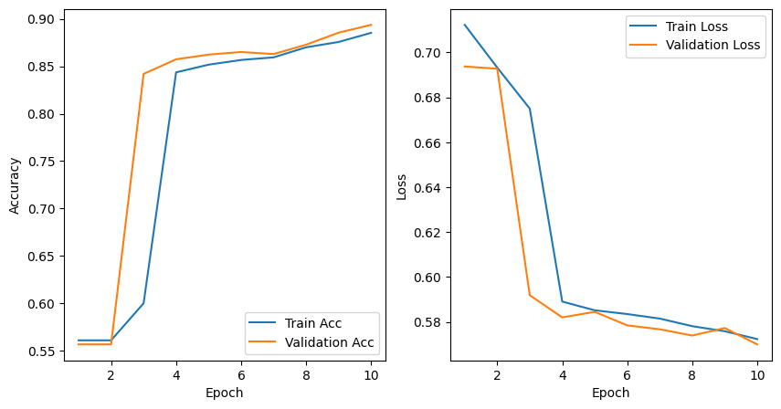

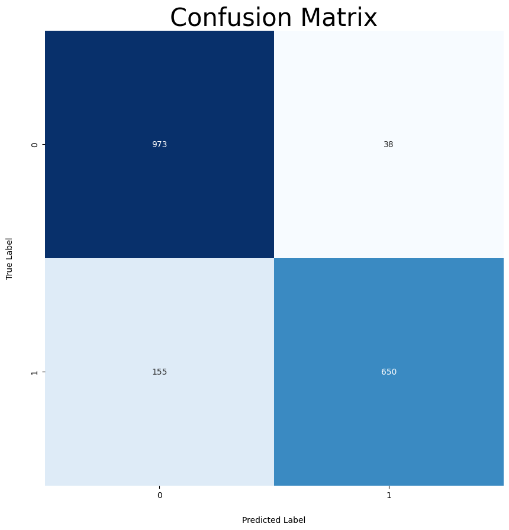

```
Recall:    0.885
F1:        0.890
Precision: 0.904
              precision    recall  f1-score   support

           0       0.86      0.96      0.91      1011
           1       0.94      0.81      0.87       805

    accuracy                           0.89      1816
   macro avg       0.90      0.88      0.89      1816
weighted avg       0.90      0.89      0.89      1816
```

```python
import torch
import torch.nn as nn
import torch.optim as optim
import torch.nn.functional as F

model = CNN()
batch_size = 16

loss_function = nn.BCEWithLogitsLoss()
optimizer = torch.optim.SGD(model.parameters(), lr=0.01, momentum=0.9, nesterov=True)

epochs = 10
device = 'auto'

cnn_model_train_history = train_model(
    model=model,
    batch_size=batch_size,
    loss_function=loss_function,
    optimizer=optimizer,
    epochs=epochs,
    train_set=train_dataset,
    valid_set=valid_dataset,
    device=device
)

trend_plot_helper(
    {
        "Accuracy - Epoch": [
            ("Train Acc", cnn_model_train_history["train_acc"]),
            ("Validation Acc", cnn_model_train_history["valid_acc"]),
        ],
        "Loss - Epoch": [
            ("Train Loss", cnn_model_train_history["train_loss"]),
            ("Validation Loss", cnn_model_train_history["valid_loss"])
        ]
    }
)

cnn_model_report = generate_confusion_matrix(
    model=model,
    dataset=valid_dataset,
)

print(f"Recall:    {cnn_model_report['recall']:.3f}")
print(f"F1:        {cnn_model_report['f1']:.3f}")
print(f"Precision: {cnn_model_report['precision']:.3f}")
print(cnn_model_report['report'])
```

```
Epoch [1/20] Train Loss: 0.7097, Train Acc: 0.5599, Valid Loss: 0.6932, Valid Acc: 0.5567
```

```
Epoch [2/20] Train Loss: 0.6666, Train Acc: 0.6292, Valid Loss: 0.5875, Valid Acc: 0.8541
```

```
Epoch [3/20] Train Loss: 0.5885, Train Acc: 0.8439, Valid Loss: 0.5813, Valid Acc: 0.8568
```

```
Epoch [4/20] Train Loss: 0.5852, Train Acc: 0.8522, Valid Loss: 0.5798, Valid Acc: 0.8612
```

```
Epoch [5/20] Train Loss: 0.5837, Train Acc: 0.8552, Valid Loss: 0.5784, Valid Acc: 0.8634
```

```
Epoch [6/20] Train Loss: 0.5810, Train Acc: 0.8627, Valid Loss: 0.5761, Valid Acc: 0.8711
```

```
Epoch [7/20] Train Loss: 0.5784, Train Acc: 0.8699, Valid Loss: 0.5737, Valid Acc: 0.8822
```

```
Epoch [8/20] Train Loss: 0.5754, Train Acc: 0.8773, Valid Loss: 0.5734, Valid Acc: 0.8722
```

```
Epoch [9/20] Train Loss: 0.5726, Train Acc: 0.8847, Valid Loss: 0.5688, Valid Acc: 0.8899
```

```
Epoch [10/20] Train Loss: 0.5698, Train Acc: 0.8930, Valid Loss: 0.5657, Valid Acc: 0.8965
```

```
Epoch [11/20] Train Loss: 0.5680, Train Acc: 0.8967, Valid Loss: 0.5646, Valid Acc: 0.9014
```

```
Epoch [12/20] Train Loss: 0.5656, Train Acc: 0.9025, Valid Loss: 0.5655, Valid Acc: 0.9025
```

```
Epoch [13/20] Train Loss: 0.5637, Train Acc: 0.9081, Valid Loss: 0.5666, Valid Acc: 0.8915
```

```
Epoch [14/20] Train Loss: 0.5619, Train Acc: 0.9112, Valid Loss: 0.5643, Valid Acc: 0.8976
```

```
Epoch [15/20] Train Loss: 0.5609, Train Acc: 0.9149, Valid Loss: 0.5628, Valid Acc: 0.9042
```

```
Epoch [16/20] Train Loss: 0.5597, Train Acc: 0.9162, Valid Loss: 0.5663, Valid Acc: 0.8910
```

```
Epoch [17/20] Train Loss: 0.5587, Train Acc: 0.9191, Valid Loss: 0.5644, Valid Acc: 0.9053
```

```
Epoch [18/20] Train Loss: 0.5572, Train Acc: 0.9220, Valid Loss: 0.5660, Valid Acc: 0.9058
```

```
Epoch [19/20] Train Loss: 0.5558, Train Acc: 0.9264, Valid Loss: 0.5640, Valid Acc: 0.9069
```

```
Epoch [20/20] Train Loss: 0.5552, Train Acc: 0.9279, Valid Loss: 0.5657, Valid Acc: 0.9036
```

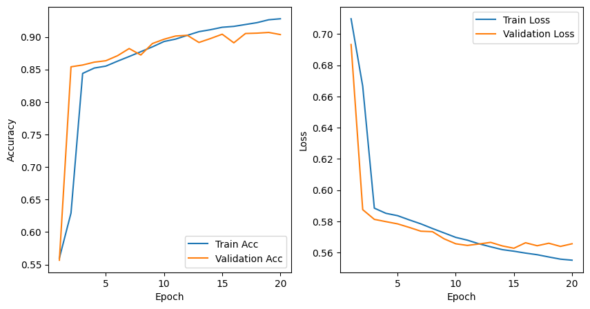

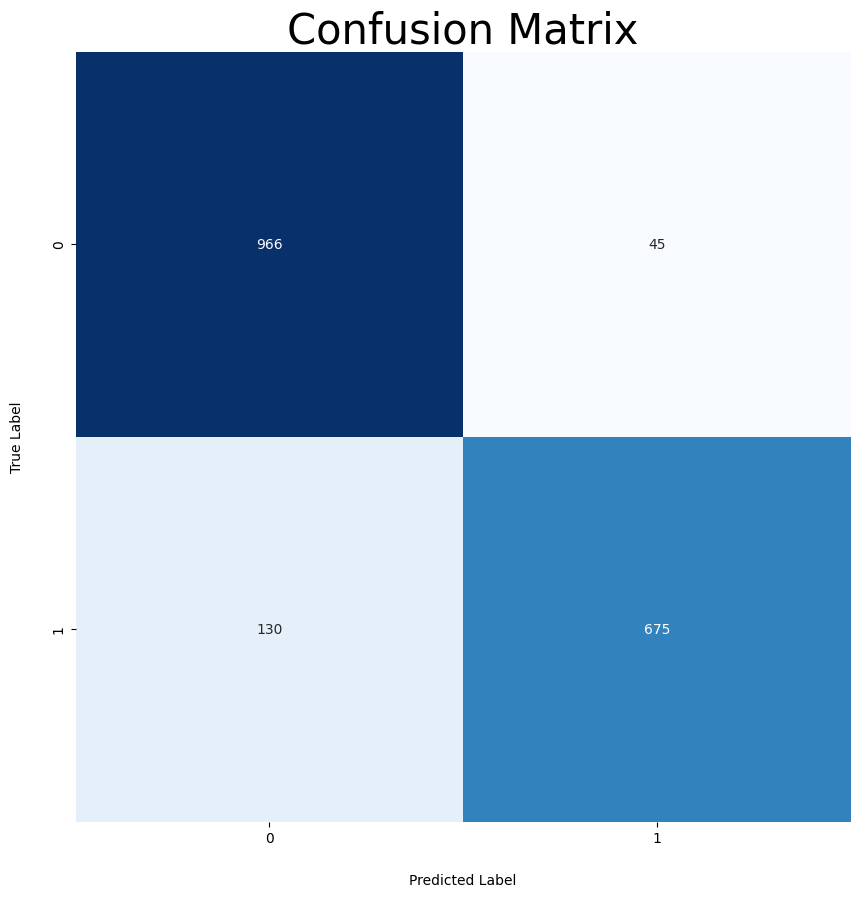

```
Recall:    0.897
F1:        0.901
Precision: 0.909
              precision    recall  f1-score   support

           0       0.88      0.96      0.92      1011
           1       0.94      0.84      0.89       805

    accuracy                           0.90      1816
   macro avg       0.91      0.90      0.90      1816
weighted avg       0.91      0.90      0.90      1816
```

```python
import torch
import torch.nn as nn
import torch.optim as optim
import torch.nn.functional as F

model = CNN()
batch_size = 16

loss_function = nn.BCEWithLogitsLoss()
optimizer = torch.optim.SGD(model.parameters(), lr=0.01, momentum=0.9, nesterov=True)

epochs = 20
device = 'auto'

cnn_model_train_history = train_model(
    model=model,
    batch_size=batch_size,
    loss_function=loss_function,
    optimizer=optimizer,
    epochs=epochs,
    train_set=train_dataset,
    valid_set=valid_dataset,
    device=device
)

trend_plot_helper(
    {
        "Accuracy - Epoch": [
            ("Train Acc", cnn_model_train_history["train_acc"]),
            ("Validation Acc", cnn_model_train_history["valid_acc"]),
        ],
        "Loss - Epoch": [
            ("Train Loss", cnn_model_train_history["train_loss"]),
            ("Validation Loss", cnn_model_train_history["valid_loss"])
        ]
    }
)

cnn_model_report = generate_confusion_matrix(
    model=model,
    dataset=valid_dataset,
)

print(f"Recall:    {cnn_model_report['recall']:.3f}")
print(f"F1:        {cnn_model_report['f1']:.3f}")
print(f"Precision: {cnn_model_report['precision']:.3f}")
print(cnn_model_report['report'])
```

```
  return F.conv1d(input, weight, bias, self.stride,
```

```
Epoch [1/20] Train Loss: 0.6014, Train Acc: 0.8183, Valid Loss: 0.5847, Valid Acc: 0.8590
```

```
Epoch [2/20] Train Loss: 0.5900, Train Acc: 0.8425, Valid Loss: 0.5858, Valid Acc: 0.8607
```

```
Epoch [3/20] Train Loss: 0.5888, Train Acc: 0.8475, Valid Loss: 0.5859, Valid Acc: 0.8403
```

```
Epoch [4/20] Train Loss: 0.5861, Train Acc: 0.8442, Valid Loss: 0.5813, Valid Acc: 0.8563
```

```
Epoch [5/20] Train Loss: 0.5847, Train Acc: 0.8493, Valid Loss: 0.5814, Valid Acc: 0.8552
```

```
Epoch [6/20] Train Loss: 0.5868, Train Acc: 0.8476, Valid Loss: 0.5798, Valid Acc: 0.8618
```

```
Epoch [7/20] Train Loss: 0.5853, Train Acc: 0.8568, Valid Loss: 0.5838, Valid Acc: 0.8706
```

```
Epoch [8/20] Train Loss: 0.5855, Train Acc: 0.8530, Valid Loss: 0.5810, Valid Acc: 0.8590
```

```
Epoch [9/20] Train Loss: 0.5836, Train Acc: 0.8552, Valid Loss: 0.5835, Valid Acc: 0.8579
```

```
Epoch [10/20] Train Loss: 0.5839, Train Acc: 0.8539, Valid Loss: 0.5807, Valid Acc: 0.8579
```

```
Epoch [11/20] Train Loss: 0.5838, Train Acc: 0.8526, Valid Loss: 0.5813, Valid Acc: 0.8607
```

```
Epoch [12/20] Train Loss: 0.5828, Train Acc: 0.8579, Valid Loss: 0.5820, Valid Acc: 0.8546
```

```
Epoch [13/20] Train Loss: 0.5822, Train Acc: 0.8577, Valid Loss: 0.5811, Valid Acc: 0.8585
```

```
Epoch [14/20] Train Loss: 0.5834, Train Acc: 0.8519, Valid Loss: 0.5821, Valid Acc: 0.8607
```

```
Epoch [15/20] Train Loss: 0.5830, Train Acc: 0.8623, Valid Loss: 0.5796, Valid Acc: 0.8662
```

```
Epoch [16/20] Train Loss: 0.5829, Train Acc: 0.8577, Valid Loss: 0.5794, Valid Acc: 0.8733
```

```
Epoch [17/20] Train Loss: 0.5826, Train Acc: 0.8592, Valid Loss: 0.5797, Valid Acc: 0.8612
```

```
Epoch [18/20] Train Loss: 0.5845, Train Acc: 0.8512, Valid Loss: 0.5812, Valid Acc: 0.8552
```

```
Epoch [19/20] Train Loss: 0.5811, Train Acc: 0.8586, Valid Loss: 0.5781, Valid Acc: 0.8689
```

```
Epoch [20/20] Train Loss: 0.5809, Train Acc: 0.8645, Valid Loss: 0.5776, Valid Acc: 0.8695
```

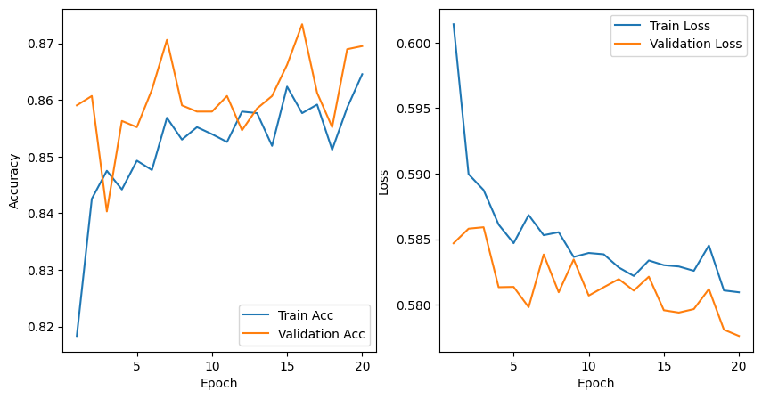

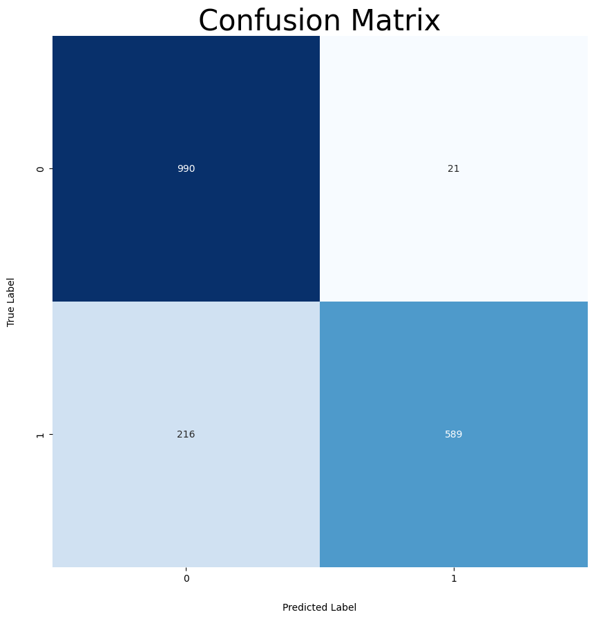

```
Recall:    0.855
F1:        0.863
Precision: 0.893
              precision    recall  f1-score   support

           0       0.82      0.98      0.89      1011
           1       0.97      0.73      0.83       805

    accuracy                           0.87      1816
   macro avg       0.89      0.86      0.86      1816
weighted avg       0.89      0.87      0.87      1816
```

```python
import torch
import torch.nn as nn
import torch.optim as optim
import torch.nn.functional as F

model = CNN()

batch_size = 60
loss_function = nn.BCEWithLogitsLoss()
optimizer = torch.optim.Adam(model.parameters(), lr=0.001)
epochs = 20
device = 'auto'

cnn_model_train_history = train_model(
    model=model,
    batch_size=batch_size,
    loss_function=loss_function,
    optimizer=optimizer,
    epochs=epochs,
    train_set=train_dataset,
    valid_set=valid_dataset,
    device=device
)

trend_plot_helper(
    {
        "Accuracy - Epoch": [
            ("Train Acc", cnn_model_train_history["train_acc"]),
            ("Validation Acc", cnn_model_train_history["valid_acc"]),
        ],
        "Loss - Epoch": [
            ("Train Loss", cnn_model_train_history["train_loss"]),
            ("Validation Loss", cnn_model_train_history["valid_loss"])
        ]
    }
)

cnn_model_report = generate_confusion_matrix(
    model=model,
    dataset=valid_dataset,
)


print(f"Recall:    {cnn_model_report['recall']:.3f}")
print(f"F1:        {cnn_model_report['f1']:.3f}")
print(f"Precision: {cnn_model_report['precision']:.3f}")
print(cnn_model_report['report'])
```

```
Epoch [1/10] Train Loss: 0.6162, Train Acc: 0.8080, Valid Loss: 0.6013, Valid Acc: 0.8001
```

```
Epoch [2/10] Train Loss: 0.6060, Train Acc: 0.7896, Valid Loss: 0.6038, Valid Acc: 0.7935
```

```
Epoch [3/10] Train Loss: 0.6076, Train Acc: 0.8066, Valid Loss: 0.5970, Valid Acc: 0.8480
```

```
Epoch [4/10] Train Loss: 0.6049, Train Acc: 0.8330, Valid Loss: 0.5970, Valid Acc: 0.8475
```

```
Epoch [5/10] Train Loss: 0.6058, Train Acc: 0.8318, Valid Loss: 0.6460, Valid Acc: 0.7808
```

```
Epoch [6/10] Train Loss: 0.6090, Train Acc: 0.7998, Valid Loss: 0.6034, Valid Acc: 0.8034
```

```
Epoch [7/10] Train Loss: 0.6027, Train Acc: 0.8025, Valid Loss: 0.6023, Valid Acc: 0.8062
```

```
Epoch [8/10] Train Loss: 0.6029, Train Acc: 0.8040, Valid Loss: 0.6023, Valid Acc: 0.8062
```

```
Epoch [9/10] Train Loss: 0.6024, Train Acc: 0.8040, Valid Loss: 0.6023, Valid Acc: 0.8062
```

```
Epoch [10/10] Train Loss: 0.6026, Train Acc: 0.8040, Valid Loss: 0.6023, Valid Acc: 0.8062
```

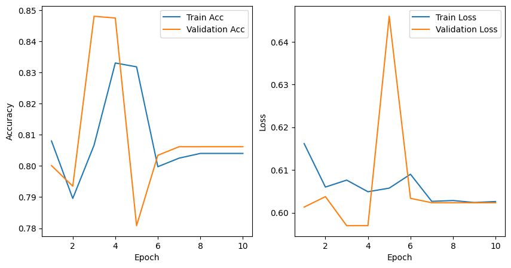

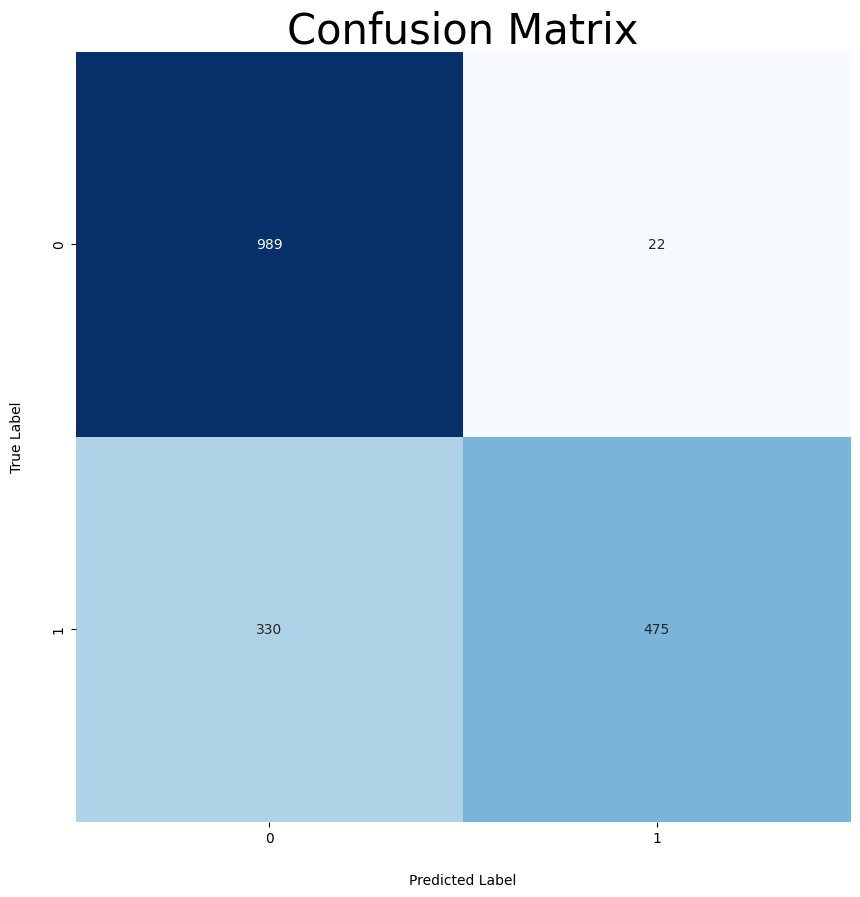

```
Recall:    0.784
F1:        0.789
Precision: 0.853
              precision    recall  f1-score   support

           0       0.75      0.98      0.85      1011
           1       0.96      0.59      0.73       805

    accuracy                           0.81      1816
   macro avg       0.85      0.78      0.79      1816
weighted avg       0.84      0.81      0.80      1816
```

```python
import torch
import torch.nn as nn
import torch.optim as optim
import torch.nn.functional as F
model = CNN()


batch_size = 60
loss_function = nn.BCEWithLogitsLoss()
optimizer = torch.optim.Adam(model.parameters(), lr=0.01)
epochs = 10
device = 'auto'

cnn_model_train_history = train_model(
    model=model,
    batch_size=batch_size,
    loss_function=loss_function,
    optimizer=optimizer,
    epochs=epochs,
    train_set=train_dataset,
    valid_set=valid_dataset,
    device=device
)

trend_plot_helper(
    {
        "Accuracy - Epoch": [
            ("Train Acc", cnn_model_train_history["train_acc"]),
            ("Validation Acc", cnn_model_train_history["valid_acc"]),
        ],
        "Loss - Epoch": [
            ("Train Loss", cnn_model_train_history["train_loss"]),
            ("Validation Loss", cnn_model_train_history["valid_loss"])
        ]
    }
)

cnn_model_report = generate_confusion_matrix(
    model=model,
    dataset=valid_dataset,
)


print(f"Recall:    {cnn_model_report['recall']:.3f}")
print(f"F1:        {cnn_model_report['f1']:.3f}")
print(f"Precision: {cnn_model_report['precision']:.3f}")
print(cnn_model_report['report'])
```

```
Epoch [1/30] Train Loss: 0.6032, Train Acc: 0.8117, Valid Loss: 0.5814, Valid Acc: 0.8563
```

```
Epoch [2/30] Train Loss: 0.5861, Train Acc: 0.8517, Valid Loss: 0.5814, Valid Acc: 0.8541
```

```
Epoch [3/30] Train Loss: 0.5827, Train Acc: 0.8557, Valid Loss: 0.5826, Valid Acc: 0.8717
```

```
Epoch [4/30] Train Loss: 0.5795, Train Acc: 0.8671, Valid Loss: 0.5756, Valid Acc: 0.8789
```

```
Epoch [5/30] Train Loss: 0.5788, Train Acc: 0.8691, Valid Loss: 0.5736, Valid Acc: 0.8849
```

```
Epoch [6/30] Train Loss: 0.5767, Train Acc: 0.8761, Valid Loss: 0.5715, Valid Acc: 0.8849
```

```
Epoch [7/30] Train Loss: 0.5759, Train Acc: 0.8768, Valid Loss: 0.5726, Valid Acc: 0.8893
```

```
Epoch [8/30] Train Loss: 0.5731, Train Acc: 0.8835, Valid Loss: 0.5701, Valid Acc: 0.8915
```

```
Epoch [9/30] Train Loss: 0.5729, Train Acc: 0.8845, Valid Loss: 0.5700, Valid Acc: 0.8871
```

```
Epoch [10/30] Train Loss: 0.5718, Train Acc: 0.8898, Valid Loss: 0.5687, Valid Acc: 0.9014
```

```
Epoch [11/30] Train Loss: 0.5665, Train Acc: 0.9003, Valid Loss: 0.5655, Valid Acc: 0.9020
```

```
Epoch [12/30] Train Loss: 0.5671, Train Acc: 0.9007, Valid Loss: 0.5653, Valid Acc: 0.9025
```

```
Epoch [13/30] Train Loss: 0.5632, Train Acc: 0.9092, Valid Loss: 0.5667, Valid Acc: 0.8915
```

```
Epoch [14/30] Train Loss: 0.5637, Train Acc: 0.9076, Valid Loss: 0.5663, Valid Acc: 0.8948
```

```
Epoch [15/30] Train Loss: 0.5629, Train Acc: 0.9102, Valid Loss: 0.5641, Valid Acc: 0.9091
```

```
Epoch [16/30] Train Loss: 0.5606, Train Acc: 0.9142, Valid Loss: 0.5642, Valid Acc: 0.8998
```

```
Epoch [17/30] Train Loss: 0.5604, Train Acc: 0.9160, Valid Loss: 0.5714, Valid Acc: 0.8998
```

```
Epoch [18/30] Train Loss: 0.5607, Train Acc: 0.9173, Valid Loss: 0.5633, Valid Acc: 0.9119
```

```
Epoch [19/30] Train Loss: 0.5605, Train Acc: 0.9169, Valid Loss: 0.5699, Valid Acc: 0.9014
```

```
Epoch [20/30] Train Loss: 0.5565, Train Acc: 0.9223, Valid Loss: 0.5628, Valid Acc: 0.9080
```

```
Epoch [21/30] Train Loss: 0.5563, Train Acc: 0.9241, Valid Loss: 0.5661, Valid Acc: 0.9075
```

```
Epoch [22/30] Train Loss: 0.5553, Train Acc: 0.9289, Valid Loss: 0.5722, Valid Acc: 0.8998
```

```
Epoch [23/30] Train Loss: 0.5605, Train Acc: 0.9171, Valid Loss: 0.5655, Valid Acc: 0.9108
```

```
Epoch [24/30] Train Loss: 0.5571, Train Acc: 0.9213, Valid Loss: 0.5711, Valid Acc: 0.9036
```

```
Epoch [25/30] Train Loss: 0.5569, Train Acc: 0.9235, Valid Loss: 0.5682, Valid Acc: 0.9058
```

```
Epoch [26/30] Train Loss: 0.5531, Train Acc: 0.9327, Valid Loss: 0.5668, Valid Acc: 0.9047
```

```
Epoch [27/30] Train Loss: 0.5536, Train Acc: 0.9334, Valid Loss: 0.5658, Valid Acc: 0.9080
```

```
Epoch [28/30] Train Loss: 0.5521, Train Acc: 0.9370, Valid Loss: 0.5632, Valid Acc: 0.9047
```

```
Epoch [29/30] Train Loss: 0.5530, Train Acc: 0.9329, Valid Loss: 0.5633, Valid Acc: 0.9119
```

```
Epoch [30/30] Train Loss: 0.5542, Train Acc: 0.9304, Valid Loss: 0.5656, Valid Acc: 0.8992
```

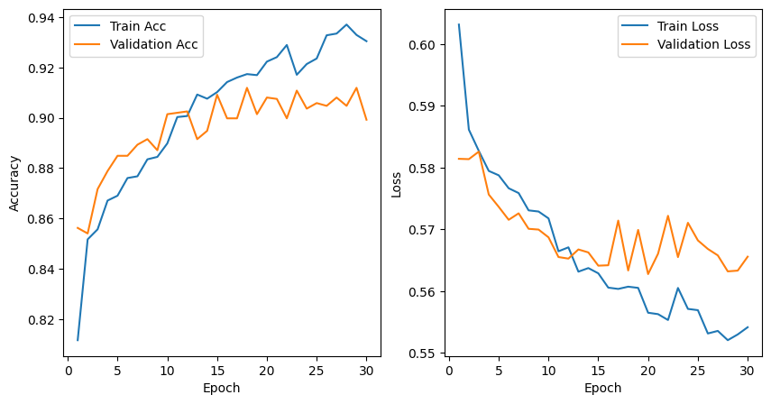

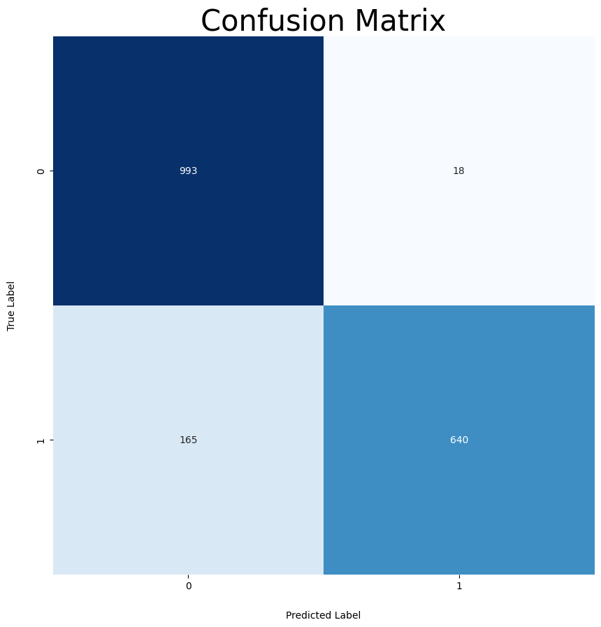

```
Recall:    0.889
F1:        0.895
Precision: 0.915
              precision    recall  f1-score   support

           0       0.86      0.98      0.92      1011
           1       0.97      0.80      0.87       805

    accuracy                           0.90      1816
   macro avg       0.92      0.89      0.90      1816
weighted avg       0.91      0.90      0.90      1816
```

```python
import torch
import torch.nn as nn
import torch.optim as optim
import torch.nn.functional as F

model = CNN()

batch_size = 60
loss_function = nn.BCEWithLogitsLoss()
optimizer = torch.optim.AdamW(model.parameters(), lr=0.001, betas=(0.9, 0.999), weight_decay=0.01)


epochs = 30
device = 'auto'

cnn_model_train_history = train_model(
    model=model,
    batch_size=batch_size,
    loss_function=loss_function,
    optimizer=optimizer,
    epochs=epochs,
    train_set=train_dataset,
    valid_set=valid_dataset,
    device=device
)

trend_plot_helper(
    {
        "Accuracy - Epoch": [
            ("Train Acc", cnn_model_train_history["train_acc"]),
            ("Validation Acc", cnn_model_train_history["valid_acc"]),
        ],
        "Loss - Epoch": [
            ("Train Loss", cnn_model_train_history["train_loss"]),
            ("Validation Loss", cnn_model_train_history["valid_loss"])
        ]
    }
)

cnn_model_report = generate_confusion_matrix(
    model=model,
    dataset=valid_dataset,
)


print(f"Recall:    {cnn_model_report['recall']:.3f}")
print(f"F1:        {cnn_model_report['f1']:.3f}")
print(f"Precision: {cnn_model_report['precision']:.3f}")
print(cnn_model_report['report'])
```

```
Epoch [1/30] Train Loss: 0.7089, Train Acc: 0.5610, Valid Loss: 0.6933, Valid Acc: 0.5567
```

```
Epoch [2/30] Train Loss: 0.6912, Train Acc: 0.5610, Valid Loss: 0.6782, Valid Acc: 0.5567
```

```
Epoch [3/30] Train Loss: 0.6072, Train Acc: 0.7908, Valid Loss: 0.5826, Valid Acc: 0.8524
```

```
Epoch [4/30] Train Loss: 0.5859, Train Acc: 0.8489, Valid Loss: 0.5822, Valid Acc: 0.8629
```

```
Epoch [5/30] Train Loss: 0.5839, Train Acc: 0.8556, Valid Loss: 0.5796, Valid Acc: 0.8656
```

```
Epoch [6/30] Train Loss: 0.5819, Train Acc: 0.8618, Valid Loss: 0.5767, Valid Acc: 0.8695
```

```
Epoch [7/30] Train Loss: 0.5788, Train Acc: 0.8687, Valid Loss: 0.5748, Valid Acc: 0.8689
```

```
Epoch [8/30] Train Loss: 0.5759, Train Acc: 0.8755, Valid Loss: 0.5716, Valid Acc: 0.8783
```

```
Epoch [9/30] Train Loss: 0.5727, Train Acc: 0.8836, Valid Loss: 0.5687, Valid Acc: 0.8943
```

```
Epoch [10/30] Train Loss: 0.5702, Train Acc: 0.8904, Valid Loss: 0.5696, Valid Acc: 0.8965
```

```
Epoch [11/30] Train Loss: 0.5686, Train Acc: 0.8962, Valid Loss: 0.5698, Valid Acc: 0.8981
```

```
Epoch [12/30] Train Loss: 0.5657, Train Acc: 0.9014, Valid Loss: 0.5644, Valid Acc: 0.9025
```

```
Epoch [13/30] Train Loss: 0.5638, Train Acc: 0.9072, Valid Loss: 0.5663, Valid Acc: 0.9031
```

```
Epoch [14/30] Train Loss: 0.5622, Train Acc: 0.9109, Valid Loss: 0.5643, Valid Acc: 0.9064
```

```
Epoch [15/30] Train Loss: 0.5608, Train Acc: 0.9154, Valid Loss: 0.5620, Valid Acc: 0.9080
```

```
Epoch [16/30] Train Loss: 0.5595, Train Acc: 0.9173, Valid Loss: 0.5626, Valid Acc: 0.9108
```

```
Epoch [17/30] Train Loss: 0.5585, Train Acc: 0.9198, Valid Loss: 0.5649, Valid Acc: 0.8954
```

```
Epoch [18/30] Train Loss: 0.5585, Train Acc: 0.9194, Valid Loss: 0.5624, Valid Acc: 0.9020
```

```
Epoch [19/30] Train Loss: 0.5557, Train Acc: 0.9270, Valid Loss: 0.5620, Valid Acc: 0.9069
```

```
Epoch [20/30] Train Loss: 0.5550, Train Acc: 0.9279, Valid Loss: 0.5615, Valid Acc: 0.9097
```

```
Epoch [21/30] Train Loss: 0.5545, Train Acc: 0.9303, Valid Loss: 0.5661, Valid Acc: 0.9058
```

```
Epoch [22/30] Train Loss: 0.5528, Train Acc: 0.9336, Valid Loss: 0.5657, Valid Acc: 0.9064
```

```
Epoch [23/30] Train Loss: 0.5527, Train Acc: 0.9343, Valid Loss: 0.5626, Valid Acc: 0.9102
```

```
Epoch [24/30] Train Loss: 0.5511, Train Acc: 0.9391, Valid Loss: 0.5662, Valid Acc: 0.9053
```

```
Epoch [25/30] Train Loss: 0.5511, Train Acc: 0.9381, Valid Loss: 0.5637, Valid Acc: 0.9069
```

```
Epoch [26/30] Train Loss: 0.5502, Train Acc: 0.9403, Valid Loss: 0.5638, Valid Acc: 0.9080
```

```
Epoch [27/30] Train Loss: 0.5502, Train Acc: 0.9402, Valid Loss: 0.5663, Valid Acc: 0.9069
```

```
Epoch [28/30] Train Loss: 0.5494, Train Acc: 0.9426, Valid Loss: 0.5631, Valid Acc: 0.9091
```

```
Epoch [29/30] Train Loss: 0.5479, Train Acc: 0.9464, Valid Loss: 0.5656, Valid Acc: 0.9069
```

```
Epoch [30/30] Train Loss: 0.5476, Train Acc: 0.9465, Valid Loss: 0.5732, Valid Acc: 0.8981
```

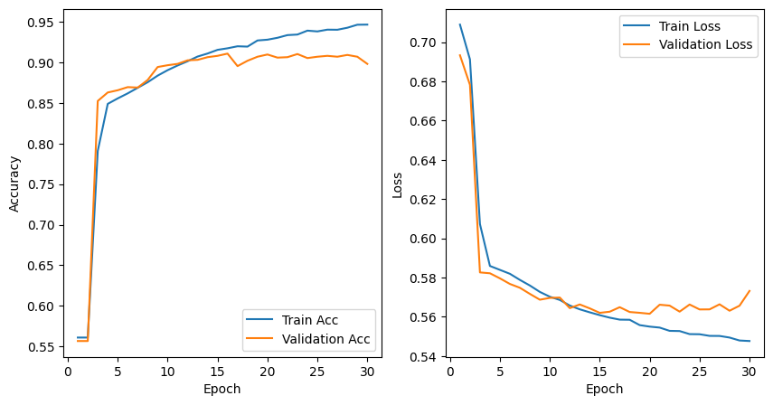

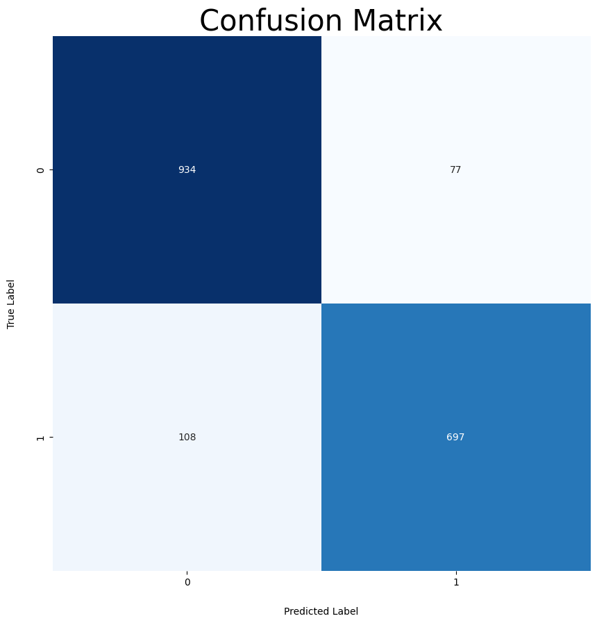

```
Recall:    0.895
F1:        0.896
Precision: 0.898
              precision    recall  f1-score   support

           0       0.90      0.92      0.91      1011
           1       0.90      0.87      0.88       805

    accuracy                           0.90      1816
   macro avg       0.90      0.89      0.90      1816
weighted avg       0.90      0.90      0.90      1816
```

```python
import torch
import torch.nn as nn
import torch.optim as optim
import torch.nn.functional as F

model = CNN()

batch_size = 16

loss_function = nn.BCEWithLogitsLoss()
optimizer = torch.optim.SGD(model.parameters(), lr=0.01, momentum=0.9, nesterov=True)

epochs = 30
device = 'auto'

cnn_model_train_history = train_model(
    model=model,
    batch_size=batch_size,
    loss_function=loss_function,
    optimizer=optimizer,
    epochs=epochs,
    train_set=train_dataset,
    valid_set=valid_dataset,
    device=device
)

trend_plot_helper(
    {
        "Accuracy - Epoch": [
            ("Train Acc", cnn_model_train_history["train_acc"]),
            ("Validation Acc", cnn_model_train_history["valid_acc"]),
        ],
        "Loss - Epoch": [
            ("Train Loss", cnn_model_train_history["train_loss"]),
            ("Validation Loss", cnn_model_train_history["valid_loss"])
        ]
    }
)

cnn_model_report = generate_confusion_matrix(
    model=model,
    dataset=valid_dataset,
)

print(f"Recall:    {cnn_model_report['recall']:.3f}")
print(f"F1:        {cnn_model_report['f1']:.3f}")
print(f"Precision: {cnn_model_report['precision']:.3f}")
print(cnn_model_report['report'])
```

## Batch Normalization:

**Batch Normalization** is a technique to improve the training of deep neural networks by addressing the issue of internal covariate shift. It was introduced by Sergey Ioffe and Christian Szegedy in a 2015 paper titled "Batch Normalization: Accelerating Deep Network Training by Reducing Internal Covariate Shift."

#### Key Concepts

1. **Internal Covariate Shift**:
   - Refers to the change in the distribution of network activations due to the updating of parameters during training.
   - This shift can slow down training because each layer has to continuously adapt to the new distribution of inputs it receives.
2. **Normalization**:
   - Batch normalization normalizes the output of a previous activation layer by subtracting the batch mean and dividing by the batch standard deviation.
   - It then scales and shifts the normalized value using learnable parameters.

#### How Batch Normalization Works

1. **Calculate Mean and Variance**:
   - For a given mini-batch, compute the mean mu and variance sigma^2 of the activations.
2. **Normalize**:
   - Normalize the activations using the computed mean and variance. $$ \hat{x} = \frac{x - \mu}{\sqrt{\sigma^2 + \epsilon}} $$ Where (\epsilon) is a small constant to prevent division by zero.
3. **Scale and Shift**:
   - Introduce two learnable parameters, gamma scale and beta shift , which allow the network to learn the optimal scale and shift for the normalized activations. $$ y = \gamma \hat{x} + \beta $$
4. **Integration into Training**:
   - During training, batch normalization uses the statistics of the current mini-batch.
   - During inference, it uses the running averages of these statistics computed during training.

#### Benefits of Batch Normalization

1. **Improved Training Speed**:
   - Reduces internal covariate shift, allowing the network to converge faster.
2. **Higher Learning Rates**:
   - Enables the use of higher learning rates by stabilizing the learning process.
3. **Regularization Effect**:
   - Adds a slight regularization effect, reducing the need for other forms of regularization like dropout.
4. **Stabilizes Training**:
   - Helps in making the training process more stable by reducing sensitivity to initialization.

### Dropout: An Overview

**Dropout** is a regularization technique used to prevent overfitting in neural networks. It was introduced by Geoffrey Hinton and his colleagues in a 2014 paper titled "Dropout: A Simple Way to Prevent Neural Networks from Overfitting."

#### Key Concepts

1. **Overfitting**:
   - Overfitting occurs when a model learns to perform very well on the training data but fails to generalize to new, unseen data. This happens when the model learns the noise and details in the training data to the extent that it negatively impacts the model's performance on new data.
2. **Dropout Technique**:
   - During training, dropout randomly sets a fraction of the activations (outputs of neurons) to zero at each update step. This fraction is controlled by a hyperparameter called the dropout rate, typically between 0.2 and 0.5.
   - By "dropping out" units, dropout prevents the model from relying too heavily on any individual neuron, forcing it to learn more robust features that are useful in conjunction with many different random subsets of the neurons.
3. **Implementation**:
   - Dropout is only applied during the training phase. During testing or inference, all units are active, and their outputs are scaled down by the dropout rate to maintain consistency in the output magnitudes.
4. **Dropout Rate**:
   - This is the probability of setting any given unit's output to zero. For example, a dropout rate of 0.5 means each neuron has a 50% chance of being dropped out during training.

#### Benefits of Dropout

1. **Reduces Overfitting**:
   - By preventing any single neuron from becoming too important, dropout forces the network to learn more distributed representations, reducing overfitting.
2. **Encourages Redundancy**:
   - Encourages the network to learn redundant representations of features, making the network more robust to the loss of any particular neuron.
3. **Improves Generalization**:
   - Leads to better generalization on unseen data, as the model learns to rely on multiple features and their interactions rather than specific details.

#### How Dropout Works

1. **Training Phase**:
   - Randomly set a fraction of the neurons' outputs to zero. This fraction is controlled by the dropout rate.
   - The outputs of the remaining neurons are scaled up by a factor of (1 / (1 - \text{dropout rate})) to maintain the same expected sum of inputs to the next layer.
2. **Inference Phase**:
   - No dropout is applied. The outputs are not randomly set to zero, but they are scaled by the dropout rate used during training to ensure consistency in the expected values of the activations.